# The Origins of Inequality, Revisited

Step two: long time. The step above covers only the population limit at fixed rounds; it does not automatically say what happens when the number of rounds also goes to infinity—that is another theorem, to be attached separately. The way to attach it is to compute the whole tree’s weight at once: for every path from the root to generation $t$, multiply the coefficients along the path (a path is a chain of products), then add up the results over all paths. In symbols, $v$ is a vertex, $|v|$ is the generation it lies in, and $e\in v$ are the edges from the root to it:

$$W_t=\sum_{|v|=t}\prod_{e\in v}A_e,
\qquad\mathcal L(X_t)=\mathcal L(W_t).$$
The equality on the right says only that the two have the same distribution at each fixed time; it does not say they are the same stochastic process.

$W_t$ is a martingale on the branching tree: the expected sum of the weights of a vertex’s two children is exactly $m(1)=1$ times the weight, so one more generation leaves the expected total weight unchanged—“the expectation of the next step given the present equals the present,” which is what a martingale is. But be careful: it is the total weight of the whole tree, not the wealth trajectory of some islander, and the two are easily confused. The weights are nonnegative and the branching number is always two; the uniform and lognormal factors make every positive moment finite, in particular $E[W_1\log^+W_1]<\infty$ and $E\sum_i A_i|\log A_i|<\infty$. The model is nondegenerate, with no extinction event. The Kahane–Peyrière / Biggins martingale convergence criterion therefore looks only at the sign of one number—$m'(1)=(\sigma^2-1)/2$, which changes sign at $\sigma=1$ (Kahane and Peyrière 1976; Biggins 1977). The criterion does not ask whether the martingale converges—it converges on both sides—but whether the limit carries the mean with it. This is where a condition called **uniform integrability** comes in; it governs exactly this. The mean of $W_t$ is always one, but that one may be held up by a very few very large values. Uniform integrability requires that there be one sufficiently high threshold such that the contribution to the mean from beyond it is equally small at every number of rounds—“uniform” means this threshold does not retreat as the rounds increase. If the threshold holds, taking the limit and taking the mean can be exchanged; if it does not, they cannot.

- $\sigma<1$: the martingale is uniformly integrable and converges to a nonzero fixed point with mean one.
- $\sigma\ge1$: $W_t\to0$ almost surely, yet the mean at every generation is still one—what is lost is precisely uniform integrability. The second line looks self-contradictory: how can a quantity that tends to zero almost surely have a mean that stays at one? The answer is clear now: as the rounds increase, the mean relies more and more on ever rarer and ever larger values, the threshold keeps being pushed up, and so the typical individual goes to zero while the mean does not budge. What $\sigma\ge1$ loses is therefore not whether there is a fixed point but whether the limit can be moved inside the expectation.

This is the phase transition of this model in its own coordinates: on the two sides of the critical point, $W_t$ goes to two places of entirely different character.

The last step: the tail. The criterion above concerns whether the martingale converges; it does not yet say what the fixed point’s tail looks like—the martingale limit and the classification of fixed points are related but distinct questions. For the classification of smoothing transforms see Durrett–Liggett; for generalized transforms and the connection to branching random walks see Liu (Durrett and Liggett 1983; Liu 1998). This chapter uses theorems case by case for the tail asymptotics, as in the table below.

| Interval | Nonzero fixed point | Basis |
| --- | --- | --- |
| 0 < σ < 1 | mean 1; P(X > x) ∼ C x^(−α₂) | Iksanov Proposition 7 |
| σ = 1 | mean infinite; P(X > x) ∼ C/x | Buraczewski (tail); existence not supplied |
| σ > 1 | positive stable mixture; mean infinite; tail exponent α₂ < 1 | Iksanov Theorem 2 + Proposition 3 |

For $0<\sigma<1$, $m(1)=m(\alpha_2)=1$, $\alpha_2>1$, and $m'(\alpha_2)>0$; the positive and logarithmic moments of the coefficients are finite, and $\log A_i$ is non-lattice. Iksanov’s Proposition 7 gives $P(X>x)\sim Cx^{-\alpha_2}$ with $C>0$ (Iksanov 2004). The variance boundary above is therefore a corollary of the tail-asymptotics theorem, not an extrapolation from a fitted slope. At $\sigma=1$, $m(1)=1$ and $m'(1)=0$, which falls exactly in the boundary case that Buraczewski treats separately, giving a $C/x$ tail for the nonzero solution and an infinite mean (Buraczewski 2009). This is the one citation in the chapter that is not fully supplied. Buraczewski’s tail theorem assumes a nonzero solution already exists; it is not itself an existence theorem. And the $\alpha=1$ case of Iksanov’s Theorem 2 gives the elementary fixed point with finite mean, and requires the size-biased logarithmic drift to be strictly negative—at $\sigma=1$ that drift is exactly zero ($m'(1)=0$), so it cannot supply the existence of the infinite-mean critical solution here. Existence in the boundary case belongs to results from the derivative-martingale line, which this essay has not checked one by one; the cell is therefore recorded as “not supplied,” not treated as proved. (That $W_\infty=0$ for $\sigma\ge1$ is a separate conclusion and is unaffected.) At $\sigma>1$ the root falls in $(0,1)$; the fixed point is given by Iksanov’s Theorem 2 and Proposition 3, and is unique up to a constant multiple (Iksanov 2004). Its construction is “random scale × stable law”: a stable law is a distribution such that the sum of several independent copies, suitably rescaled, has the same shape as before (the “stable” here is unrelated to the “steady state” mentioned earlier—it is a different word); and the scale itself is still random, hence a stable mixture.

The conditions to check in each of the three intervals.

- $0<\sigma<1$: $m(1)=m(\alpha_2)=1$, $\alpha_2>1$, $m'(\alpha_2)>0$; the positive and logarithmic moments of the coefficients are finite, and $\log A_i$ is non-lattice (that is, not concentrated on an arithmetic lattice).
- $\sigma=1$: $m(1)=1$ and $m'(1)=0$, falling in Buraczewski’s boundary case, with a $C/x$ tail. But the existence cell is empty: the $\alpha=1$ case of Iksanov’s Theorem 2 gives the elementary fixed point with finite mean and requires the size-biased logarithmic drift to be strictly negative, whereas here it is exactly zero, so that theorem does not apply; and Buraczewski’s theorem assumes a nonzero solution already exists. This essay does not claim that this cell is proved.
- $\sigma>1$: the smallest root is $\beta_1=\alpha_2\in(0,1)$, with $m'(\beta_1)<0$, and the corresponding integrability conditions hold as well; the finite-mean fixed point obtained by replacing the coefficients with $A_i^{\alpha_2}$ serves as the mixing scale, and combining it with an independent positive $\alpha_2$-stable variable gives the infinite-mean fixed point of the original transform and its tail exponent.

The nonzero fixed points in the latter two intervals are not the limit of the kinetic iteration started from equality. The latter **converges weakly** to $\delta_0$—$\delta_0$ is the distribution with all its probability mass at zero, and “converges weakly to it” means that for a randomly chosen person, the probability that their wealth lies in any small neighborhood of zero tends to one. This is exactly the typical individual going to zero mentioned earlier. $\delta_0$ certainly has no power-law tail. The $\alpha_2$ on the figure describes the nonzero fixed point.

## 5.4 The Second: Individual Sinking

This transition says that the mean does not move while the wealth distribution as a whole collapses toward zero. In this model it needs no separate machine—it is simply the moment the order parameter falls to zero.

When $\sigma\ge1$, take the population limit first: the normalized wealth of a randomly drawn person tends to zero in probability, while the mean of every generation is still 1.

**Detail: how far “tends to zero in probability” actually goes (skippable)**

(Note: this chapter proves that the total weight on the tree $W_t\to0$ almost surely, together with $\mathcal L(X_t)=\mathcal L(W_t)$ at each time—that is not enough to assert that a fixed individual’s wealth path tends to zero almost surely; that needs a dependence structure over time, which this chapter does not prove. It fails even more clearly at finite population: with $N=2$ the tagged wealth is always $\mathrm{Unif}(0,2)$.) The two statements do not conflict: the mean is held up by an ever rarer, ever larger few. What is lost is not “whether an equilibrium exists” but “whether the limit can be moved inside the expectation”—that is, uniform integrability.

The mean boundary of the first transition, the distributional drift to zero of the second, and the weak condensation of the third all sit at $\sigma=1$ in this model—they are triggered by the same condition ($m'(1)=0$) but speak about different objects and proceed by different arguments: one about the moments of the fixed point, one about the distribution of a tagged individual, one about a population fraction. Coincident locations do not make them three ways of saying one thing.

The easiest way to see the separation clearly is to leave this chapter’s model for a moment and keep only the pure multiplicative process $w\mapsto we^{m+\sigma\varepsilon}$: no exchange, no normalization. It is not this chapter’s model, and its control parameter is not this chapter’s $\sigma$—it is just a demonstration machine that magnifies the phenomenon.

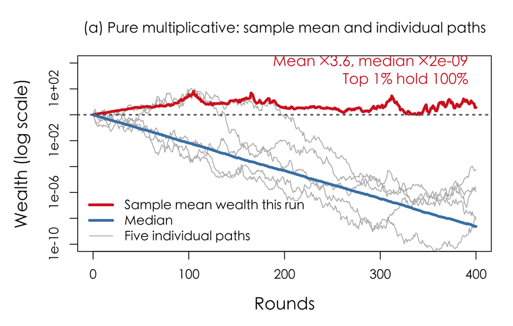

```r
ACC <- "#D62728"; GRN <- "#59A14F"
par(mar = c(4.8, 5.0, 3.6, 1.4), cex.lab = 1.32, cex.main = 1.12, family = "cjk")

## The pure multiplicative process and the discrete coin process are demonstrated separately; they do not share control parameters.
set.seed(1); Np <- 5000; TT <- 400; m <- -0.05; sg <- 0.4
w <- rep(1, Np); ens <- med <- numeric(TT + 1); ens[1] <- med[1] <- 1
trk <- matrix(NA_real_, TT + 1, 5); trk[1, ] <- 1
for (t in 1:TT){
  w <- w * exp(m + sg*rnorm(Np))
  ens[t+1] <- mean(w); med[t+1] <- median(w); trk[t+1, ] <- w[1:5]
}
plot(NA, xlim = c(0, TT), ylim = c(1e-10, 1e4), log = "y",
     xlab = "Rounds", ylab = "Wealth (log scale)",
     main = "(a) Pure multiplicative: sample mean and individual paths")
for (k in 1:5) lines(0:TT, trk[, k], col = "gray72", lwd = 1.1)
lines(0:TT, ens, col = ACC, lwd = 3.4); lines(0:TT, med, col = "steelblue", lwd = 3.4)
abline(h = 1, lty = 3, lwd = 2, col = "gray40")
legend("bottomleft", c("Sample mean wealth this run", "Median", "Five individual paths"),
       col = c(ACC, "steelblue", "gray72"), lwd = c(3.4, 3.4, 1.1), bty = "n", cex = 1.0)
text(TT, 1.2e3, sprintf("Mean ×%.1f, median ×%.0e\nTop 1%% hold %.0f%%",
     ens[TT+1], med[TT+1], 100*sum(sort(w, TRUE)[1:(Np/100)])/sum(w)),
     col = ACC, cex = 1.15, pos = 2)
```

```r
reg("erg_rounds", TT, "derived", "§5.4 erg_multiplicative", "time horizon of the independent pure-multiplicative demonstration")
reg("erg_mean", ens[TT+1], "point", "§5.4 erg_multiplicative", "sample mean wealth in the final round")
reg("erg_median", med[TT+1], "point", "§5.4 erg_multiplicative", "sample median wealth in the final round")
```

This independent demonstration ran 400 rounds; the sample mean wealth is 3.6 times its initial value, and the median 2e-09 times. A sample-period mean cannot stand in for the expectation, let alone the long-run outcome.

**Detail: how “individuals go to zero while the expectation grows” holds at once on the pure multiplicative machine (skippable)**

One more remark on this pure multiplicative machine, or it is easy to misread: when $m<0<m+\sigma^2/2$, every individual tends to zero almost surely while the expectation grows; and if any finite population is held fixed while time goes to infinity, total wealth also tends to zero almost surely—“$E[S_t]$ is rising” is a different matter. Only after the population is sent to infinity does the sample mean at each fixed time approach that growing expectation.

## 5.5 The Fourth: Not on This Axis

**Exchange freezing** means that trading itself stops: a person is too poor to put up even one coin, so even a matched pair cannot transact.

This transition does not exist in this model. Wealth here is continuous, and every pair transacts unconditionally—even if a person has only one ten-thousandth of the mean left, he still pools that ten-thousandth and gets a share back. No matter how many people are “effectively bankrupt,” no transaction fails.

It really lives on another axis: the scarcity of coins. Turn wealth into discrete coins and require the payer to hold at least one, and the transaction rate falls with the number of coins per head—but it falls continuously, with no positive coin count at which it suddenly freezes.

Switch to discrete coins and this axis can be drawn:

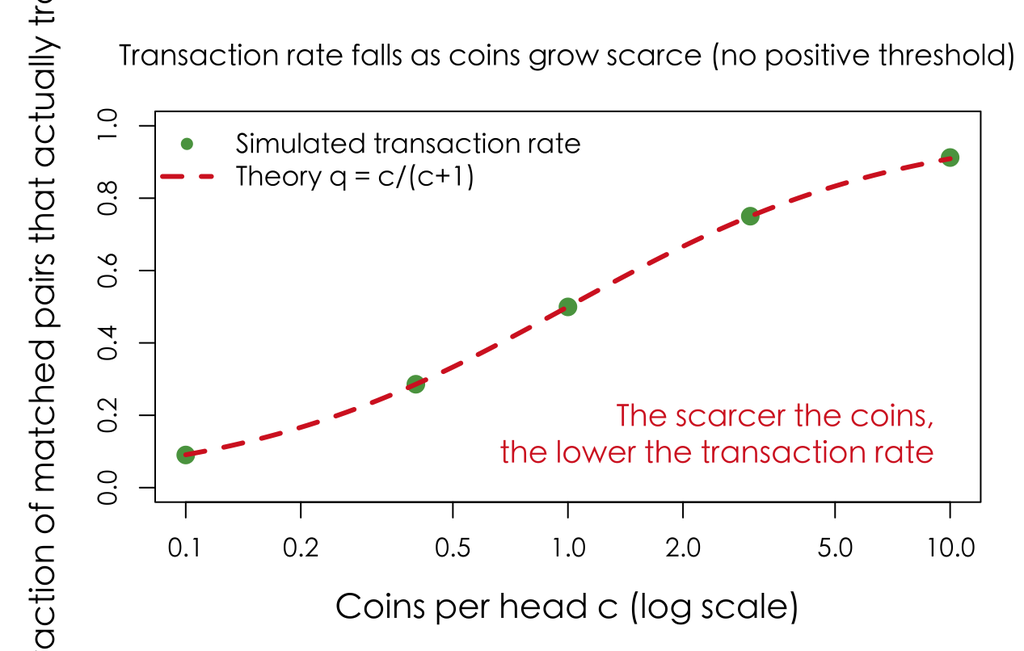

```r
ACC <- "#D62728"; GRN <- "#59A14F"
par(mar = c(4.8, 5.0, 3.6, 1.4), cex.lab = 1.32, cex.main = 1.12, family = "cjk")
cs <- c(10, 3, 1, 0.4, 0.1); rate <- numeric(length(cs))
for (k in seq_along(cs)){
  N2 <- 600; rounds <- 3000; tot <- round(cs[k]*N2)
  set.seed(3); wv <- rep(0, N2)
  if (tot > 0){ tb <- table(sample.int(N2, tot, replace = TRUE))
                wv[as.integer(names(tb))] <- as.integer(tb) }
  half <- N2/2; vol <- 0
  for (r in 1:rounds){
    idx <- sample.int(N2); i <- idx[1:half]; j <- idx[(half+1):N2]
    pay <- wv[i] > 0; vol <- vol + sum(pay); wv[i] <- wv[i] - pay; wv[j] <- wv[j] + pay
  }
  rate[k] <- vol/(rounds*half)
}
plot(cs, rate, log = "x", pch = 16, cex = 1.6, col = GRN, ylim = c(0, 1),
     xlab = "Coins per head c (log scale)", ylab = "Fraction of matched pairs that actually trade",
     main = "Transaction rate falls as coins grow scarce (no positive threshold)")
curve(x/(x+1), add = TRUE, col = ACC, lwd = 3, lty = 2)
legend("topleft", c("Simulated transaction rate", "Theory q = c/(c+1)"),
       col = c(GRN, ACC), pch = c(16, NA), lwd = c(NA, 3), lty = c(NA, 2), bty = "n", cex = 1.05)
## Note: q is positive for any c>0, so what is marked here is "slower and slower", not "stopped".
text(10, 0.12, "The scarcer the coins,\nthe lower the transaction rate", col = ACC, cex = 1.18, pos = 2)
```

**Detail: the closed form of the transaction rate, and why there is no threshold (skippable)**

This axis is the coin count, not $\sigma$: no matter how high this chapter turns $\sigma$, continuous wealth still pools and splits and every trade goes through. So drawing this transition into the $\sigma$ phase diagram is a definitional error.

## 5.6 Analytic Curves Beside Finite Simulations

By now the theory side is fully accounted for. The natural next question: do the simulations actually match this curve?

This question needs a careful answer, because the two sides do not measure the same thing: the analytic curve gives the asymptotic tail exponent of that fixed point at infinite population and infinite time; the simulation gives a slope from a regression on a fixed top segment at finite population and finitely many rounds. The latter is called the effective upper-tail slope $\widehat\alpha_{\rm eff}$ throughout this chapter, and is given a symbol distinct from the theoretical $\alpha_2$ precisely so the two are not conflated.

**Detail: how $\widehat\alpha_{\rm eff}$ is actually computed (skippable)**

This question needs a careful answer, because the two sides do not measure the same thing. The analytic curve gives the asymptotic tail exponent of that fixed point at infinite population and infinite time; the simulation gives a slope from a log regression on a fixed top segment after $N=$ 1200 and 500 rounds. The latter is called the effective upper-tail slope $\widehat\alpha_{\rm eff}$ throughout this chapter, and is given a symbol distinct from the theoretical $\alpha_2$ precisely so the two are not conflated.

So the figure below is exploratory, not a test. If it disagrees, that cannot falsify the theory; if it agrees, that cannot confirm the theory—four layers of difference sit in between: finite population, finite rounds, asymptotic versus non-asymptotic, and the regression window. It is included anyway because seeing which way the two lines run still carries information; and since it is only a glance, every parameter setting has to be listed, with no picking a “matching window” after the fact. (How $\widehat\alpha_{\rm eff}$ is computed: take a fixed top segment and run a log regression with an intercept; the error bars in the figure are the standard deviation across seeds.)

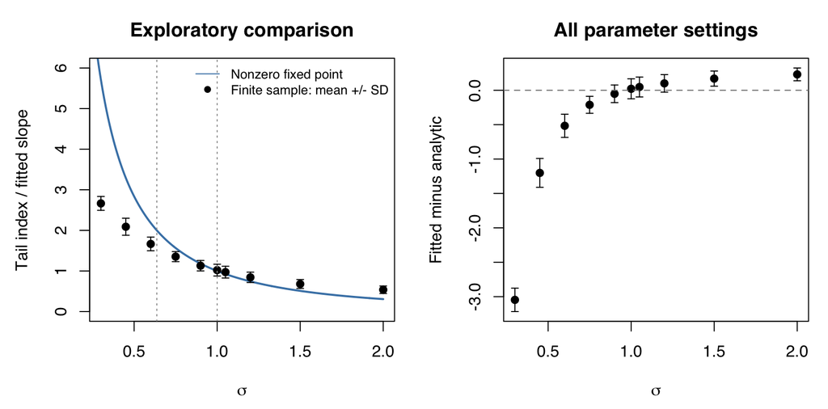

```r
alpha2_values <- vapply(sigs, alpha2, numeric(1))
alpha2_residual <- data.frame(sigma = sigs, analytic = alpha2_values,
  fitted = as.numeric(M["alpha", ]), seed_sd = as.numeric(S["alpha", ]),
  seed_se = as.numeric(S["alpha", ])/sqrt(SC_K),
  residual = as.numeric(M["alpha", ])-alpha2_values)
for (j in seq_len(nrow(alpha2_residual))) {
  for (nm in names(alpha2_residual)) reg(paste0("alpha2_", nm, "_", j),
    alpha2_residual[[nm]][j], if(nm == "analytic") "analytic" else if(nm == "fitted") "mean" else "derived",
    "alpha2_curve", "exploratory comparison between the analytic curve and the in-memory scan")
}
## Note: one()'s default arguments are now named constants; formals() returns symbols, not values—use the constants directly.
stopifnot(identical(formals(one)$N, quote(CH5_N)), identical(formals(one)$rounds, quote(CH5_R)))
reg("scan_N", CH5_N, "analytic", "§5.6 alpha2_curve", "simulation population, taken from CH5_N in §5.1")
reg("scan_rounds", CH5_R, "analytic", "§5.6 alpha2_curve", "number of simulation rounds, taken from CH5_R in §5.1")
reg("scan_seeds", SC_K, "derived", "§5.6 alpha2_curve", "number of independent seeds")
reg("scan_tail_percent", 100*0.125, "derived", "§5.6 alpha2_curve", "fixed tail-window percentage")
par(mfrow = c(1,2), mar = c(4.5,4.6,3,1), family = "sans")
plot(phase_sigma, phase_alpha, type = "l", xlim = range(sigs), ylim = c(0,6), lwd = 2,
     col = "steelblue", xlab = expression(sigma), ylab = "Tail index / fitted slope",
     main = "Exploratory comparison")
points(sigs, M["alpha", ], pch = 19)
arrows(sigs, M["alpha", ]-S["alpha", ], sigs, M["alpha", ]+S["alpha", ],
       code = 3, angle = 90, length = .035)
abline(v = c(sigma_c_var, sigma_c_mean), lty = 3, col = "gray60")
legend("topright", c("Nonzero fixed point", "Finite sample: mean +/- SD"),
       col = c("steelblue", "black"), lty = c(1,NA), pch = c(NA,19), bty = "n", cex = .8)
plot(sigs, alpha2_residual$residual, pch = 19, xlab = expression(sigma),
     ylab = "Fitted minus analytic", main = "All parameter settings",
     ylim = range(alpha2_residual$residual + rep(c(-1,1), each=length(sigs))*S["alpha", ]))
arrows(sigs, alpha2_residual$residual-S["alpha", ], sigs, alpha2_residual$residual+S["alpha", ],
       code = 3, angle = 90, length = .035)
abline(h=0, lty=2, col="gray50")
```

```r
ft_show(data.frame(
  `σ` = sprintf("%.2f", sigs), `Analytic α₂` = sprintf("%.4f", alpha2_residual$analytic),
  `Effective upper-tail slope (top 12.5%)` = sprintf("%.4f", alpha2_residual$fitted),
  `Seed SD` = sprintf("%.4f", alpha2_residual$seed_sd),
  `Mean SE` = sprintf("%.4f", alpha2_residual$seed_se),
  `Fitted − analytic` = sprintf("%+.4f", alpha2_residual$residual), check.names = FALSE))
```

| σ | Analytic α₂ | Effective upper-tail slope (top 12.5%) | Seed SD | Mean SE | Fitted − analytic |
| --- | --- | --- | --- | --- | --- |
| 0.30 | 5.7107 | 2.6642 | 0.1703 | 0.0492 | -3.0465 |
| 0.45 | 3.2909 | 2.0896 | 0.2094 | 0.0604 | -1.2013 |
| 0.60 | 2.1824 | 1.6659 | 0.1682 | 0.0486 | -0.5165 |
| 0.75 | 1.5656 | 1.3540 | 0.1236 | 0.0357 | -0.2116 |
| 0.90 | 1.1817 | 1.1300 | 0.1280 | 0.0369 | -0.0516 |
| 1.00 | 1.0000 | 1.0213 | 0.1452 | 0.0419 | +0.0213 |
| 1.05 | 0.9246 | 0.9719 | 0.1448 | 0.0418 | +0.0473 |
| 1.20 | 0.7432 | 0.8434 | 0.1273 | 0.0367 | +0.1001 |
| 1.50 | 0.5098 | 0.6793 | 0.1098 | 0.0317 | +0.1695 |
| 2.00 | 0.3069 | 0.5376 | 0.0929 | 0.0268 | +0.2307 |

**Detail: the objects that must be kept apart on the $\sigma>1$ side, and why normalization does not mechanically raise the slope (skippable)**

Here finite population, finite time, the tail asymptotics of the fixed point, and a regression on a fixed top 12.5% all stack up. The slope in the upper region is generally not the asymptotic exponent. Nor does normalization mechanically bias the slope upward: in a regression with an intercept, $w\mapsto cw$ only shifts $\log w$, and the slope is exactly unchanged; the sign and size of finite-scale effects need separate evidence.

Especially for $\sigma>1$, the following objects must be kept apart:

| Object | Known property |
| --- | --- |
| Nonzero smoothing-transform fixed point | infinite mean, tail exponent α₂ < 1; this is what the analytic curve draws |
| Infinite-population kinetic iteration started from equality | converges to δ₀; δ₀ has no power-law tail |
| Finite-population simulation | its long-time relation to either of the first two is unproved |

With finite population the tagged wealth satisfies $0\le w_{I,t}\le N$ and $Ew_{I,t}=1$, so it cannot converge to zero in distribution at fixed $N$. The smallest counterexample is $N=2$: each round the pair is exactly $(2U,2(1-U))$, independent of the return, the previous state, and $\sigma$, and the tagged distribution is always $\mathrm{Unif}(0,2)$. A curve that matches at a single population size does not prove that the double limit is being approached.

What about the Gini, then? We have said repeatedly that the control parameter is $\sigma$, not $G$, but a reader naturally wants to know what the Gini actually is at the critical setting. The number can be given—only it has to be given as a range, and the reason follows right after the numbers.

At $\sigma=1$, $N=1200$, and 500 rounds, the Gini across 12 seeds ranges from 0.79–0.91, with mean 0.859 and seed standard deviation 0.0393. The model Gini and the UBS per-adult wealth Gini are not comparable objects; the phase-transition criterion is $\sigma$, not $G$. Even if the reported Swedish value falls inside this interval, that does not mean Sweden sits at the model’s critical point.

At the same parameter, the same time horizon, and the same set of seeds, as the population goes from 300 to 1200 to 4800, the mean Gini is 0.83, 0.86, and 0.89 in turn, moving up with these population sizes. The parameter, the observable, the population size, and the order of limits all differ, so no single cross-sectional point can stand in for the analytic boundary; under the population-first, time-second order the theory gives $G_t\to1$. A fitted slope crossing a transient Gini is yet another quantity.

One thing can genuinely be tested. The figure above tests nothing, but the proposition at the foundation of this chapter—“fixed number of rounds, population tending to infinity”—can be checked directly, because it gives an exact recursion, and the recursion’s solution can be computed independently. This step can be compared directly: solve the Laplace recursion independently, then compute $\widehat\phi_{N,t}(s)=N^{-1}\sum_i e^{-sw_{i,t}}$ from the particle system. Hold the short time horizon fixed, increase the population, and compare the error with the replication uncertainty. The conclusion up front: the larger the population, the smaller the difference, in the direction the fixed-time proposition predicts.

Both the method and the results of this step stay in the main text, because it is the only test in the chapter that was actually carried through.

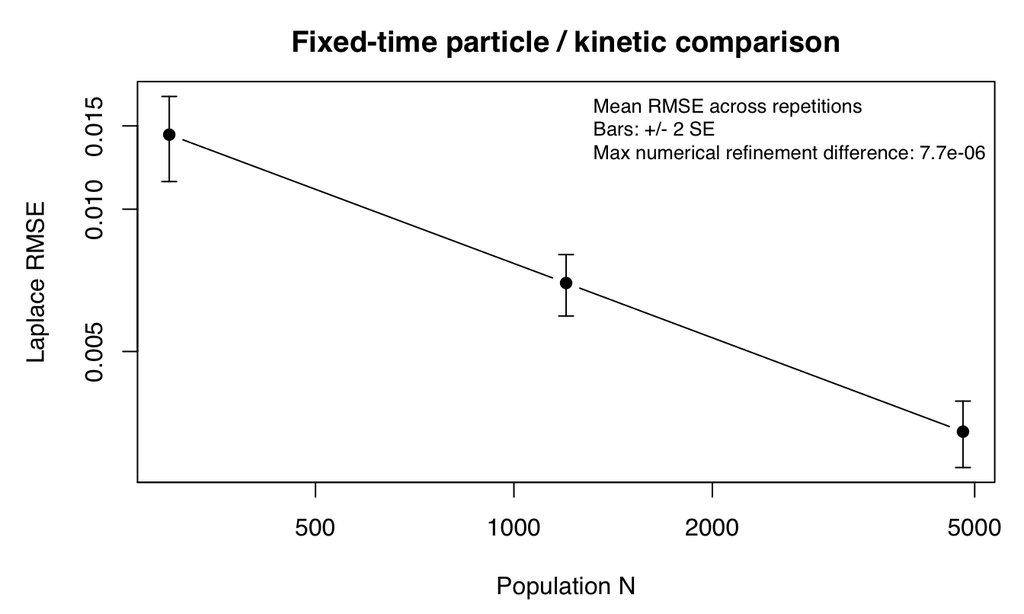

```r
## Gaussian quadrature nodes from the Jacobi matrix, using base R only.
.kc_gauss <- function(n, normal=FALSE) {
  b <- if(normal) sqrt(seq_len(n-1)) else seq_len(n-1)/sqrt(4*seq_len(n-1)^2-1)
  J <- matrix(0,n,n); J[cbind(1:(n-1),2:n)] <- b; J <- J+t(J)
  eg <- eigen(J,symmetric=TRUE); ord <- order(eg$values)
  list(x=if(normal) eg$values[ord] else (eg$values[ord]+1)/2,
       w=eg$vectors[1,ord]^2)
}
.kc_sigma <- .7; .kc_times <- c(1,3,5); .kc_s <- c(.25,1,4)
.kc_reps <- 40; .kc_N <- c(300,1200,4800)
.kc_targets <- expand.grid(s=.kc_s,t=.kc_times)
.kc_solve <- function(ng,nq) {
  lg <- seq(-24,24,length.out=ng); ss <- exp(lg); f <- exp(-ss)
  gu <- .kc_gauss(nq); gz <- .kc_gauss(nq,TRUE)
  lr <- .kc_sigma*gz$x-.kc_sigma^2/2
  ans <- matrix(NA_real_,length(.kc_s),max(.kc_times))
  for(tt in seq_len(max(.kc_times))) {
    nxt <- numeric(ng)
    for(j in seq_along(gu$x)) {
      args <- outer(lg+log(gu$x[j]),lr,"+")
      vals <- matrix(approx(lg,f,xout=as.vector(args),yleft=1,yright=0)$y,ng,nq)
      nxt <- nxt+gu$w[j]*as.vector(vals %*% gz$w)^2
    }
    f <- nxt
    ans[,tt] <- approx(lg,f,xout=log(.kc_s))$y
  }
  as.vector(ans[,.kc_times])
}
.kc_coarse <- .kc_solve(1800,24)
.kc_mid <- .kc_solve(3600,36)
.kc_fine <- .kc_solve(7200,52)
.kc_numdiff <- abs(.kc_fine-.kc_mid)
.kc_previous <- abs(.kc_mid-.kc_coarse)
## Run the particle transition kernel independently, short horizon only; do not reuse the integral equation to generate samples.
.kc_rng <- .Random.seed
.kc_particle <- function(n,seed) {
  set.seed(seed); w <- rep(1,n); hh <- n/2
  ans <- matrix(NA_real_,length(.kc_s),length(.kc_times))
  for(tt in seq_len(max(.kc_times))) {
    w <- w*exp(.01-.kc_sigma^2/2+.kc_sigma*rnorm(n))
    ii <- sample.int(n); i <- ii[1:hh]; j <- ii[(hh+1):n]
    pool <- w[i]+w[j]; u <- runif(hh); w[i] <- u*pool; w[j] <- (1-u)*pool
    w <- w/mean(w)
    if(tt %in% .kc_times) ans[,match(tt,.kc_times)] <- vapply(.kc_s,function(s) mean(exp(-s*w)),numeric(1))
  }
  as.vector(ans)
}
.kc_raw <- lapply(.kc_N,function(n) vapply(seq_len(.kc_reps),function(seed)
  .kc_particle(n,51000+seed),numeric(nrow(.kc_targets))))
.Random.seed <- .kc_rng
kinetic_results <- do.call(rbind,lapply(seq_along(.kc_N),function(j) {
  a <- .kc_raw[[j]]
  data.frame(N=.kc_N[j],.kc_targets,phi=.kc_fine,particle=rowMeans(a),
    seed_sd=apply(a,1,sd),seed_se=apply(a,1,sd)/sqrt(.kc_reps),
    residual=rowMeans(a)-.kc_fine,numeric_diff=.kc_numdiff,previous_diff=.kc_previous)
}))
.kc_rms_raw <- lapply(.kc_raw,function(a) sqrt(colMeans((a-.kc_fine)^2)))
.kc_rms <- vapply(.kc_rms_raw,mean,numeric(1))
.kc_rms_se <- vapply(.kc_rms_raw,sd,numeric(1))/sqrt(.kc_reps)
reg("kinetic_sigma",.kc_sigma,"derived","§5.6 kinetic_check","nonzero return fluctuation")
reg("kinetic_tmax",max(.kc_times),"derived","§5.6 kinetic_check","fixed short time horizon")
reg("kinetic_reps",.kc_reps,"derived","§5.6 kinetic_check","number of independent replications")
reg("kinetic_numeric_diff",max(.kc_numdiff),"derived","§5.6 kinetic_check","maximum difference between the last two refinements of integration and interpolation")
stopifnot(all(is.finite(as.matrix(kinetic_results))),all(.kc_fine>0 & .kc_fine<1),
          max(.kc_numdiff)<1e-4)
par(mar=c(4.5,4.7,2.8,1),family="sans")
plot(.kc_N,.kc_rms,log="xy",type="b",pch=19,xlab="Population N",ylab="Laplace RMSE",
     main="Fixed-time particle / kinetic comparison",
     ylim=range(c(.kc_rms-2*.kc_rms_se,.kc_rms+2*.kc_rms_se)))
arrows(.kc_N,.kc_rms-2*.kc_rms_se,.kc_N,.kc_rms+2*.kc_rms_se,
       code=3,angle=90,length=.05)
legend("topright",c("Mean RMSE across repetitions","Bars: +/- 2 SE",
                     sprintf("Max numerical refinement difference: %.2g",max(.kc_numdiff))),bty="n",cex=.8)
```

```r
ft_show(data.frame(
  `N`=kinetic_results$N,`Round`=kinetic_results$t,`s`=kinetic_results$s,
  `Recursion φ`=sprintf("%.5f",kinetic_results$phi),
  `Particle mean`=sprintf("%.5f",kinetic_results$particle),
  `Seed SD`=sprintf("%.5f",kinetic_results$seed_sd),
  `Mean SE`=sprintf("%.5f",kinetic_results$seed_se),
  `Particle − recursion`=sprintf("%+.5f",kinetic_results$residual),
  `Numerical difference`=sprintf("%.1e",kinetic_results$numeric_diff),check.names=FALSE),
  title="Independent comparison at a fixed short horizon; the numerical difference comes from the last two refinements")
```

Independent comparison at a fixed short horizon; the numerical difference comes from the last two refinements

| N | Round | s | Recursion φ | Particle mean | Seed SD | Mean SE | Particle − recursion | Numerical difference |
| --- | --- | --- | --- | --- | --- | --- | --- | --- |
| 300 | 1 | 0.25 | 0.79507 | 0.79520 | 0.00192 | 0.00030 | +0.00013 | 3.2e-06 |
| 300 | 1 | 1.00 | 0.47244 | 0.47286 | 0.00814 | 0.00129 | +0.00042 | 1.2e-06 |
| 300 | 1 | 4.00 | 0.15975 | 0.16003 | 0.01064 | 0.00168 | +0.00028 | 2.0e-06 |
| 300 | 3 | 0.25 | 0.81621 | 0.81553 | 0.00616 | 0.00097 | -0.00067 | 4.9e-06 |
| 300 | 3 | 1.00 | 0.55448 | 0.55166 | 0.01413 | 0.00223 | -0.00282 | 4.4e-06 |
| 300 | 3 | 4.00 | 0.25913 | 0.25592 | 0.01485 | 0.00235 | -0.00320 | 6.5e-07 |
| 300 | 5 | 0.25 | 0.82785 | 0.82897 | 0.01418 | 0.00224 | +0.00112 | 6.7e-06 |
| 300 | 5 | 1.00 | 0.58894 | 0.59064 | 0.02994 | 0.00473 | +0.00170 | 7.7e-06 |
| 300 | 5 | 4.00 | 0.30204 | 0.30485 | 0.03023 | 0.00478 | +0.00281 | 3.9e-06 |
| 1,200 | 1 | 0.25 | 0.79507 | 0.79512 | 0.00081 | 0.00013 | +0.00004 | 3.2e-06 |
| 1,200 | 1 | 1.00 | 0.47244 | 0.47263 | 0.00352 | 0.00056 | +0.00019 | 1.2e-06 |
| 1,200 | 1 | 4.00 | 0.15975 | 0.15986 | 0.00584 | 0.00092 | +0.00011 | 2.0e-06 |
| 1,200 | 3 | 0.25 | 0.81621 | 0.81652 | 0.00324 | 0.00051 | +0.00031 | 4.9e-06 |
| 1,200 | 3 | 1.00 | 0.55448 | 0.55595 | 0.00835 | 0.00132 | +0.00147 | 4.4e-06 |
| 1,200 | 3 | 4.00 | 0.25913 | 0.26016 | 0.00936 | 0.00148 | +0.00103 | 6.5e-07 |
| 1,200 | 5 | 0.25 | 0.82785 | 0.82796 | 0.00520 | 0.00082 | +0.00012 | 6.7e-06 |
| 1,200 | 5 | 1.00 | 0.58894 | 0.58984 | 0.01160 | 0.00183 | +0.00090 | 7.7e-06 |
| 1,200 | 5 | 4.00 | 0.30204 | 0.30370 | 0.01275 | 0.00202 | +0.00166 | 3.9e-06 |
| 4,800 | 1 | 0.25 | 0.79507 | 0.79499 | 0.00042 | 0.00007 | -0.00008 | 3.2e-06 |
| 4,800 | 1 | 1.00 | 0.47244 | 0.47197 | 0.00167 | 0.00026 | -0.00047 | 1.2e-06 |
| 4,800 | 1 | 4.00 | 0.15975 | 0.15896 | 0.00232 | 0.00037 | -0.00078 | 2.0e-06 |
| 4,800 | 3 | 0.25 | 0.81621 | 0.81628 | 0.00150 | 0.00024 | +0.00008 | 4.9e-06 |
| 4,800 | 3 | 1.00 | 0.55448 | 0.55446 | 0.00367 | 0.00058 | -0.00003 | 4.4e-06 |
| 4,800 | 3 | 4.00 | 0.25913 | 0.25852 | 0.00420 | 0.00066 | -0.00061 | 6.5e-07 |
| 4,800 | 5 | 0.25 | 0.82785 | 0.82746 | 0.00297 | 0.00047 | -0.00039 | 6.7e-06 |
| 4,800 | 5 | 1.00 | 0.58894 | 0.58828 | 0.00599 | 0.00095 | -0.00066 | 7.7e-06 |
| 4,800 | 5 | 4.00 | 0.30204 | 0.30185 | 0.00663 | 0.00105 | -0.00018 | 3.9e-06 |

**Detail: the numerical method and parameters of this step (skippable)**

This step uses $\sigma=0.7$, a maximum of 5 rounds, and 40 replications. On the integration side we use independent Gaussian quadrature and interpolation on a logarithmic grid; the “numerical difference” in the table is the gap between two adjacent refinements—a numerical estimate of the integration and interpolation error, not a strict error bound. The figure shows the root-mean-square error over all check times and Laplace arguments.

Be clear about which half this tests: this step supports the approximation “fixed number of rounds, population tending to infinity”; it cannot vouch for the long-time behavior of the finite simulation.

The gap flagged earlier is exactly here. This chapter’s conclusions about $\alpha_2$ live entirely inside the population-first, time-second order; the long-time behavior of the returns-plus-pool-and-split model at fixed population is not established here. (The yard-sale winner-takes-all result at the head of the chapter is indeed fixed-population, infinite-time—but that is another model, and its martingale argument has no purchase here.) The simulation, meanwhile, runs at exactly fixed population, and only out to a finite round 500, so the comparison figure can only be exploratory.

The scope ends here: this chapter characterizes the nonzero fixed point’s tail exponent analytically, and proves the uniform-integrability transition, weak condensation, and the Gini limit in the tree limit; it does not give strong condensation for a finite-population steady state, gives no country-level Gini threshold, and does not allow the control parameter to be backed out of a fitted cross-sectional slope.

## 5.7 Another Transition: Wealth Advantage and Redistribution

This chapter has treated “$\alpha_2$ crossing 1” as the signature of a phase transition all along, and by this point it is easy to come away with the impression that a tail exponent crossing 1 is the general criterion for condensation. That impression is wrong, and a ready counterexample corrects it—so this section sets that counterexample out on its own.

It is likewise a phase transition in wealth condensation, with a definite critical point, yet no Pareto exponent crosses 1 anywhere in the process. Boghosian’s extended yard-sale pits the strength of wealth advantage $\zeta$ against the strength of redistribution $\tau_\infty$. If the oligarchs hold a wealth share $c(t)$, the two forces compete like this: redistribution takes wealth from the oligarchs in proportion to their share, contributing a term $-\tau_\infty c$; wealth advantage lets the oligarchs profit from transactions, but how much they can profit depends on how much the ordinary population still holds, that is, $1-c$, contributing a term $+\zeta c(1-c)$. The larger the oligarchs, the fewer people left to extract from—this self-limiting effect is exactly where the phase transition comes from. Put the two terms together (Boghosian et al. 2016).

**Detail: the competition equation and its closed-form solution (skippable)**

$$c'(t)=c(t)[-\tau_\infty+\zeta(1-c(t))],\qquad
c_* = \max\left(0,1-\frac{\tau_\infty}{\zeta}\right).$$

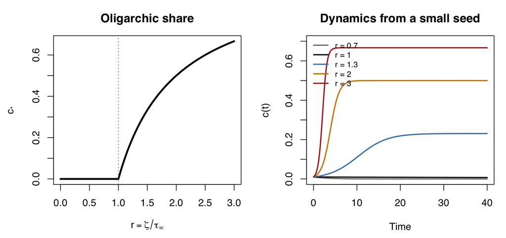

```r
## Evolve from a nonzero initial value using the closed form, so that slow motion near the critical point is not mistaken for a steady state.
.bog_tau <- 1; .bog_c0 <- 0.01
.bog_rcrit <- .bog_tau/.bog_tau
.bog_rhalf <- uniroot(function(r) 1-1/r-1/2, c(1,4))$root
reg("bog_rcrit", .bog_rcrit, "analytic", "§5.7 boghosian_oligarchy", "balance between advantage and redistribution")
reg("bog_rhalf", .bog_rhalf, "analytic", "§5.7 boghosian_oligarchy", "the ratio needed for the oligarchs to hold half")
reg("bog_c0", .bog_c0, "derived", "§5.7 boghosian_oligarchy", "initial value of the dynamics")
.bog_sol <- function(t, r) {
  zeta <- r*.bog_tau; a <- zeta-.bog_tau
  if(abs(a)<1e-12) return(.bog_c0/(1+zeta*.bog_c0*t))
  .bog_c0*exp(a*t)/(1+zeta*.bog_c0*expm1(a*t)/a)
}
.bog_r <- seq(0,3,length.out=400); .bog_t <- seq(0,40,length.out=500)
par(mfrow=c(1,2),mar=c(4.5,4.5,3,1),family="sans")
plot(.bog_r, ifelse(.bog_r>1,1-1/pmax(.bog_r,1),0),type="l",lwd=3,
     xlab=expression(r==zeta/tau[infinity]),ylab=expression(c["*"]),main="Oligarchic share")
abline(v=.bog_rcrit,lty=3,col="gray50")
plot(NA,xlim=range(.bog_t),ylim=c(0,.7),xlab="Time",ylab="c(t)",main="Dynamics from a small seed")
.bog_rs <- c(.7,1,1.3,2,3); .bog_cols <- c("gray50","black","steelblue","orange3","firebrick")
for(j in seq_along(.bog_rs)) lines(.bog_t,.bog_sol(.bog_t,.bog_rs[j]),col=.bog_cols[j],lwd=2)
legend("topleft",paste("r =",.bog_rs),col=.bog_cols,lwd=2,bty="n",cex=.8)
```

```r
stopifnot(max(abs(vapply(.bog_rs,function(r) .bog_sol(0,r),numeric(1))-.bog_c0))<1e-12)
```

The control parameter is $r=\zeta/\tau_\infty$, with critical value 1; at $r=2$ the oligarchs hold half. The dynamics figure starts from $c_0=0.01$. The original paper calls this a second-order phase transition: $c_*$ is continuous, and its first derivative is discontinuous at the critical point.

The ordinary population’s tail is Gaussian on both sides of the critical point, and degenerates to an exponential tail exactly at it. No Pareto exponent crosses 1 here. By contrast, when $\alpha_2$ of this chapter’s smoothing transform crosses 1, that crossing really does coincide, by theorem, with a phase transition in uniform integrability. “The tail exponent crosses 1” is a model-dependent criterion; condensation has no universal Pareto yardstick.

## 5.8 Translating a Gini into a Distribution: A Conversion Table

A Gini does not pin down the distribution. Only after you name a one-parameter family does conversion become meaningful—the table below runs the calculation for several common families.

**Detail: closed-form Ginis for three families (skippable)**

$$G_{\rm Pareto}=\frac1{2\alpha-1},\qquad
G_{\rm Gamma}=\frac{\Gamma(k+1/2)}{\sqrt\pi\Gamma(k+1)},\qquad
G_{\rm LN}=2\Phi(\sigma/\sqrt2)-1.$$

Pareto requires $\alpha>1$; the lognormal family’s $\sigma$ here is a shape parameter and must not be substituted for this chapter’s control parameter of the return process.

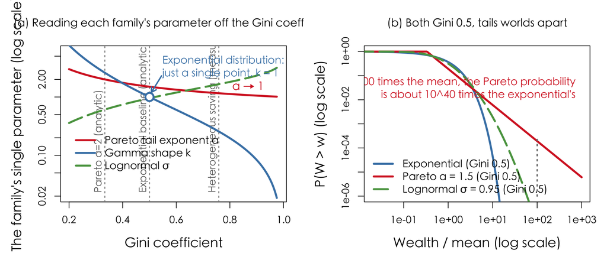

The Pietra column is taken from the lognormal family; change the family and it changes. This is a shape conversion, not a phase-transition location.

| Gini G | What this position is | Pareto α | Gamma k | Lognormal σ | Pietra P |
| --- | --- | --- | --- | --- | --- |
| 0.333 | Pareto α=2 (analytic) | 2.00 | 2.604 | 0.61 | 0.239 |
| 0.271 | Universal saving rate 0.5 (measured) | 2.34 | 4.076 | 0.49 | 0.194 |
| 0.500 | Island baseline (analytic) | 1.50 | 1.000 | 0.95 | 0.367 |
| 0.758 | Heterogeneous saving propensity (measured) | 1.16 | 0.257 | 1.66 | 0.592 |
| 0.830 | US wealth Gini | 1.10 | 0.159 | 1.94 | 0.668 |
| 0.870 | Swedish wealth Gini | 1.07 | 0.114 | 2.14 | 0.716 |

```r
ACC <- "#D62728"; BLU <- "steelblue"; GRN <- "#59A14F"
par(mfrow = c(1, 2), mar = c(4.8, 5.0, 3.8, 1.4), cex.lab = 1.32, cex.main = 1.1, family = "cjk")

## (a) The conversion table: given a Gini, what parameter does each one-parameter family need
gs    <- seq(0.20, 0.975, by = 0.005)
a_par <- (1/gs + 1)/2                                    # Pareto:   G = 1/(2a-1)
k_gam <- sapply(gs, function(g) uniroot(function(k)
           gamma(k+0.5)/(sqrt(pi)*gamma(k+1)) - g, c(1e-3, 60))$root)
s_lnm <- sqrt(2)*qnorm((gs + 1)/2)                       # Lognormal: G = 2*Phi(s/sqrt2)-1
plot(NA, xlim = c(0.2, 0.98), ylim = c(0.02, 6), log = "y",
     xlab = "Gini coefficient", ylab = "The family's single parameter (log scale)",
     main = "(a) Reading each family's parameter off the Gini coefficient")
## This family-parameter conversion is not locating a dynamical phase transition.
mark <- c(1/3, 0.50, REG$save_het$v)
abline(v = mark, lty = 3, lwd = 1.8, col = "gray62")
text(mark, 0.023, c("Pareto α=2 (analytic)", "Exponential baseline (analytic)", "Heterogeneous saving (measured)"),
     srt = 90, adj = c(0, -0.35), col = "gray40", cex = 1.0)
lines(gs, a_par, col = ACC, lwd = 3.2)
lines(gs, k_gam, col = BLU, lwd = 3.2)
lines(gs, s_lnm, col = GRN, lwd = 3.2, lty = 5)
points(0.5, 1, pch = 21, bg = "white", col = BLU, lwd = 3, cex = 1.8)
arrows(0.545, 2.3, 0.507, 1.2, length = 0.09, lwd = 2.2, col = BLU)
text(0.525, 2.9, "Exponential distribution:\njust a single point, k = 1", col = BLU, cex = 1.06, pos = 4)
text(0.95, 1.45, "α → 1", col = ACC, cex = 1.15, pos = 2)
legend(0.19, 0.30, c("Pareto tail exponent α", "Gamma shape k", "Lognormal σ"),
       col = c(ACC, BLU, GRN), lwd = 3.2, lty = c(1, 1, 5), bty = "n", cex = 1.05)

## (b) The same Gini, completely different shapes
xx <- 10^seq(-2, 3, length.out = 400)
al <- 1.5; mp <- al/(al - 1)                             # mean of Pareto(1.5) = 3
sg <- sqrt(2)*qnorm(0.75); ml <- exp(sg^2/2)             # the lognormal with the same Gini
plot(NA, xlim = c(0.02, 1000), ylim = c(1e-6, 1), log = "xy",
     xlab = "Wealth / mean (log scale)", ylab = "P(W > w) (log scale)",
     main = "(b) Both Gini 0.5, tails worlds apart")
lines(xx, exp(-xx), col = BLU, lwd = 3.2)
lines(xx, ifelse(xx >= 1/mp, (1/(mp*xx))^al, 1), col = ACC, lwd = 3.2)
lines(xx, 1 - pnorm(log(xx*ml)/sg), col = GRN, lwd = 3.2, lty = 5)
legend("bottomleft", c("Exponential (Gini 0.5)", "Pareto α = 1.5 (Gini 0.5)",
                       "Lognormal σ = 0.95 (Gini 0.5)"),
       col = c(BLU, ACC, GRN), lwd = 3.2, lty = c(1, 1, 5), bty = "n", cex = 1.05)
segments(100, 1e-6, 100, 3e-4, lty = 3, lwd = 2, col = "gray45")
reg("translate_log10_ratio", log10(((1/(mp*100))^al)/exp(-100)), "analytic", "§5.8 gini_translate", "base-10 log of the tail-probability ratio at a hundred times the mean")
reg("translate_x", 100, "derived", "§5.8 gini_translate", "where the tail probabilities are compared")
text(1000, 0.022, sprintf("At %.0f times the mean, the Pareto probability\nis about 10^%.0f times the exponential's", REG$translate_x$v, REG$translate_log10_ratio$v),
     col = ACC, cex = 1.06, pos = 2)
```

The exponential distribution has only a scale, no shape knob; and the Gini does not change with scale, so on the conversion figure it is just a single point. In the right panel several distributions share exactly the same Gini, yet their tails are worlds apart: at 100 times the mean, the Pareto tail probability is about $10^{40}$ times the exponential’s.

A Gini does not pin down shape, and a Pareto parameter inferred from a Gini cannot prove that a real distribution has a power-law tail. For a comparison of the theoretical tail exponent with fitted slopes, see Analytic Curves Beside Finite Simulations.

While we are at it, answer an obvious objection: if all we need is a shape, why not simply use the Gamma? It is more familiar than Pareto, and it has already appeared in this essay—the steady state of universal saving in §3.4 is exactly a Gamma. Two reasons.

**Detail: the arithmetic behind the two reasons (skippable)**

First, the shape of the tail. Gamma has $p(x)\propto x^{k-1}e^{-x/\theta}$, and that $e^{-x/\theta}$ keeps its tail exponential. Measure the local slope $\mathrm{d}\log p/\mathrm{d}\log x$ on log-log paper: for a power law it stays constant, while Gamma(4) steepens from -17.0 at 5 times the mean all the way to -317 at 80 times—on that paper it is curved. In the US income figure of §2.6, by contrast, the top segment is straight across several orders of magnitude.

Second, moments, which is worse, because this is exactly this chapter’s subject. Gamma’s moments have a closed form $E[X^n]=\theta^n\Gamma(k+n)/\Gamma(k)$, finite for any $k>0$ and any $n$—at $k=0.5$, $E[X^{20}]$ is already 3.05e+17, absurdly large but finite. The event “divergent moments” simply does not exist in the Gamma family, so neither the variance nor the mean ever dies. The whole chapter is looking for those two boundaries, and they do not exist in the Gamma family.

The more fundamental divide is here: Gamma is a shape you can pick, not a machine you can turn. Pick a Pareto and turn $\alpha$ past 2 and past 1, and of course you can “see” a phase transition—but then $\alpha$ is an input, which is to write the answer into the premise. What this chapter wants is $\alpha_2(\sigma)$ solved out of the dynamics: the knob in your hand is the return fluctuation $\sigma$, a knob with real meaning, and the tail exponent is its output, containing not one fitted parameter. That is why this chapter must have a model of its own, and cannot simply borrow a distribution family.

## 5.9 Where Does the Real World Sit?

The model’s phase transition already has its own coordinates. To put countries into it, what we compare is shape: is wealth concentration at the top, or does a large part of the population have net wealth near zero or negative? UBS’s per-adult wealth measure is not the same as this chapter’s nonnegative, normalized wealth process, so country Ginis cannot be projected onto the $\sigma$ axis (UBS 2023).

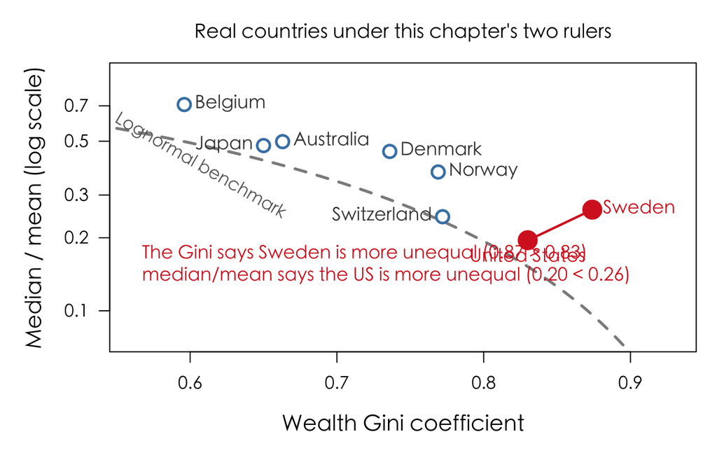

```r
ACC <- "#D62728"; BLU <- "steelblue"
## UBS Global Wealth Report 2023 (end-2022, household net worth, USD per adult)
cty <- data.frame(
  nm   = c("United States", "Sweden", "Switzerland", "Norway", "Denmark", "Japan", "Belgium", "Australia"),
  mean = c(551347, 296800, 685226, 385338, 409954, 216078, 352814, 496819),
  med  = c(107739,  77515, 167353, 143887, 186041, 103681, 249937, 247453),
  G    = c(0.830, 0.874, 0.772, 0.769, 0.736, 0.650, 0.596, 0.663))
cty$mm <- cty$med/cty$mean
for(j in seq_len(nrow(cty))) {
  reg(paste0("country_gini_",j), cty$G[j], "derived", "§5.9 real_world", "input value from the UBS report")
  reg(paste0("country_mm_",j), cty$mm[j], "derived", "§5.9 real_world", "UBS median wealth divided by mean wealth")
}

par(mar = c(4.8, 5.2, 3.0, 1.0), cex.lab = 1.25, cex.main = 1.12, family = "cjk")
plot(NA, xlim = c(0.56, 0.93), ylim = c(0.075, 0.95), log = "y", yaxt = "n",
     xlab = "Wealth Gini coefficient", ylab = "Median / mean (log scale)",
     main = "Real countries under this chapter's two rulers")
axis(2, at = c(0.1, 0.2, 0.3, 0.5, 0.7), labels = c("0.1","0.2","0.3","0.5","0.7"), las = 1)

## Lognormal benchmark: given a Gini, if the distribution really is lognormal, median/mean should fall on this line
gg <- seq(0.55, 0.95, by = 0.005); sg <- sqrt(2)*qnorm((gg + 1)/2)
lines(gg, exp(-sg^2/2), col = "gray55", lwd = 2.6, lty = 2)
text(0.607, 0.395, "Lognormal benchmark", col = "gray40", cex = 1.0, srt = -30)


hi <- cty$nm %in% c("United States", "Sweden")
arrows(0.830, 0.195, 0.874, 0.261, code = 3, length = 0.08, lwd = 2.2, col = ACC)
points(cty$G, cty$mm, pch = 21, cex = ifelse(hi, 2.2, 1.6),
       bg = ifelse(hi, ACC, "white"), col = ifelse(hi, ACC, BLU), lwd = 2.4)
text(cty$G, cty$mm, cty$nm, pos = c(1, 4, 2, 4, 4, 2, 4, 4), cex = 1.05,
     col = ifelse(hi, ACC, "gray25"), font = ifelse(hi, 2, 1))
text(0.56, 0.148, paste("The Gini says Sweden is more unequal (0.87 > 0.83)",
                        "median/mean says the US is more unequal (0.20 < 0.26)", sep = "\n"),
     col = ACC, cex = 1.05, pos = 4)
```

The Gini ranks Sweden above the United States: 0.87 versus 0.83; the ratio of median to mean reverses the order: the United States 0.20, Sweden 0.26. The gray dashed line is the lognormal benchmark at the same Gini; the direction of deviation shows the difference in distribution shape.

Concentration at the top in the United States and zero or negative net wealth at the bottom in Sweden are not the same thing. For the US upper wealth tail see Saez and Zucman; for Sweden’s top and its net wealth distribution see Bengtsson et al. (Saez and Zucman 2016; Bengtsson et al. 2018). These studies do not use exactly the same years, samples, and estimation methods as UBS; they can explain magnitudes and shapes, but they cannot be pieced together into a critical criterion of the same precision.

Neither country’s net worth measure counts public pension entitlements, and the lifetime resources of an ordinary Swedish household depend more on public and occupational pensions. Adding those entitlements could change the ranking; without comparable augmented-wealth estimates for the two countries, we only flag the definition here and cannot report corrected numbers.

Nor can a trend be converted into “how many years until collapse”: this chapter does not estimate a country’s $\sigma$, has no mapping from policies and institutions to that parameter, and no calibration of population size and time. So extrapolating a top share linearly to any threshold, or inferring real-world acceleration from behavior near the model’s critical point, has no basis for inference.

A Gini of the same magnitude can be a collapsed bottom or a concentrated top. One Curve, Two Boundaries answers a question about this model’s dynamics; Translating a Gini into a Distribution: A Conversion Table answers a question about cross-sectional shape. Each answer is clear in its own domain, and neither can pass for the other.

## 5.10 What Arrives First Is Not Collapse but the Loss of Procedural Legitimacy

This whole chapter has answered one question: how bad can it get. But the most important point in the answer is not in the four limits themselves:

> Collapse is not a reason to pursue equality—because it is probably not the first thing to arrive.

The four limits discussed in this chapter are all economic in meaning: the statistics fail, the individual sinks, the collective disappears, exchange stops. They share one implicit premise: that society will quietly keep running under the same rules until it mathematically cannot run any further. That premise is false, and people in the real world can demand that the rules be rewritten.

§3.4 measured one thing: make the saving rate differ across people, and the exponential tail becomes a power-law tail. That sentence must be read on its own terms—it says “that one particular heterogeneity change will change the tail”, not “any heterogeneous rule grows a power-law tail” (a heterogeneous meeting rate that preserves detailed balance can give the same equilibrium), and not “a homogeneous rule can never equalize”: replace everyone by $w\mapsto(1-\tau)w+\tau\bar w$ (everyone pays the same proportion, then it is rebated per capita), and the rule is word for word the same for everyone, the total does not move by a cent, yet the Gini is multiplied by exactly $1-\tau$; this chapter’s pool-and-split is itself a homogeneous equalizing mechanism. What decides the outcome is the particular transition rule, not the label “homogeneous/heterogeneous”. But there is indeed one asymmetry here that has never been stated outright:

> Procedural fairness by itself guarantees nothing; only the specified baseline exchange rule delivers 0.5—and even under it, only the existence of the baseline is guaranteed, not a return to the baseline from elsewhere.

An island that starts from zero with nothing but random stirring is brought by procedural fairness to 0.5. But a society already at 0.83 will not be brought back to 0.5 by maintaining procedural fairness—because the mechanisms that pushed it to 0.83 (the whole family in Chapter 6: returns to capital, credit, inheritance) all operate under procedural fairness themselves. The rule really does say, word for word and for everyone alike, “capital appreciates in proportion”, and that identical rule is precisely the multiplicative structure of §4.3.

So for those in the lower half, procedural fairness turns from a protection into a lock.

At that point an understandable response is to demand different rules. Concretely: shift from demanding procedural fairness to demanding outcome fairness. Note that this is not the same as abandoning “the rule is the same for everyone”—the “same proportional levy, rebated per capita” rule above is a counterexample: it applies equally to everyone, yet multiplies the Gini by $1-\tau$. What has to change is the transition rule itself, not the homogeneity of the rule. In the model this is not a moral judgment but a mechanistic inference: when the outcome of procedural fairness is unacceptable and the procedure cannot correct the outcome on its own, the only knob still available is the procedure itself.

Anthropology has a name for this, and this essay has used it already: Boehm’s reverse dominance hierarchy—a majority forms a coalition and, with an explicitly asymmetric rule, pushes back down any individual who tries to climb (Boehm 1999). Equality in hunter-gatherer societies is not a product of procedural fairness; it is precisely a product of systematically violating procedural fairness. (That is this particular path—the reverse dominance hierarchy is itself asymmetric; it does not say that equalization can only take the asymmetric road.)

### 5.10.1 The Model Stops Here

The inference above has this form: *in a society already far from the baseline, where the mechanisms that pushed it away are themselves procedurally proper, pressure will arise to change the transition rule.* (Changing the rule need not mean abandoning “the rule is the same for everyone”—the proportional levy with per-capita rebate above is homogeneous.) This is a mechanistic explanation; the model has no endogenous variable for political action, so it cannot treat the appearance of pressure as a proven prediction.

What it cannot say is which concrete social movements in the real world are expressions of that pressure. That is an empirical question, and any real conflict has multiple sources—identity, religion, region, generation, culture—not all of which can be traced to the wealth distribution. To read some particular debate in contemporary politics directly as “the bottom saving itself” is to mistake a mechanistic skeleton for a complete explanation.

But there is a distinction the model can supply, one that intuition tends to blur. Faced with the same “inequality of outcome”, there are two diagnoses, formally quite different:

- Diagnosis one: the rule was never homogeneous—historically it treated some people differently, so what needs doing is restoring homogeneity.
- Diagnosis two: the rule is indeed homogeneous, but the homogeneous rule is itself multiplicative—so what needs doing is replacing that transition rule to offset it. The means can be homogeneous (redistribution identical for everyone) or asymmetric (aimed only at the top); the model says only “the rule must move”, not which side it must move toward.

Public discussion often treats the two as one thing, but they require different operations, carry different costs, and fail in different ways: overshooting diagnosis one creates a new asymmetry, while undershooting diagnosis two amounts to doing nothing. This essay does not judge which one holds on which occasion—the model can only point out that they are two things, not choose between them for anyone.

A third thing it can supply is a reminder: if the tension between “procedural fairness” and “outcome fairness” suddenly sharpens in a society’s public debate, that is not necessarily a change in values; it may simply be a change in the distribution. The same set of values, placed in a society with a Gini of 0.5 and in one with a Gini of 0.83, will point to different policies.

### 5.10.2 Existing Quantitative Literature in This Direction

Turchin’s structural-demographic theory models sociopolitical instability as a function of three precursors: mass impoverishment, elite overproduction, and state fiscal distress. The first is not the same thing as this chapter’s “collapse of the median/mean”, and its direction is not guaranteed to agree with it—the median/mean is a ratio: it can fall while median real wealth rises substantially, and it can stay put while everyone gets poorer. To speak of “mass impoverishment” one needs separate evidence on actual living standards (Turchin 2016). Scheidel gives a colder conclusion from the historical side: in the past two thousand years only four things have substantially pushed inequality down—war, revolution, state collapse, and plague (Scheidel 2017).

Put the two together and you get an uncomfortable inference: inequality is rarely pushed down peacefully. And Chapter 6 will measure something more troublesome: redistribution does not inherently point downward—its sign depends on whom the tax base covers and where spending flows, and those are precisely the places where power intervenes first.

So the question this essay opened with has to be turned around here. Rousseau asked about “the origin of inequality”, and that way of asking has a blind spot: in the animal world, hierarchy is the norm. Baboons, chimpanzees, wolf packs, and chicken flocks all have stable dominance sequences, and rank decides who eats first and who gets to reproduce. Human hunter-gatherer societies, by contrast, are unusually equal—and as said above, that equality rests on systematically violating procedural fairness.

> Not where inequality comes from, but where equality comes from. Inequality is the default—this essay has shown that even a perfectly procedurally fair rule automatically produces a Gini of 0.5, while the real world sits at 0.83; equality is the achievement that takes effort to maintain.

So what does that effort buy? This essay does not answer that question, because it is the main subject of its companion piece, *Fairness and Efficiency: The Same Temperature*, where fairness is not the opposite of efficiency but the correct pricing of uncertainty. Seen along that line, Boehm’s reverse dominance hierarchy is exactly a social device for keeping the temperature high—a majority forming a coalition to suppress monopoly is, in effect, forcing variation into the system, and in a world where “no one knows who is good”, that is precisely the efficiency-optimal move. Suppressing monopoly is not to avoid collapse; it is because it pays. That argument is developed there.

# 6 What Other Origins of Inequality Are There, and What Can Be Changed?

Let us first gather what has been measured so far. Up to this point the essay has not been about “random stirring” alone—since Chapter 3, every swapped part has added a mechanism, and four have now been measured:

| Mechanism | Where | Equilibrium | Gini coefficient |
| --- | --- | --- | --- |
| Conservation + additive + unbiased (baseline) | Chs. 2–4 | Exponential | 0.50 |
| Save half of everything, then exchange | §3.4 | Gamma | 0.27 |
| Saving propensity varies by person | §3.4 | Power-law tail | 0.758 |
| Stake proportional to wealth (yard-sale) | §4.3 | None (condensation) | → 1 |
| Capital returns with randomness σ | Ch. 5 | Power-law tail | 0.67 (σ=0.6) / 0.92 (σ=1.2) |

These rows share one feature: each swaps a part on the same machine—how much is put up for exchange each time, how much is kept back, whether money breeds on its own. All of them are parameters inside the exchange rule. And those parameters alone already stretch the Gini from 0.27 to almost 1.

Two regularities hide inside them, and this chapter will run into them again and again:

- Everything that pushes the Gini up is multiplicative—proportional stakes, proportional interest, saving rates that vary by person (which makes wealth growth rates vary by person, again multiplicative). Additive fairness stops at 0.5; multiplicative fairness does not.
- Everything that pushes the Gini down either breaks conservation or adds a restoring force—universal saving ties a spring to each person’s wealth and pulls them back toward where they started.

This chapter adds things outside the machine. The two categories Rousseau listed (natural talent, institutions), credit and inheritance and inflation in the real world, and taxation—absent from the model yet used every day—are not parameters of the exchange rule but social institutions. This chapter puts them into the same model one at a time, measures how many Gini points each is worth, and sorts them by direction into three families: those that only push up, those whose direction depends on whether the rule is homogeneous, and the one family whose direction people can choose for themselves—and “choose” does not mean “down”.

```r
## The master figure and the three family panels share one drawing routine and one horizontal axis (0.2–1.0), so the family panels line up with the master figure
UP <- "#D62728"; DN <- "#2C7BB6"; NEU <- "gray55"
draw_fmap <- function(FKEY, title){
  stopifnot(all(FKEY %in% names(REG)))                       # one missing key is fatal; no figure may be drawn wrong in silence
  f <- data.frame(
    lab     = names(FKEY),
    g       = sapply(FKEY, function(k) REG[[k]]$v),
    kind    = sapply(FKEY, function(k) REG[[k]]$kind),
    neutral = sapply(FKEY, function(k) isTRUE(REG[[k]]$neutral)),
    stringsAsFactors = FALSE)
  f$d <- f$g - 0.5
  ## Ordering discipline: a 0.001 difference between point estimates does not make a meaningful order.
  ## Sort by endpoint from high to low, then merge adjacent items whose **whole group spans no more than 0.01 Gini points**
  ## (complete linkage, not consecutive-difference grouping—otherwise 0.375/0.372/0.364 would chain into one group, total span 0.011, over the limit),
  ## and sort stably by label within a group, so the figure cannot be read as a false ranking such as "a progressive tax bites harder than a floor" produced by noise.
  f <- f[order(f$g, decreasing = TRUE), ]
  grp <- integer(nrow(f)); gid <- 1L; anchor <- f$g[1]
  for (k in seq_len(nrow(f))){
    if (anchor - f$g[k] > 0.01){ gid <- gid + 1L; anchor <- f$g[k] }
    grp[k] <- gid
  }
  f <- f[order(grp, f$lab), ]
  n <- nrow(f); y <- n:1
  ## Neutrality is taken only from an explicit flag (an analytic identity, or an effect interval covering 0)—never judged by "how close to 0.5"
  neutral <- f$neutral
  col <- ifelse(neutral, NEU, ifelse(f$d > 0, UP, DN))

  par(mar = c(4.6, 0.4, 4.0, 0.4), cex.lab = 1.3, family = "cjk")
  plot(NA, xlim = c(-0.72, 1.06), ylim = c(-0.35, n + 1.9), axes = FALSE,
       xlab = "", ylab = "")
  axis(1, at = seq(0.2, 1.0, 0.1), cex.axis = 1.1)
  mtext("Gini coefficient", side = 1, line = 2.8, at = 0.6, cex = 1.3)
  abline(v = 0.5, lwd = 2.4, col = "gray30")
  text(0.5, n + 1.4, "Baseline 0.5 (procedural fairness only)", col = "gray25", cex = 1.12)
  for (k in seq_len(n)){
    segments(0.19, y[k], 1.04, y[k], col = "gray92", lwd = 1)
    if (neutral[k]) points(0.5, y[k], pch = 16, cex = 1.4, col = NEU)
    else arrows(0.5, y[k], f$g[k], y[k], length = 0.10, lwd = 3.2, col = col[k])
    text(0.175, y[k], f$lab[k], col = col[k], cex = 0.95, pos = 2)
    text(f$g[k] + ifelse(f$d[k] >= 0, 0.010, -0.010), y[k] + 0.32,
         sprintf("%.2f", f$g[k]), col = col[k], cex = 0.92,
         pos = ifelse(f$d[k] >= 0, 4, 2))
  }
  mtext(title,
        side = 3, line = 1.6, cex = 1.2, font = 2, adj = 0)
  text(0.21, -0.15, "More equal", col = DN, cex = 1.15, font = 2, pos = 4)
  text(1.03, -0.15, "More unequal", col = UP, cex = 1.15, font = 2, pos = 2)
  invisible(f)
}
## All 21 rows come from REG—each number is registered where it is computed; this chunk only reads them
FKEY_ALL <- c(
  "Stake proportional to wealth (yard-sale) §4.3"          = "yardsale",
  "Ability spectrum: top is 1000× the median §6.1.1"       = "ability_sd3",
  "Capital returns with randomness σ = 1.2 §5"             = "capital_12",
  "Ability spectrum: top is 100× the median §6.1.1"        = "ability_sd2",
  "Saving propensity varies by person §3.4"                = "save_het",
  "Ability spectrum: top is 10× the median §6.1.1"         = "ability_sd1",
  "Random single-heir inheritance (toy setup) §6.2"        = "inherit_random_single_heir",
  "Capital returns with randomness σ = 0.6 §5"             = "capital_06",
  "Growth allocated in proportion to wealth (any g) §6.2"  = "growth_prop",
  "Neutral inheritance (one share each) §6.2"              = "inherit_neutral",
  "Inflation (equal proportional erosion) §6.2"            = "inflation_flat",
  "Plague: random 30% population loss §6.3"                = "plague",
  "Non-exempt pay tax + spending flows to the elite (constructed control) §6.3.4" = "cov_elite",
  "Top exempt + per-capita rebate (same tax rate) §6.3.4"  = "cov_exempt",
  "Minimum guarantee: floor at 0.5× the mean §6.3"         = "floor_05",
  "Progressive tax (total revenue 12%) §6.3"               = "tax_progressive",
  "One-off expropriation of the top, rebated (war/revolution) §6.3" = "confiscate",
  "Partible inheritance §6.2"                              = "inherit_partible",
  "40% tax every round, rebated per capita §6.3"           = "tax40",
  "Growth split equally per capita (g = 1) §6.2"           = "growth_flat",
  "Save half of everything, then exchange §3.4"            = "save_all")
```

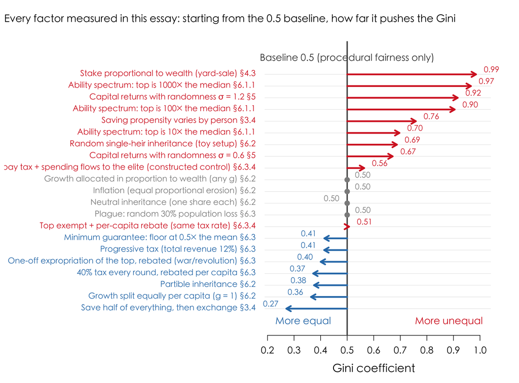

This chapter moves through the three families:

- Upward-only: the ability spectrum, returns to capital, credit. Strong or weak, each has one direction only; the difference is how far it pushes.
- Direction depends on “is it the same for everyone?”: inheritance, saving, inflation, growth. The same mechanism carries one sign when the rule is homogeneous and the other when it varies by person.
- The one you can turn: redistribution. It is the only family whose direction people can set—and “can be set” does not mean “down”.

A few other things should not be measured by the Gini at all; what matters about them lies elsewhere (who is still in the game, whether positions change hands), and §6.5 takes them up.

The three families follow, one at a time.

## 6.1 The Upward-Only Family: Ability, Credit, Returns to Capital

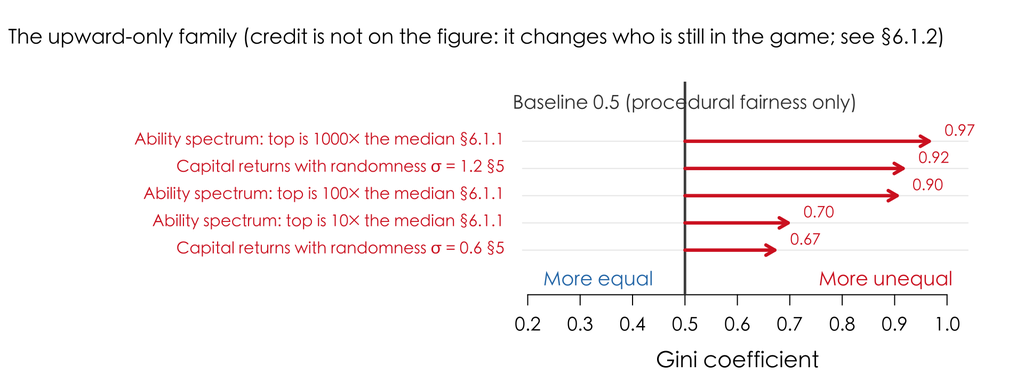

Begin with the red family. Their common feature is a single direction—strong or weak, they only push the Gini to the right; the difference is how far. Take the three in turn: ability is the natural inequality Rousseau judged “very small”; credit emerges once the wall of Chapter 2 loosens; returns to capital is where the knob of Chapter 5 sits within this family.

### 6.1.1 Ability: Not “Small”, but a Cross-Industry Spectrum of Magnitudes

Take the two ends first: the natural inequality Rousseau judged “very small”, and the knob that can be turned on purpose.

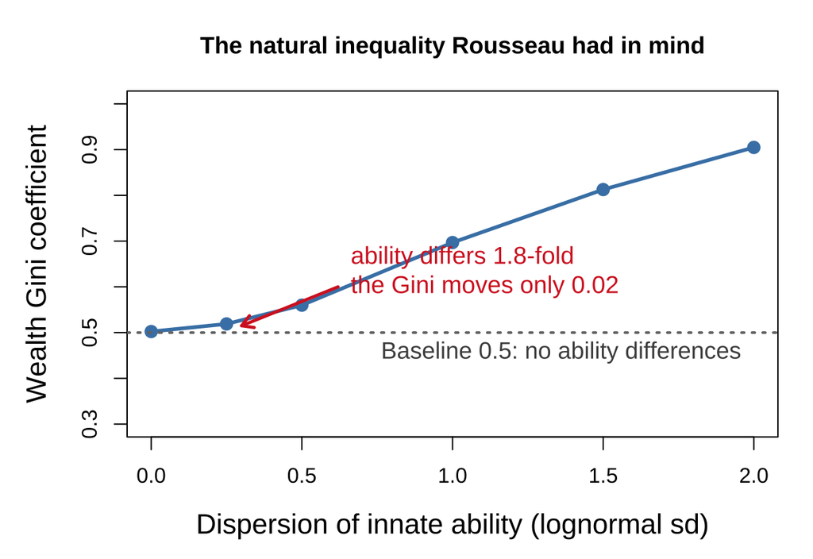

```r
## The same exchange rule, with one part changed
run1 <- function(N = 1500, rounds = 400, mode = "base", p = 0, seed = 1){
  set.seed(seed); w <- rep(1, N); half <- N/2
  a <- if (mode == "ability") exp(rnorm(N, 0, p)) else rep(1, N)
  a <- a/mean(a)                                  # mean 1; at p = 0 all are 1 and it falls back to the baseline
  for (r in 1:rounds){
    if (mode == "tax" && p > 0){ tx <- p*w; w <- w - tx + sum(tx)/N }   # proportional tax + per-capita rebate
    idx <- sample.int(N); i <- idx[1:half]; j <- idx[(half+1):N]
    pooled <- w[i] + w[j]
    ## Ability enters the exchange: the split ratio ~ Beta(a_i, a_j); a uniformly random split is its special case at a≡1
    e <- if (mode == "ability") rbeta(half, a[i], a[j]) else runif(half)
    w[i] <- e*pooled; w[j] <- (1 - e)*pooled
  }
  gini(w)
}
sds  <- c(0, 0.25, 0.5, 1, 1.5, 2, 3)          # includes sd = 3, for the "1000×" row of the table below
g_ab <- sapply(sds, function(x) run1(mode = "ability", p = x))
## Conversion table: sd -> top (99th percentile) relative to median, exp(2.33*sd), and the Gini and its gain over the baseline
AB <- data.frame(sd = sds, mult = exp(2.33*sds), gini = g_ab)
AB$dG <- AB$gini - AB$gini[AB$sd == 0]
## The figure stops at sd = 2 (sd = 3 is off this figure's range; it enters the table only)
pl <- AB$sd <= 2

ACC <- "#D62728"
par(mar = c(4.8, 5.0, 3.6, 1.4), cex.lab = 1.32, cex.main = 1.12)
plot(AB$sd[pl], AB$gini[pl], type = "o", pch = 16, cex = 1.4, lwd = 2.8, col = "steelblue",
     ylim = c(0.3, 1), xlab = "Dispersion of innate ability (lognormal sd)", ylab = "Wealth Gini coefficient",
     main = "The natural inequality Rousseau had in mind")
abline(h = 0.5, lty = 3, lwd = 2, col = "gray45")
text(2, 0.455, "Baseline 0.5: no ability differences", col = "gray30", cex = 1.12, pos = 2)
arrows(0.62, 0.60, 0.30, 0.515, length = 0.10, lwd = 2.4, col = ACC)
text(0.62, 0.62, sprintf("ability differs %.1f-fold\nthe Gini moves only %.2f",
     AB$mult[AB$sd == 0.25], AB$dG[AB$sd == 0.25]), col = ACC, cex = 1.15, pos = 4)
```

```r
for (k in c(1, 2, 3))
  reg(sprintf("ability_sd%d", k), AB$gini[AB$sd == k], "point", "§6.1.1 ability_sweep",
      sprintf("top/median ≈ %g×", signif(exp(2.33*k), 1)))
## Self-check: the three ability-spectrum settings match the values registered in REG (the master figure reads REG directly in §6.5)
stopifnot(all(is.finite(AB$gini)), all(diff(AB$gini) > 0))
```

Natural inequality: not “small”, but a cross-industry spectrum of magnitudes. Rousseau asserted that natural inequality is “very small”, but that was an analogy drawn from animals. People differ—they use tools and form organizations (firms, schools, armies, guilds), and these two multiply raw differences in ability, by a factor that varies by industry:

What sets the multiplier is not the industry’s name but the structure of its output—roughly three kinds:

- Work whose output is capped by physical pace: a fixed action per unit time, with the body and the process setting the ceiling; the strongest person is only one or two times faster than the median.
- Work whose output is replicable at near-zero marginal cost: one result, once made, can be copied any number of times, so ability differences are multiplied up to tenfold or a hundredfold.
- Work whose output is a discovery: some people never find anything, others find one thing that changes a whole field. The denominator can be zero, so the ratio has no upper bound at all.

Tools and organizations are exactly what push the first kind toward the second and third—they free a person’s output from the limits of their own hands. The two multiply in different ways but do the same thing: tools copy one person’s effort outward, organizations attach other people’s labor to one person’s judgment.

| Top / median | Lognormal sd | Gini coefficient | Extra contribution of ability | Roughly corresponds to |
| --- | --- | --- | --- | --- |
| 1× (everyone alike) | 0 | 0.50 | 0 | Island baseline: everyone alike |
| 2× | 0.25 | 0.52 | +0.02 | Output capped by physical pace |
| 10× | 1.0 | 0.70 | +0.19 | Output replicable |
| 100× | 2.0 | 0.90 | +0.40 | Output replicable, and amplified harder |
| 1000× | 3.0 | 0.97 | +0.46 | Output is a discovery |

Read it with care, but the conclusion is plain:

- In industries with a narrow ability spectrum (a factor of one or two), the 0.5 baseline dominates everything—almost all observed inequality comes from random stirring, and has nothing to do with who is more capable. Here Rousseau guessed right.
- In industries where the spectrum spans orders of magnitude, it reverses: a tenfold gap pushes the Gini to 0.70, a hundredfold to 0.90. Now ability is the main term and the baseline is background.

One definitional point must be stated: ability `a` here is exogenous, drawn once and fixed for life. In reality it is not—ability is itself shaped by past resource allocation. This is not the essay’s invention; both literatures have mature treatments:

- On the economics side: Cunha and Heckman’s skill-formation theory supplies two mechanisms—self-productivity (skill acquired in one period carries into later periods) and dynamic complementarity (earlier skill raises the output of later investment) (Cunha and Heckman 2007). Identifying it takes repeated measurement plus a latent-factor model, and so longitudinal data (Cunha et al. 2010). Note that their state variables are skill and investment, not wealth.
- On the kinetic-theory side: there is already a family of work that puts knowledge (or ability) and wealth together in Boltzmann-type models. One-way—knowledge affects the risk and saving parameters of a trade (Pareschi and Toscani 2014); two-way—each variable enters the other’s collision rule, with the mechanism “the wealthier are taken to be more credible, so knowledge flows to them” (Boudin and Trussardi 2024).

This essay does neither: `a` lives only in this section and the ability settings of Chapter 7, and never enters the tax, inheritance, or saving mechanisms; nor is it rewritten by wealth. So everything said below about ability holds under the premise that ability is exogenous. - So the dichotomy “natural inequality vs institutional inequality” already fails at the occupational level—within one society, the relative weight of the two mechanisms varies severalfold with how output is produced.

This curve carries a restriction that must be said on the spot. It belongs to this one reduced-form mechanism: ability affects the split ratio through `Beta(a_i, a_j)`. The variance of that specification is $p(1-p)/(a_i+a_j+1)$—widening the ability spectrum changes the relative split advantage and the noise of the exchange itself at the same time, and the two effects are entangled. So reading the table as “where this machine goes under this ability spectrum” is accurate; reading it as a general “productive ability → Gini” conversion table goes too far. One more layer: `a` is a reduced-form proxy for productive ability in the model—there is no production on the island, so the step “higher ability ⟹ a better split” is a stipulated mapping, not something this essay derives.

One more layer Rousseau could not see: tools and organizations are multiplicative amplifiers, and multiplicative amplification is exactly the machine that turns an exponential tail into a power-law tail (Putting a Knob on Returns). That is, these two distinctively human things do not just amplify differences in ability; they change the shape of the inequality distribution from exponential to power law—a change in kind, not in degree.

### 6.1.2 Credit: Who Can Borrow Matters More Than How Much

This is not one premise but three. Once the wall of Chapter 2 loosens, three questions come up, not one, and their answers are independent:

1. Who can borrow?—by what rule the credit line is allocated.
2. How much can they borrow?—how large the line is.
3. What if they cannot?—after wealth goes negative, is the person still in the game.

Measure the three separately and the conclusions are far apart.

```r
N <- 2000
run_credit <- function(mode, L = 1, rounds = 2000, seed = 2){
  set.seed(seed); w <- rep(1, N); alive <- rep(TRUE, N)
  vc <- runif(N) < 0.2                                   # venture style: 20% of people get a line on the strength of "ability"
  for (r in 1:rounds){
    id <- which(alive); if (length(id) < 4) break
    id <- sample(id); h <- floor(length(id)/2); i <- id[1:h]; j <- id[(h+1):(2*h)]
    lim <- switch(mode,
      none   = rep(0, h),                                # no credit
      flat   = rep(L, h),                                # equal credit lines
      collat = pmax(w[i], 0),                            # collateral style: line ∝ own assets
      vc     = ifelse(vc[i], L, 0),                      # venture style: independent of assets
      margin = rep(L, h))                                # equal credit lines + liquidation on touching -L
    pay <- pmin(1, pmax(w[i] + lim, 0))
    w[i] <- w[i] - pay; w[j] <- w[j] + pay
    if (mode == "margin"){ d <- alive & (w <= -L); alive[d] <- FALSE; w[d] <- 0 }
  }
  sw <- sort(w, TRUE)
  c(top1 = 100*sum(sw[1:(N/100)])/sum(sw[sw > 0]), neg = 100*mean(w < 0),
    out = 100*mean(!alive), sdmu = sd(w)/mean(w))
}
CR <- sapply(c("none","flat","collat","vc","margin"), run_credit)
```

| Credit regime | Top 1% share of positive wealth | Population in debt | Liquidated out | sd / mean |
| --- | --- | --- | --- | --- |
| No credit (baseline here) | 7.4% | 0.0% | 0.0% | 1.39 |
| Equal credit lines | 9.2% | 33.1% | 0.0% | 2.48 |
| Collateral: line ∝ own assets | 7.4% | 0.0% | 0.0% | 1.39 |
| Venture: line reflects ability, not assets | 7.5% | 9.4% | 0.0% | 1.68 |
| Equal credit lines + liquidation at the floor | 43.7% | 0.0% | 96.6% | 5.79 |

First: who can borrow matters more than how much.

- The collateral regime (the loan tracks your own assets) does nothing at all in this model—the numbers are identical to the no-credit row. The reason is blunt: it lends only to people who do not need a loan. Someone with zero has a collateral line of zero and still cannot pay; someone with assets could pay anyway, so the line means nothing to them.
- The venture regime (the line reflects ability, not collateral, so people with few assets can get one) is nearly neutral: the top 1% hold 7.5%, almost the same as the baseline 7.4%, yet 9% of people are in debt—it keeps people at the table without widening the gap.

This point needs its boundary marked honestly: in a pure exchange model, credit only affects whether you can pay. What makes collateralized borrowing destructive in reality is not here but in its power to amplify returns—borrow to invest, and gains and losses both scale by a multiple. That is a multiplicative mechanism, the business of the $\sigma$ in Putting a Knob on Returns, not of this section. Put another way: the harm of leverage is not in exchange but in returns.

### 6.1.3 Returns to Capital: Measured, but Its Place Needs Saying

Investment has already appeared elsewhere. “You need money to invest, and investment breeds money” is usually treated as the leading mechanism of inequality. In this essay’s framework it is simply the multiplicative-returns knob of Chapter 5—already measured, and the harshest item in the upward family ($\sigma$ turned from 0 to 1.2, the Gini from 0.5 to 0.92).

Taken on its own, though, “who can invest” (an investment threshold) has no determinate direction; it depends on whether deterministic compounding or random risk dominates returns to capital. When compounding dominates, the threshold reserves compounding for a few and widens the gap; when risk dominates, the threshold confines the risk exposure to a few and overall dispersion falls rather than rises. This essay cannot assign it a definite sign, and has run no parameter sweep worth registering.

There is, however, one dataset that can say something here. The table in §2.7 took only the 1983 and 2018 rows; plotting the whole year-by-year column shows that the size of the “upper class” does not climb monotonically—it breathes with the stock market:

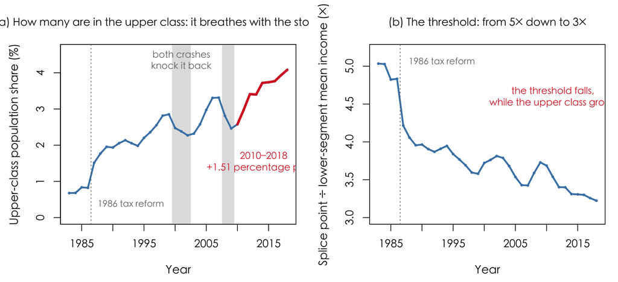

```r
## How the size of the upper class changes year by year. The data are the year-by-year fitted parameters
## Ludwig-Yakovenko released with their paper, CC BY 4.0; see docs/data-external/ATTRIBUTION.md for source and license.
## Mind the directory split: docs/data/ holds only results this essay knits itself (compared cell by cell against the baseline),
## while docs/data-external/ is external read-only data; the two must not be mixed.
stopifnot(file.exists("docs/data-external/ludwig-yakovenko-2022-params.csv"))
ucgLY <- utils::read.csv("docs/data-external/ludwig-yakovenko-2022-params.csv")
names(ucgLY)[1] <- "year"
ucgLY$fp_pct <- 100*ucgLY$fp                     # upper-class population share, %
ucgLY$kT     <- ucgLY$rstar/ucgLY$T                 # the splice point as a multiple of the lower segment's mean income
ucg_gy <- function(y, col) ucgLY[[col]][match(y, ucgLY$year)]

## The retreat after two crashes, and the gains over three windows—all computed here; the text cites only registered values.
ucg_win <- function(a, b) c(from = ucg_gy(a,"fp_pct"), to = ucg_gy(b,"fp_pct"),
                        d = ucg_gy(b,"fp_pct") - ucg_gy(a,"fp_pct"),
                        per = (ucg_gy(b,"fp_pct") - ucg_gy(a,"fp_pct"))/(b - a))
ucg_w80 <- ucg_win(1983, 1990); ucg_w00 <- ucg_win(2000, 2010); ucg_w10 <- ucg_win(2010, 2018)
## Self-check: the 2010s must be the window with the largest absolute gain, and the 2000s nearly flat—two sentences of the text rest on this.
stopifnot(ucg_w10["d"] > ucg_w80["d"], ucg_w10["d"] > ucg_w00["d"], ucg_w00["d"] < 0.2)

ucg_A <- "#D62728"; ucg_B <- "steelblue"; ucg_G <- "gray45"; ucg_SH <- "gray88"
par(mfrow = c(1, 2), mar = c(4.4, 4.6, 3.4, 1.0), cex.lab = 1.05, cex.main = 1.0,
    family = "cjk")

## (a) Upper-class population share: both crashes knock it back; after 2010 comes the steepest stretch
plot(ucgLY$year, ucgLY$fp_pct, type = "n", xlab = "Year", ylab = "Upper-class population share (%)",
     main = "(a) How many are in the upper class: it breathes with the stock market", ylim = c(0, 4.6))
rect(1999.5, -1, 2002.5, 9, col = ucg_SH, border = NA)     # dot-com bust
rect(2007.5, -1, 2009.5, 9, col = ucg_SH, border = NA)     # global financial crisis
box()
lines(ucgLY$year, ucgLY$fp_pct, lwd = 2.6, col = ucg_B)
points(ucgLY$year, ucgLY$fp_pct, pch = 16, cex = 0.55, col = ucg_B)
ucg_seg <- ucgLY$year >= 2010
lines(ucgLY$year[ucg_seg], ucgLY$fp_pct[ucg_seg], lwd = 3.6, col = ucg_A)
text(2001, 4.35, "both crashes\nknock it back", col = ucg_G, cex = 0.85)
text(2014.2, 1.55, sprintf("2010–2018\n+%.2f percentage points", ucg_w10["d"]), col = ucg_A, cex = 0.88)
text(1986.5, 0.35, "1986 tax reform", col = ucg_G, cex = 0.82, pos = 4)
abline(v = 1986.5, lty = 3, col = ucg_G)

## (b) The threshold: the splice point as a multiple of lower-segment mean income, falling all the way
plot(ucgLY$year, ucgLY$kT, type = "n", xlab = "Year", ylab = "Splice point ÷ lower-segment mean income (×)",
     main = "(b) The threshold: from 5× down to 3×", ylim = c(3, 5.2))
lines(ucgLY$year, ucgLY$kT, lwd = 2.6, col = ucg_B)
points(ucgLY$year, ucgLY$kT, pch = 16, cex = 0.55, col = ucg_B)
abline(v = 1986.5, lty = 3, col = ucg_G)
text(1986.8, 5.05, "1986 tax reform", col = ucg_G, cex = 0.82, pos = 4)
text(2011, 4.6, "the threshold falls,\nwhile the upper class grows", col = ucg_A, cex = 0.88)
```

```r
for (y in c(1999, 2002, 2007, 2009)) reg(paste0("fp_", y), ucg_gy(y, "fp_pct"), "derived",
  "§6.1.3 upper_class_growth", paste("US upper-class population share %", y, "(Ludwig-Yakovenko yearly parameters)"))
reg("fp_w80_d",  ucg_w80["d"],   "derived", "§6.1.3 upper_class_growth", "1983-1990 gain in upper-class population share, pp")
reg("fp_w80_per",ucg_w80["per"], "derived", "§6.1.3 upper_class_growth", "same, pp per year")
reg("fp_w00_d",  ucg_w00["d"],   "derived", "§6.1.3 upper_class_growth", "2000-2010 gain, pp")
reg("fp_w10_d",  ucg_w10["d"],   "derived", "§6.1.3 upper_class_growth", "2010-2018 gain, pp")
reg("fp_w10_per",ucg_w10["per"], "derived", "§6.1.3 upper_class_growth", "same, pp per year")
reg("fp_1987_jump", ucg_gy(1987,"fp_pct") - ucg_gy(1986,"fp_pct"), "derived",
    "§6.1.3 upper_class_growth", "the 1986->1987 jump, pp, coinciding with the Tax Reform Act of 1986")
```

Three things can be read directly off the figure.

1. Both crashes knocked the upper-class share back down—2.85% (1999) fell to 2.27% (2002), and 3.31% (2007) fell to 2.46% (2009). People do not “leave the bourgeoisie” in a bear market—what falls is realized capital gains in AGI. This line measures a flow, and it is highly sensitive to the market.
2. 2010–2018 is the window with the largest absolute gain in the whole series: 1.51 percentage points, 0.19 points per year, while the decade from 2000 to 2010 is nearly flat (0.10 points). The 1980s wave ran at a comparable 0.18 points per year, but it contains a jump of 0.69 points from 1986 to 1987, landing exactly on the Tax Reform Act of 1986—that looks more like a change in reporting behavior than a change in the economy. On that reading, the 2010s are the most substantial expansion in these thirty-six years, and it happens to cover the decade-plus bull run in US equities.

Put the tax rates alongside it and the shape of the 1986→1987 jump becomes clearer. The top US marginal rate was 70% from 1965 to 1980 (with earned income separately capped at 50% from 1972 to 1981, so that 70% fell mainly on unearned income), 69.125% in 1981, down to 50% in 1982, 38.5% in 1987, and 28% in 1988 (Wilson 2002)—from 70% to 28% in eight years. The doubling of the upper-class share falls exactly in the first year the Tax Reform Act of 1986 took effect.

But the reading “high tax rates held inequality down” fails one piece of arithmetic. The $G=(1+f)/2$ of §2.6 is $\ge 0.5$ by construction: however small the top share $f$, the Gini can only approach 0.5, never fall below it. Yet the measured value in 1983–1986 is indeed below 0.5. So the low Gini of those years cannot be only the top being flattened by tax—either the body itself is more even than an exponential, or the top’s income never entered the tax-reporting base at all.

The second is more likely true, and it does not say “the distribution changed”. At a 70%/50% rate, the rational response for high incomes is to keep income from being realized in taxable form: deferred compensation, profits left inside the company, conversion into capital gains, various structures. Once the rate fell to 38.5%, that income was again worth reporting—so the tax data suddenly show a new batch of “upper class” who did not become rich that year. This is exactly why this section treats the jump as reporting behavior rather than economic change.

This has one direct consequence for how the essay uses the data: measuring the top with tax data measures “how much the top is willing to realize in taxable form”, not “how much the top owns”. 3. The threshold is falling at the same time, the line in the right panel: the splice point drops from 5.03 times the lower-segment mean to 3.22 times.

A natural explanation offers itself: the middle class started buying stocks. In this essay’s framework that guess belongs to the right class—acquiring a multiplicative income stream is exactly how one crosses the splice point. But the data do not support it, for two reasons:

- The timing of participation does not fit. The Federal Reserve’s Survey of Consumer Finances (SCF) reports the share of families holding stock (direct + indirect): 48.8% in 2013, back up to 51.9% in 2016, and even in 2016 the figure had only just passed its 2010 level (Bricker et al. 2017). In the years when the upper class grew fastest, participation was at a low.
- More important is the definition. Most of the middle class’s stock sits in deferred accounts such as 401(k)s and IRAs, and does not enter AGI until withdrawn. So even a real surge in participation would be nearly invisible in this tax data.

One more number in the same SCF says it more plainly: in 2016 the top income group (top 10%) held stock at 93.6%, against 51.9% for all families (Bricker et al. 2017). The answer to “who can invest” is itself extremely unequal—so the more likely reading is not new entrants but existing asset holders cashing out gains in the bull market, and so crossing the splice point in those years.

The original authors offer a third guess, so it belongs here too. They attribute the expansion of the upper class to the digitalization of the economy: platform businesses have a one-to-many topology and can create a set of super-rich that old local businesses could not; at the same time they explicitly attribute the post-2009 spike to quantitative easing, writing that “the Fed’s rescue pushed inequality up” (Ludwig and Yakovenko 2022).

All three explanations point at asset markets, but they land in different places—the middle-class entry story on headcount, the cashing-out story on the flow definition, the digitalization story on how the top is formed. This essay cannot adjudicate among them, so this item still gets no sign. But one thing the figure has settled: the position of this class line is highly sensitive to asset markets, and asset markets are the real-world name of the $\sigma$ knob from Chapter 5.

Second: the larger the line, the wider the distribution. Equal credit lines lift the top 1% share from 7.4% to 9.2%, raise sd/mean from 1.39 to 2.48, and leave 33% of people in debt. Raise the cap further, all the way to removing it, and the stationary state no longer exists: the variance grows without bound over time. This matches Drăgulescu–Yakovenko’s conclusion about debt (Drăgulescu and Yakovenko 2000).

The third is the harshest, and it has nothing to do with how much is borrowed. Compare the last row with the second: the same line $L=1$, and the only difference is what happens after the floor is touched.

- Bounce back (this essay’s setup): 33% of people are in debt but all are still in the game, and positions can change at any time. (Be careful with “turning it around”—the model has no agency; it can say positions change hands, not who changes them or how.)
- Liquidated (margin call, forced close, bankruptcy as exit): 96.6% of people leave permanently, and the top 1% hold 43.7%.

The same credit line, and only the liquidation rule differs, yet the result differs by an order of magnitude. This is the experimental version of the two premises from Chapter 2—“where the wall is” sets how wide the distribution gets, and “whether the wall reflects or absorbs” sets how many people are still in the game. The second is far more destructive than the first.

In one sentence: “whether you can borrow” sets the width of the gap, and “whether you are still a player after you cannot” sets how many people in the society still have a chance. The two institutional designs in the real world—bankruptcy protection and forced liquidation—sit on opposite sides of that line.

## 6.2 Direction Depends on “Is It the Same for Everyone?”: Inheritance, Saving, Inflation, Growth

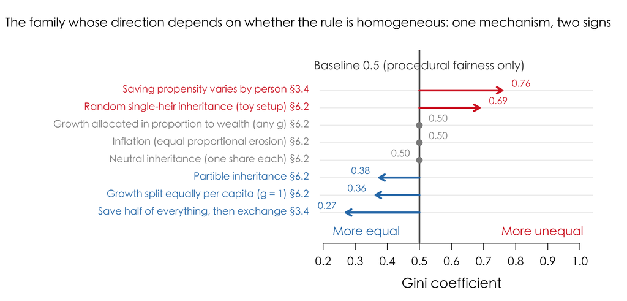

The family above moves in one direction no matter how you tune it. The next three are not like that—their sign is not set by the mechanism itself but by whether the rules are the same for everyone.

Inheritance: the Gini coefficient and mobility are two independent axes. A generation turns over every 300 rounds, and three inheritance rules are compared (measuring one mobility statistic at the same time: the rank correlation of wealth between adjacent generations; the higher it is, the more “hereditary” the society). Both quantities are measured at the moment the inheritance event happens, with the parent’s value taken as that person’s wealth before marriage:

```r
## One generation = 300 rounds of exchange; both the Gini and the intergenerational rank correlation are measured **at the moment the inheritance event happens**
## Parent value = that person's wealth before marriage; children pair 1–1 with parents (under the two-parameter rules each child maps to one parent)
inherit_run <- function(regime, N = 4000, rounds = 300, G = 8, keep = 4, seed = 1){
  set.seed(seed); w <- rep(1, N); half <- N/2; gs <- rhos <- numeric(G)
  for (g in 1:G){
    for (r in 1:rounds){
      idx <- sample.int(N); i <- idx[1:half]; j <- idx[(half+1):N]
      pooled <- w[i] + w[j]; e <- runif(half); w[i] <- e*pooled; w[j] <- (1-e)*pooled
    }
    if (regime == "neutral"){ par_v <- w; ch <- w }
    else {
      idx <- sample.int(N); a <- idx[1:half]; b <- idx[(half+1):N]
      pool  <- w[a] + w[b]
      par_v <- c(w[a], w[b])
      ch <- if (regime == "partible") c(pool/2, pool/2)          # each of the two children gets half
            else if (regime == "random_single_heir"){             # one of the two slots takes everything
                   u <- runif(half) < 0.5
                   c(ifelse(u, pool, 0), ifelse(u, 0, pool)) }
            else stop("unknown regime: ", regime)
    }
    gs[g] <- gini(ch); rhos[g] <- if (regime == "neutral") 1 else cor(rank(par_v), rank(ch))
    w <- ch
  }
  k <- (G - keep + 1):G                                            # drop the initial transient
  c(gini = mean(gs[k]), rho = mean(rhos[k]))
}
INH_R <- 12                                                        # number of independent seeds
INH_raw <- lapply(c("neutral", "partible", "random_single_heir"), function(rg)
  t(sapply(1:INH_R, function(sd) inherit_run(rg, seed = 100 + sd))))
INH <- data.frame(
  regime = c("neutral", "partible", "random_single_heir"),
  gini = sapply(INH_raw, function(m) mean(m[, "gini"])),
  glo  = sapply(INH_raw, function(m) unname(quantile(m[, "gini"], .025))),
  ghi  = sapply(INH_raw, function(m) unname(quantile(m[, "gini"], .975))),
  rho  = sapply(INH_raw, function(m) mean(m[, "rho"])),
  rlo  = sapply(INH_raw, function(m) unname(quantile(m[, "rho"], .025))),
  rhi  = sapply(INH_raw, function(m) unname(quantile(m[, "rho"], .975))),
  stringsAsFactors = FALSE)
## Two self-checks: neutral has rho ≡ 1 by construction; partible inheritance is the mean of two independent exponential variables, so its Gini is 3/8 analytically
stopifnot(INH$rho[1] == 1, abs(INH$gini[2] - 3/8) < 0.01, abs(INH$gini[1] - 0.5) < 0.01)
reg("inherit_neutral", INH$gini[1], "mean", "§6.2 inheritance",
    sprintf("%d seeds; the inheritance map is the identity, so the effect is zero analytically", INH_R), neutral = TRUE)
reg("inherit_partible", INH$gini[2], "mean", "§6.2 inheritance", "analytic value 3/8")
reg("inherit_random_single_heir", INH$gini[3], "mean", "§6.2 inheritance", sprintf("%d seeds", INH_R))
```

| Inheritance rule | Gini coefficient | Intergenerational rank correlation | Reading |
| --- | --- | --- | --- |
| One person inherits one share, unchanged (this essay's baseline) | 0.500 | 1.00 | Positions completely frozen |
| Spouses pool their wealth, children divide equally | 0.375 | 0.67 | Inequality falls, mobility rises |
| Random single heir (toy setup) | 0.687 | 0.18 | Highest inequality, highest mobility too |

(All numbers are means over seeds: 8 generations, the initial transient dropped so only the last 4 generational transitions are kept, 12 independent seeds. The partible row has an analytic solution to check against—the mean of two independent exponential variables has a Gini of exactly $3/8$.)

These three rows overturn a common intuition: “high inequality means a frozen class structure.” The Gini does not pin down class mobility. Partible inheritance pushes the Gini down and mobility up; random single-heir inheritance pushes the Gini to 0.69, and its mobility is the highest of the three rows. A Gini change in one direction can come with the opposite change in mobility, so the Gini cannot measure whether positions change hands at all; that takes another quantity. (The third row’s name should be read literally: the two children are just two paired slots, and one of them takes everything at random. The model has no birth order and no cross-generation identity.)

Now we can go back and settle accounts with the Great Gatsby curve from §4.6. The cross-country data says “the higher the Gini, the lower the class mobility,” and the table above looks like it is arguing the other way. But get the accounting right first: only one of the three rows actually goes in the opposite direction.

- Baseline → partible inheritance: Gini 0.500 → 0.375, intergenerational rank correlation 1.00 → 0.67 (mobility rises). Inequality falls and mobility rises, the same direction as the Great Gatsby curve.
- Baseline → random single heir: Gini 0.500 → 0.687, intergenerational rank correlation 1.00 → 0.18 (mobility rises too). Inequality rises and mobility rises too—the only row that runs against the curve—and it is the only row of the three that hands the whole estate to one person. Wealth is not split, so the child’s position is set by a coin toss and decoupled from the parent’s position; mobility therefore rises rather than falls.

So the impression that “the model fights the Great Gatsby curve” comes largely from an overstated mobility number. Even so, the two can hardly be called contradictory, because they are not statements of the same kind: Corak’s figure is a cross-sectional correlation between societies, while this table is a comparative static within one model that changes a single part; and the vertical axes are not the same thing either—he measures the intergenerational income elasticity, this essay measures the intergenerational rank correlation; the directions are comparable, the values are not.

### 6.2.1 What Exactly Binds Inequality to Intergenerational Mobility?

The model shows that there is no necessary functional relation between the Gini and class mobility, so the clear positive correlation in the cross-country data cannot come from a mechanical link between the two. It must come from some common cause that pushes inequality up and mobility down at the same time. Economics has a mature answer for that common cause, and it runs straight through the lever already measured in §6.1.2.

The Becker–Tomes mechanism, put in testable form by Solon (Becker and Tomes 1979; Solon 2004): parents invest in their children (education, health, time, connections), and the return on that investment depends on the premium society pays for skill. When the skill premium is high, two things happen at once:

1. Inequality rises—the same difference in ability buys a larger difference in income;
2. The incentive to invest rises—but whether you can afford to invest depends on how much money the parents have, because no one can borrow against the child’s future income.

So the single parameter of the skill premium pushes the Gini up and class mobility down at the same time. They are not causes of each other; they are two consequences of one cause.

This mechanism can be run directly. Let the target investment rise with the return $\gamma$, let the child’s income $=A\cdot(1+I)^{1.5}$ ($A$ is an independent ability shock unrelated to the parents), and compare three investment regimes:

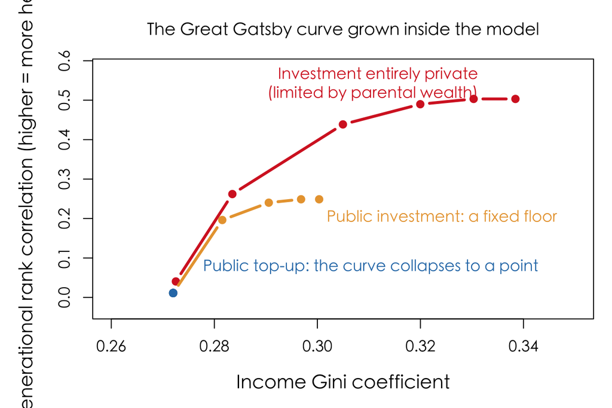

```r
gats <- function(gamma, regime, N = 4000, gens = 15, kappa = 0.6, sda = 0.5, seed = 1){
  set.seed(seed); y <- rep(1, N); Istar <- gamma      # target investment rises with the return
  for (g in 1:gens){
    priv <- pmin(Istar, kappa*y)                      # private: how much you can invest depends on parental wealth
    I <- switch(regime,
                none = priv,                          # entirely private
                floor_ = pmax(0.6, priv),             # public investment: a fixed floor
                full = rep(Istar, N))                 # public investment: tops up to the target
    A <- exp(rnorm(N, 0, sda)); yp <- y               # ability shock unrelated to the parents
    y <- A*(1 + I)^1.5; y <- y/mean(y)
  }
  c(gini = gini(y), rho = cor(rank(yp), rank(y)))
}
gam <- c(0.1, 0.3, 0.6, 1, 1.5, 2.5, 4)
RG  <- lapply(c("none", "floor_", "full"),
              function(rg) t(sapply(gam, function(x) gats(x, rg))))
names(RG) <- c("none", "floor_", "full")

COL <- c(none = "#D62728", floor_ = "#E8A33D", full = "#2C7BB6")
par(mar = c(4.8, 5.0, 3.2, 1.0), cex.lab = 1.22, cex.main = 1.1, family = "cjk")
plot(NA, xlim = c(0.26, 0.35), ylim = c(-0.03, 0.58),
     xlab = "Income Gini coefficient", ylab = "Intergenerational rank correlation (higher = more hereditary)",
     main = "The Great Gatsby curve grown inside the model")
for (nm in names(RG))
  lines(RG[[nm]][, 1], RG[[nm]][, 2], col = COL[nm], lwd = 3, type = "b", pch = 16, cex = 1.2)
text(0.333, 0.53, "Investment entirely private\n(limited by parental wealth)", col = COL["none"], cex = 1.02, pos = 2)
text(0.300, 0.20, "Public investment: a fixed floor", col = COL["floor_"], cex = 1.02, pos = 4)
text(0.276, 0.075, "Public top-up: the curve collapses to a point", col = COL["full"], cex = 1.02, pos = 4)
```

The blue point shows the direction of causation. Remove the constraint that investment is limited by parental wealth—public investment tops every child up to the target—and the whole curve collapses to a point: however high the skill premium, the Gini does not move 0.272, and neither does the intergenerational rank correlation, which stays at 0.01. The machine that translates inequality into low mobility is the link between investment and parental wealth itself, not inequality.

This says the same thing as the credit conclusion in §6.1.2, in two versions: there the measurement was “who can borrow matters more than how much,” here it is “who can afford to invest matters more than how high the skill premium is.” Both times it is a question of eligibility, not of amount.

The orange line is the middle ground, and the closest to reality. A fixed amount of public investment can hold the curve down completely while the skill premium is low; once the premium rises past that amount, private investment opens the gap again and the rank correlation climbs back—only to 0.25 rather than 0.50. Public investment is not a switch but an amount that can be outstripped. This is exactly Solon’s conclusion: intergenerational elasticity falls with “the progressivity of public investment in human capital” (Solon 2004).

### 6.2.2 One More Layer: The Curve’s Vertical Axis Carries Inequality of Its Own

One last thing that is easy to skip. The vertical axis of the Great Gatsby curve is the **intergenerational income elasticity** $\beta$, and it satisfies an identity with the rank correlation $\rho$:

$$\beta \;=\;
\frac{\mathrm{Cov}(y_c,\,y_p)}{\mathrm{Var}(y_p)} \;=\;
\rho\cdot\frac{\sigma_c}{\sigma_p}$$

where $\sigma$ is the cross-sectional standard deviation of log income in each generation, and $\rho$ in this expression must be the **Pearson correlation of log income**, not the rank correlation—the intergenerational rank correlation (Spearman) measured elsewhere in this essay cannot be substituted into this identity, and under nonlinearity the two can differ by more than 20 percent. The vertical axis already contains a ratio of dispersions. So in a country where inequality is rising ($\sigma_c>\sigma_p$), even if the Pearson correlation of log income has not changed at all, the measured $\beta$ will be too high—something from the horizontal axis leaks into the vertical one.

This does not refute the curve—the experiment above shows the mechanism really exists—but it explains why the curve flattens when redrawn as a rank–rank slope, and it confirms the line from §4.6: the IGE is best not used on its own.

Saving is the same story. §3.4 measured it twice: when everyone saves half, the Gini falls from 0.50 to 0.27; when the habit of saving differs across people, the same mechanism pushes the Gini to 0.758. The “same for everyone” version in between is an equalizing force; the “differs across people” version is one of the strongest upward forces—one part, installed two ways, with opposite signs.

Inflation is the cleanest example in this family, and its most immediate answer is “no effect at all.” Each round, everyone’s money loses value in the same proportion $\pi$—mathematically this multiplies the whole distribution by a constant, and the Gini is scale-invariant, so it does not move. The simulated number is exactly the same as the baseline. That is worth remembering: pure inflation is not redistribution.

But inflation in the real world is almost never “pure,” because different people hold different things: the poorer you are, the larger the share of your wealth that is cash and deposits; the richer you are, the more of it is assets that rise in price along with inflation. Add that to the model—only the cash part is eroded, the asset part keeps up—and inflation immediately becomes an upward force.

```r
N <- 2000; half <- N/2
ex <- function(w){ idx <- sample.int(N); i <- idx[1:half]; j <- idx[(half+1):N]
  pooled <- w[i] + w[j]; e <- runif(half); w[i] <- e*pooled; w[j] <- (1-e)*pooled; w }
infl <- function(mode, pi = 0, rounds = 800, seed = 1){
  set.seed(seed); w <- rep(1, N)
  for (r in 1:rounds){
    if (mode == "flat") w <- w*(1 - pi)                 # everyone depreciates in the same proportion
    if (mode == "cash"){ a <- w/(w + 1)                 # asset share rises with wealth
      w <- w*a + w*(1 - a)*(1 - pi) }                   # only the cash part is eroded
    w <- ex(w); w <- w/mean(w)
  }
  gini(w)
}
INF <- c(`Baseline (no inflation)` = infl("none"),
  `Equal proportion, 2%` = infl("flat", 0.02), `Equal proportion, 10%` = infl("flat", 0.10),
  `Cash only, 2%` = infl("cash", 0.02), `Cash only, 10%` = infl("cash", 0.10))
## Proportional depreciation followed by normalization to the mean is an identity—the Gini is exactly unchanged, and no single realization is used
reg("inflation_flat", 0.5, "analytic", "§6.2.2 inflation",
    "same proportion for everyone: w(1-π) is identical digit for digit after normalization", neutral = TRUE)
INF
```

```
## Baseline (no inflation)    Equal proportion, 2%   Equal proportion, 10%
##               0.4879929               0.4879929               0.4879929
##           Cash only, 2%          Cash only, 10%
##               0.4904460               0.5015007
```

So the accurate version of the popular claim that “inflation hurts the poor more” is this: inflation itself is neutral, and the structure of holdings is what makes it non-neutral. The same structural difference also works in reverse—inflation dilutes debt, a net gain for people who owe. The direction still depends on the old question: is it the same for everyone?

Growth: making the pie bigger changes nothing by itself. This is the most counterintuitive item in the family, because “grow the pie” is usually taken as the cure for inequality. Put it in the model: each round, grow by $g$ first, then exchange as usual, changing only how the increment is divided.

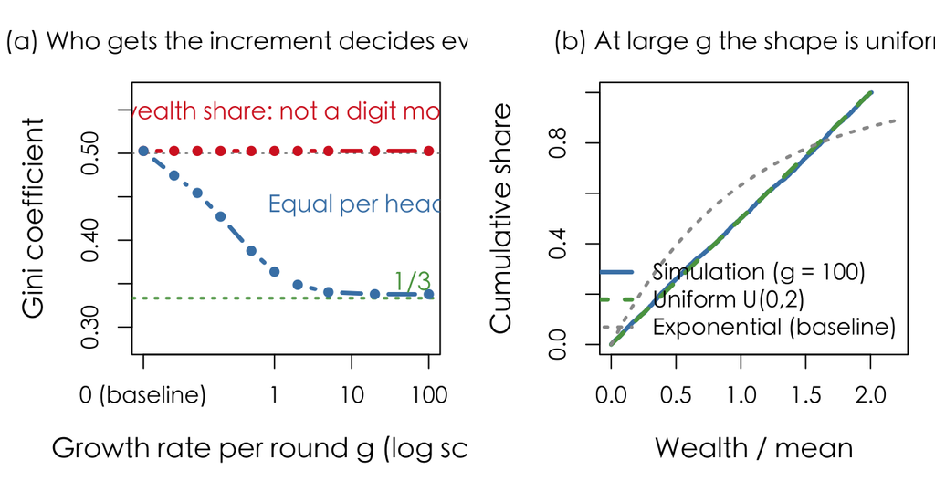

```r
grow <- function(rule, g, N = 4000, rounds = 1200, seed = 1){
  set.seed(seed); w <- rep(1, N); half <- N/2
  for (r in 1:rounds){
    if (rule == "prop") w <- w*(1 + g)        # increment divided in proportion to each person's wealth
    if (rule == "flat") w <- w + g*mean(w)    # increment divided equally per head
    idx <- sample.int(N); i <- idx[1:half]; j <- idx[(half+1):N]
    pooled <- w[i] + w[j]; e <- runif(half)
    w[i] <- e*pooled; w[j] <- (1-e)*pooled
    w <- w/mean(w)                            # only to prevent overflow; the Gini is scale-invariant
  }
  w
}
gs <- c(0, 0.05, 0.1, 0.2, 0.5, 1, 2, 5, 20, 100)
Gp <- sapply(gs, function(g) gini(grow("prop", g)))
Gf <- sapply(gs, function(g) gini(grow("flat", g)))
w100 <- grow("flat", 100)

ACC <- "#D62728"; BLU <- "steelblue"; GRN <- "#59A14F"
par(mfrow = c(1, 2), mar = c(4.6, 4.8, 3.0, 1.0), cex.lab = 1.2, cex.main = 1.08,
    family = "cjk")
xs <- pmax(gs, 0.02)
plot(NA, xlim = range(xs), ylim = c(0.28, 0.57), log = "x", xaxt = "n",
     xlab = "Growth rate per round g (log scale)", ylab = "Gini coefficient", main = "(a) Who gets the increment decides everything")
axis(1, at = c(0.02, 1, 10, 100), labels = c("0 (baseline)", "1", "10", "100"))
abline(h = 0.5, lty = 3, col = "gray50"); abline(h = 1/3, lty = 3, col = GRN, lwd = 2)
reg("growth_prop", 0.5, "analytic", "§6.2.2 growth_rules",
    "multiplying everyone by (1+g) only changes units; the Gini is scale-invariant, identical digit for digit", neutral = TRUE)
reg("growth_flat", Gf[which(gs == 1)], "point", "§6.2.2 growth_rules", "g = 1; the g→∞ limit is 1/3")
lines(xs, Gp, col = ACC, lwd = 3, type = "b", pch = 16)
lines(xs, Gf, col = BLU, lwd = 3, type = "b", pch = 16)
text(0.55, 0.547, "Split by wealth share: not a digit moves", col = ACC, cex = 1.05)
text(12, 0.44, "Equal per head", col = BLU, cex = 1.05)
text(60, 0.352, "1/3", col = GRN, cex = 1.1)

u <- sort(w100/mean(w100)); pp <- seq_along(u)/length(u)
plot(u, pp, type = "l", col = BLU, lwd = 3, xlim = c(0, 2.2),
     xlab = "Wealth / mean", ylab = "Cumulative share", main = "(b) At large g the shape is uniform")
lines(c(0, 2), c(0, 1), col = GRN, lwd = 3, lty = 2)
xe <- seq(0, 2.2, length.out = 200); lines(xe, 1 - exp(-xe), col = "gray60", lwd = 2.4, lty = 3)
legend("bottomright", c("Simulation (g = 100)", "Uniform U(0,2)", "Exponential (baseline)"),
       col = c(BLU, GRN, "gray60"), lwd = c(3, 3, 2.4), lty = c(1, 2, 3), bty = "n", cex = 1.0)
```

Split by wealth share: the Gini does not move a single digit. Turn $g$ from 0 to 100 and the Gini stays at 0.503—not “changes very little” but identical digit for digit. The reason takes one line: multiplying everyone by $(1+g)$ only changes units, and the Gini is scale-invariant. Growing a hundredfold and not growing at all give exactly the same distribution shape.

Split equally per head: it pushes the Gini down monotonically, but stops at 1/3. The larger $g$ is, the harder the push, from 0.503 all the way down to 0.338, and after that no further increase moves it.

This 1/3 is not a property of growth but of exchange itself. Take a group of people with exactly equal wealth, pair them at random, pool each pair’s money and split it at random—after one round the distribution is uniform, and the Gini of a uniform distribution is exactly $1/3$. The right panel confirms it: the cumulative curve at $g=100$ (blue) sits almost on top of the uniform’s straight line (green), far from the baseline exponential (gray). Redistribution can flatten the input, but it cannot stop exchange from spreading it out again.

This also explains something we will run into later: the tax experiment in §6.3 has the same lower bound of 1/3. The money comes from completely different sources—one printed, one taxed—but mathematically it is the same operation: add the same constant to everyone’s wealth.

(The third division—in proportion, but with random returns—is the $\sigma$ knob of Chapter 5, already measured: $\sigma=0.6$ gives a Gini of 0.67, $\sigma=1.2$ gives 0.92. So growth can go in all three directions.)

Set the three side by side and the pattern appears:

| Mechanism | When the same for everyone | When it differs by person / by rule | The other direction |
| --- | --- | --- | --- |
| Saving | ↓ 0.27 (everyone saves half) | ↑ 0.758 (heterogeneous saving propensities) | — |
| Inheritance | → 0.50 (one person, one share) | ↑ 0.69 (random single heir) | ↓ 0.375 (partible inheritance) |
| Growth | → 0.50 (by wealth share, unmoved) | ↑ 0.92 (returns with fluctuations) | ↓ 0.36 (equal per head, g = 1; limit 1/3) |

This family is where Rousseau’s chain really sits. He said inequality comes from private property and law; here we can put it more precisely: it is not whether these institutions exist but whether they are the same for everyone. When the rule is homogeneous they are neutral or even equalizing; once it differs by person, the same institution becomes the strongest amplifier.

## 6.3 The Knob You Can Turn: Redistribution, and Its Two Directions

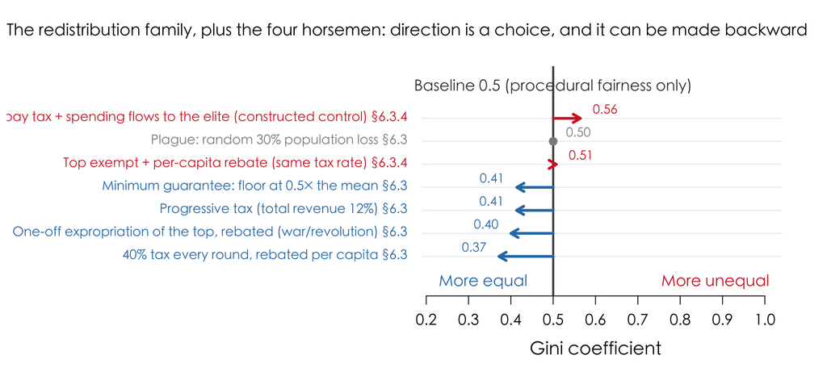

Every mechanism so far has described what the world is like; this one asks what we can make of it. The simplest version: each round, levy a share $\tau$ in proportion to wealth, and return the proceeds equally per capita.

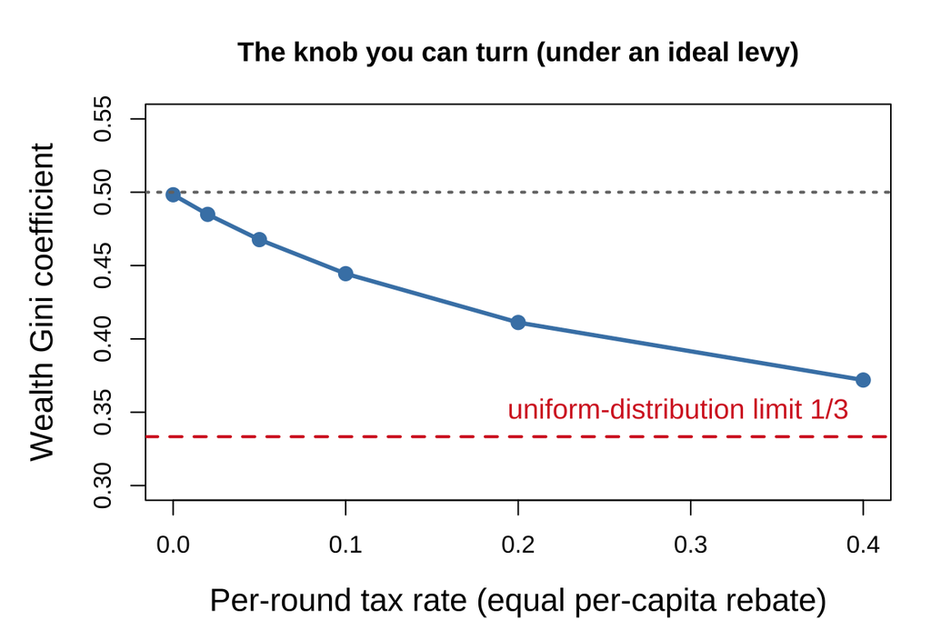

```r
taus <- c(0, 0.02, 0.05, 0.1, 0.2, 0.4)
g_tx <- sapply(taus, function(x) run1(mode = "tax", p = x))
reg("tax_tau_max", max(taus), "analytic", "§6.3 tax_sweep", "top bracket of the tax-rate sweep (gross levy rate)")
## The exponential's Pietra index has the closed form 1/e; net transfer share = gross levy rate x Pietra
reg("tax_net_max", 100*max(taus)*exp(-1), "derived", "§6.3 tax_sweep", "net transfer as a percentage of total wealth at the top bracket")

par(mar = c(4.8, 5.0, 3.6, 1.4), cex.lab = 1.32, cex.main = 1.12)
plot(taus, g_tx, type = "o", pch = 16, cex = 1.4, lwd = 2.8, col = "steelblue",
     ylim = c(0.3, 0.55), xlab = "Per-round tax rate (equal per-capita rebate)", ylab = "Wealth Gini coefficient",
     main = "The knob you can turn (under an ideal levy)")
abline(h = 0.5, lty = 3, lwd = 2, col = "gray45")
abline(h = 1/3, lty = 2, lwd = 2, col = ACC)
text(0.4, 0.35, "uniform-distribution limit 1/3", col = ACC, cex = 1.15, pos = 2)
```

```r
reg("tax40", g_tx[6], "point", "§6.3 tax_sweep", "levy 40% per round, returned per capita (6th bracket of taus)")
```

Taxation: it pushes inequality down, but not to zero. Levy a share $\tau$ each round and return it per capita, and the Gini falls from 0.498 all the way to 0.372 at $\tau=0.4$. The direction is right, but two accounting points must be clarified first, or this curve will be read as a conclusion it does not make.

First, the phase at which it is measured. Each round, `run1()` levies and rebates first, then performs one random exchange, and reports the Gini after the exchange. So the $1/3$ here is not the floor of redistribution’s power; it is the fixed point of the composite operation “redistribution plus one exchange”: at $\tau=1$ the Gini immediately after redistribution is 0 (everyone receives the mean), and the pool-and-split that follows pushes it back to $1/3$. What really cannot be pushed down is not the tax but the exchange that happens right after it. This hits the same limit as the per-capita shared growth in Chapter 6, because mathematically the two are the same operation.

Second, the cost is not merely steep: under this composite operation no admissible tax rate can push the Gini below 0.3 at all. The binding limit is the 1/3 left by the exchange that follows, not the tax.

### 6.3.1 Universal Cash Transfers: Is That the Same Thing as a Tax?

Yes, but it depends where the money comes from—and both sources lead to the same limit.

First: a tax-funded UBI. Tax proportionally, then pay out an equal amount per capita—this is not merely similar to the $\tau$ at the start of this section—it is the same operation: take a share proportionally, then hand it back equally. So its effect, its cost, and its floor have all been measured above: at $\tau=0.4$ the Gini is 0.372, and the floor is $1/3$.

Second: a money-financed UBI. No tax; simply issue new money and pay it out per capita. In the model this corresponds to the row in §6.2—“per-capita shared growth”—which in measurement pushes the Gini down to 0.36, again with a floor of $1/3$.

The two roads hit the same number at their limit, and that is no coincidence. Whether the money is levied from above or printed from below, as long as it is split equally per capita it does the same thing: inject an identical constant into everyone’s wealth. And repeatedly injecting the same constant pushes the distribution toward “one random split of the sum of two people”—that is, the uniform distribution, with Gini $1/3$.

> Every operation that “splits equally per capita” is the same operation mathematically. What differs is not the effect but where the money comes from.

But the second has a side effect the first lacks, and it points the other way: printing money brings inflation. The previous section just said that pure proportional inflation is completely neutral—that part does not affect the conclusion; but once inflation erodes cash rather than assets, it becomes an upward force that partly offsets the equalizing effect of the cash transfer. The net effect depends on which of these forces is stronger, and that depends on what the poor and the rich each hold—which brings us back to the old saying.

A final boundary of this model: it only computes distribution. In reality, tax financing and money printing affect output quite differently (one changes incentives, the other changes prices), and this essay’s model has no production at all, so it cannot answer that layer.

### 6.3.2 Another Lever: Raise the Floor (Minimum Guarantee)

Taxation takes “from above”; there is also “support from below”: set a floor $w_{\min}$, top anyone who falls below it back up to the line, and finance this by taxing everyone in proportion to wealth. In the language of Chapter 2, this raises the reflecting wall from 0 to $w_{\min}$.

```r
floor_run <- function(mode, p, rounds = 800, seed = 1){
  set.seed(seed); w <- rep(1, N); moved <- 0
  for (r in 1:rounds){
    if (mode == "tax"){ tx <- p*w; moved <- moved + sum(abs(tx - sum(tx)/N))/2
                        w <- w - tx + sum(tx)/N }
    else { mn <- p*mean(w); need <- pmax(mn - w, 0); moved <- moved + sum(need)
           if (sum(need) > 0){ w <- w + need; w <- w - sum(need)*w/sum(w) } }
    w <- ex(w); w <- w/mean(w)
  }
  c(gini = gini(w), moved = moved/rounds/N)
}
FL <- cbind(`Universal tax 5%`  = floor_run("tax", 0.05),  `Universal tax 15%` = floor_run("tax", 0.15),
            `Floor 0.3×`  = floor_run("floor", 0.3), `Floor 0.5×`  = floor_run("floor", 0.5))
reg("floor_05", FL["gini", "Floor 0.5×"], "point", "§6.3.2 wage_floor", "the floor is set at 0.5 times the mean")
```

| Scheme | Transfer per round / per capita | Gini coefficient |
| --- | --- | --- |
| Universal tax 5% | 0.017 | 0.460 |
| Universal tax 15% | 0.047 | 0.421 |
| Floor 0.3× | 0.031 | 0.449 |
| Floor 0.5× | 0.076 | 0.414 |

The floor does push inequality down, and substantially: with the floor at half the mean, the Gini falls to 0.414. But rank the two by effect per unit transferred and something counterintuitive appears: per dollar moved, a targeted floor does not buy more Gini reduction than a universal tax—if anything, slightly less.

Two accounting points need stating here, and both make the floor look more expensive than it is. First, in the transfer-per-round column, the tax schemes are measured **net** (only the half that actually crosses the mean line) while the floor is measured **gross** (the total subsidy); the two are on different bases. Put both on a net basis and the floor’s cost falls by about fifteen percent, though the ranking does not change. Second, the four schemes transfer different amounts to begin with, so this is not an equal-cost comparison but a comparison of efficiency ratios. The floor is also not a hard constraint: the subsidy is financed by a wealth-proportional levy on everyone, including those just lifted above the line, so the financing step pushes some of them back below it (with $w_{\min}$ at half the mean, about forty percent end up back below)—what it delivers is a transfer tilted toward the bottom, not an actual floor.

The reason is not hard: the floor only lifts the very bottom up to the line, spending everything on the lower end of the distribution, while a universal tax subsidizes the bottom and compresses the top at the same time. The Gini is sensitive to the whole distribution; fix one end and the other stays as it was.

This carries a direct implication for policy debate: “targeted poverty alleviation” and “universal redistribution” are not comparable for reducing absolute poverty—the former is plainly more efficient; but if the stated goal is “lower the Gini coefficient,” targeting need not dominate. Define the objective differently and the optimal instrument differs. (Of course, this essay computes only one objective function, the Gini, and it is not the same as social welfare.)

### 6.3.3 A Note on Definitions: τ in the Model Is Not a “Tax Rate”

The curve above is easily read as “raise the tax rate and the Gini comes down,” but it says something else. First separate two quantities inside the model. The $\tau$ in the code is the **gross levy rate**: each person is taxed $\tau w$, and the proceeds are returned per capita. What actually moves from above the mean to below it is the **net transfer rate**, equal to $\tau P$, where $P$ is the Pietra index before the transfer ($P=1/e\approx0.37$ under the exponential). So $\tau=$ 0.4 nominally takes forty percent, while the net transfer is only about 15% of total wealth—the number on the horizontal axis is far larger than the money it actually moves.

One layer further out, converting a statutory tax rate into the model’s $\tau$ means passing through three things: what the tax base is, what shape the effective tax rate takes along the wealth distribution, and who receives the revenue.

The second matters most. In the real world the effective tax rate is not monotonically increasing in wealth: labor income and capital gains follow different rules, and the effective rate at the top can easily be lower than near the median—which is what the widely repeated line “the rich pay a lower rate than their secretaries” refers to. Put this directly into the model: hold total revenue fixed and change only the method of levy.

```r
tax_run <- function(mode, tau, N = 1500, rounds = 400, seed = 1){
  set.seed(seed); w <- rep(1, N); half <- N/2; rev_tot <- 0
  for (r in 1:rounds){
    q <- quantile(w, c(0.2, 0.9))
    rate <- switch(mode,
      flat = rep(tau, N),                                 # everyone at the same rate
      mid  = ifelse(w > q[1] & w < q[2], tau, 0),          # levy only on the middle segment
      prog = tau * pmin(w/mean(w), 3))                     # progressive: rate rises with wealth, capped at 3x
    tx <- pmin(rate, 0.9)*w; rev_tot <- rev_tot + sum(tx)
    w <- w - tx + sum(tx)/N                                # collected revenue returned per capita
    idx <- sample.int(N); i <- idx[1:half]; j <- idx[(half+1):N]
    pooled <- w[i] + w[j]; e <- runif(half); w[i] <- e*pooled; w[j] <- (1-e)*pooled
  }
  c(gini = gini(w), rev = rev_tot/rounds/N)
}
## Equalize total revenue across the three levies (about 12% of total wealth per round), then compare Ginis
fit_tau <- function(mode) uniroot(function(t) tax_run(mode, t)["rev"] - 0.12, c(0.01, 0.8))$root
modes <- c("prog", "flat", "mid"); taus <- sapply(modes, fit_tau)
out   <- sapply(seq_along(modes), function(k) tax_run(modes[k], taus[k]))
reg("tax_progressive", out["gini", 1], "point", "§6.3.3 tax_design", "total revenue equalized to 12% of total wealth per round")
```

| Levy | Statutory rate | Total revenue | Gini coefficient | Drop from baseline |
| --- | --- | --- | --- | --- |
| Progressive: rate rises with wealth | 7.7% | 12% | 0.413 | 0.087 |
| Proportional: same rate for everyone | 12.0% | 12% | 0.437 | 0.063 |
| Only the middle segment | 18.6% | 12% | 0.471 | 0.029 |

With the same total revenue, a threefold difference in effect: the progressive levy lowers the Gini by about 0.09, while “only the middle segment” lowers it by just 0.03—almost as if no tax had been levied at all. More striking is the statutory rate: the middle-only scheme has to set the highest rate (19% against the progressive 8%) to raise the same money. A higher rate and less redistribution can hold at the same time.

One more point, easier to confuse: taxes and debt point in different directions. The top sometimes funds public finance not by paying tax but by buying government bonds. But the two are different things for the distribution:

- A tax is a transfer: money moves from one person’s hands to another’s, $\tau > 0$.
- Debt is a loan: principal must be repaid, and interest paid too. It does not reduce the top’s wealth stock; it pays the top a return in proportion to holdings—in this essay’s language, exactly “an increment distributed in proportion to wealth,” the Gini-neutral gray dot in the master figure (if interest also carries fluctuations from a risk premium, it slides toward the family that pushes the Gini up).

So counting “buying government bonds” as “supporting the state” is not wrong, but it does not enter $\tau$. Confusing the two systematically overstates the actual strength of redistribution.

Put the two together and the curve in this section finds its place: it is a reference design, not an upper bound. It is not an upper bound because, at equal total revenue, the progressive levy (0.413) pushes lower than the same rate for everyone (0.437)—a proportional tax is not the limit of what equalization can reach. Its point is that it assumes the ideal levy: everyone at the same rate, the full amount collected, returned per capita. Real tax systems at the same total revenue land noticeably further right—the next section gives an example where even the sign flips. Add the floor of $1/3$, and pushing the Gini below 0.3 through taxation alone is essentially infeasible within this mechanism.

### 6.3.4 The End You Cannot Tax

The previous section compared three methods of levy at equal total revenue and concluded that “a higher rate and less redistribution can hold at the same time.” But those three share an unspoken premise: the tax base covers everyone. In practice the most common failure is not in the rate schedule but in who is left out of the tax base entirely.

This layer can be called **effective tax-base coverage**. It has at least four sources, whose counterfactuals and remedies all differ, and they should not be lumped under one word:

| Source | What it looks like | Example |
| --- | --- | --- |
| Statutory scope | Certain statuses or types of income are written outside the base | Exemption for privileged estates; gains from personal transfers of listed shares are 'temporarily exempt' |
| Timing of realization | Wealth rises but does not count as 'realized,' so no taxable event occurs | Unrealized gains are not taxed; borrowing against pledged assets is not a taxable event |
| Avoidance and evasion | Move the base to where it cannot be taxed | Cross-border transfer pricing; sham registration of land under another's name, false cadastral returns |
| Administrative capacity | The state sees only the nominal quota, not the actual collection | Under tax farming the over-collection is open-ended, and the middleman keeps the excess |

In practice the four sources operate separately, and they do not act only on the top. The experiment below simulates just one construct—writing “the top is not in the base” directly as a switch, and watching what it does to the distribution. This is one shared projection of the four sources into the model, not a reconstruction of them.

Design: tax-base coverage × spending incidence, 2×2. The elite beneficiary group is defined independently of the exempt group (the top 10% by current wealth); otherwise the cell “full base × spending to the elite” would not exist, and the levy effect could not be separated from the spending effect.

The main result is not the absolute Gini but the **paired difference** $\Delta G = G_{\text{treated}} - G_{\text{no tax}}$: run the same set of seeds once with the tax and once without, then subtract. The reason is that at finite size the no-tax baseline itself fluctuates around $1/2$, so the theoretical value is not a good enough threshold.

Both panels must be shown, because they control different things:

- Panel A: a common 12% rate in all four cells. The rate is fixed and only base coverage and spending incidence change—only this panel truly isolates the mechanism. The cost is that total revenue falls as exemption rises.
- Panel B: total revenue equalized to 12% cell by cell. Comparable with the previous section, but the exempt cells are forced to a higher rate, so “change only the base” does not hold in B.

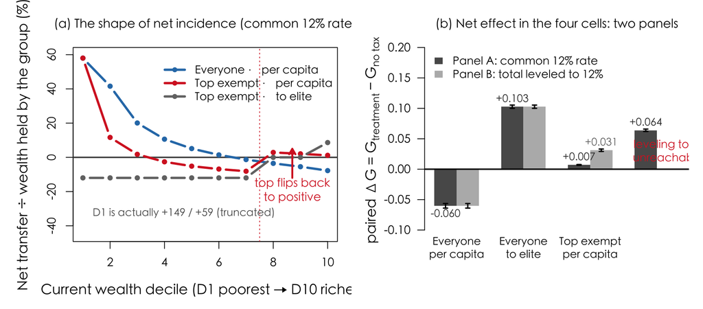

```r
tax2 <- function(tau = 0.12, exempt = 0, flow = "percapita", kind = "rank",
                 N = 1200, rounds = 400, burn = 100, seed = 1){
  set.seed(seed); w <- rep(1, N); half <- N/2; E <- rep(FALSE, N); D <- 10
  pay <- rec <- wt <- numeric(D); rev_tot <- 0; occ <- numeric(0); nE <- round(exempt*N)
  for (r in 1:rounds){
    if (r == burn && exempt > 0){                       # set status only after burn-in reaches the baseline
      if (kind == "perm")  E[order(w, decreasing = TRUE)[1:nE]] <- TRUE
      if (kind == "caste") E[sample.int(N, nE)] <- TRUE
    }
    if (r >= burn && tau > 0){
      if (kind == "rank" && exempt > 0){ E[] <- FALSE
        E[order(w, decreasing = TRUE)[1:nE]] <- TRUE }  # reselect each round by current wealth
      el <- order(w, decreasing = TRUE)[1:round(0.10*N)]  # elite beneficiary group: independent of E
      d  <- ceiling(rank(w, ties.method = "first")/N*D)
      tx <- ifelse(E, 0, tau)*w; rv <- sum(tx); rev_tot <- rev_tot + rv
      tr <- if (flow == "percapita") rep(rv/N, N) else { v <- numeric(N); v[el] <- rv/length(el); v }
      pay <- pay + tapply(tx, factor(d, 1:D), sum)
      rec <- rec + tapply(tr, factor(d, 1:D), sum)
      wt  <- wt  + tapply(w,  factor(d, 1:D), sum)
      w <- w - tx + tr
      if (any(E)) occ <- c(occ, mean(rank(w)[E] > N*0.9))  # share of the exempt group occupying the top 10%
    }
    idx <- sample.int(N); i <- idx[1:half]; j <- idx[(half+1):N]
    p <- w[i] + w[j]; e <- runif(half); w[i] <- e*p; w[j] <- (1-e)*p
  }
  list(gini = gini(w), rev = rev_tot/(rounds-burn+1)/N, inc = 100*(rec-pay)/wt, occ = occ)
}
CAL <- 1:3; SEEDS <- 1:8; TARGET <- 0.12                  # different seeds for calibration and for reporting
mrev <- function(t, ex, fl, sd) mean(unlist(parallel::mclapply(sd, function(s)
          tax2(tau = t, exempt = ex, flow = fl, seed = s)$rev,
          mc.cores = min(.PAR, length(sd)))))
## Calibrate cell by cell: scan [0,1] to check reachability and uniqueness, then root-find; mark NA if unreachable
fit <- function(ex, fl){
  if (ex == 0) return(TARGET)                             # with everyone taxed, revenue is exactly tau (analytic)
  gr <- seq(0.02, 0.98, length.out = 9)
  ## Flatten the 9x3 grid of calls into one parallel layer, avoiding nested mclapply
  gs <- expand.grid(s = CAL, t = gr)
  rv <- unlist(parallel::mclapply(seq_len(nrow(gs)), function(k)
          tax2(tau = gs$t[k], exempt = ex, flow = fl, seed = gs$s[k])$rev, mc.cores = .PAR))
  rr <- apply(matrix(rv, nrow = length(CAL)), 2, mean)
  cross <- which(diff(sign(rr - TARGET)) != 0)
  if (length(cross) != 1) return(NA_real_)                # unreachable or non-unique
  uniroot(function(t) mrev(t, ex, fl, CAL) - TARGET, gr[c(cross, cross+1)])$root
}
cells <- expand.grid(exempt = c(0, 0.30), flow = c("percapita", "elite"),
                     stringsAsFactors = FALSE)
cells$tauB <- mapply(fit, cells$exempt, cells$flow)
G0 <- unlist(parallel::mclapply(SEEDS, function(s) tax2(tau = 0, seed = s)$gini, mc.cores = .PAR))
run_cells <- function(tv) t(mapply(function(ex, fl, tt){
  if (is.na(tt)) return(c(dG = NA, lo = NA, hi = NA, rev = NA))
  o <- parallel::mclapply(SEEDS, function(s) tax2(tau = tt, exempt = ex, flow = fl, seed = s),
                          mc.cores = .PAR)
  d <- sapply(o, `[[`, "gini") - G0; n <- length(d)
  c(dG = mean(d), lo = mean(d) - qt(.975, n-1)*sd(d)/sqrt(n),
    hi = mean(d) + qt(.975, n-1)*sd(d)/sqrt(n), rev = mean(sapply(o, `[[`, "rev")))
}, cells$exempt, cells$flow, tv))
B <- run_cells(cells$tauB)                                # Panel B: total leveled to 12% cell by cell
A <- run_cells(rep(TARGET, 4))                            # Panel A: common 12% rate in all four cells
## cells is generated by expand.grid(exempt=c(0,0.30), flow=c("percapita","elite"));
## the first factor in expand.grid varies fastest, so the row order is:
## 1 everyone/per-capita  2 top exempt/per-capita  3 everyone/to elite  4 top exempt/to elite
## (matches the label order under ord <- c(1,3,2,4) below)
## The master-figure line "non-exempt taxed + spending to elite" = top exempt AND to elite = row 4.
stopifnot(nrow(cells) == 4, cells$exempt[4] == 0.30, cells$flow[4] == "elite",
          cells$exempt[2] == 0.30, cells$flow[2] == "percapita")
reg("cov_elite",  mean(G0) + A[4, "dG"], "derived", "§6.3.4 tax_coverage",
    "no-tax baseline mean(G0) plus the paired effect dG measured in panel A")
reg("cov_exempt", mean(G0) + A[2, "dG"], "derived", "§6.3.4 tax_coverage", "same as above")
## Three versions of the status definition (same exemption share, same rate), testing whether "exemption keeps tracking wealth"
KIND <- sapply(c("rank","perm","caste"), function(k){
  o <- parallel::mclapply(SEEDS, function(s) tax2(tau = TARGET, exempt = 0.30, kind = k, seed = s),
                          mc.cores = .PAR)
  c(dG = mean(sapply(o, `[[`, "gini") - G0),
    occ0 = mean(sapply(o, function(x) x$occ[1])),
    occ1 = mean(sapply(o, function(x) x$occ[length(x$occ)])))
})
## All three net-incidence lines use the common 12% rate (panel A), so rate differences do not enter the shape
INC <- list(tax2(TARGET, 0,    "percapita")$inc,
            tax2(TARGET, 0.30, "percapita")$inc,
            tax2(TARGET, 0.30, "elite")$inc)
UP <- "#D62728"; DN <- "#2C7BB6"; GY <- "gray45"; COL <- c(DN, UP, GY)
par(mfrow = c(1, 2), mar = c(4.8, 5.2, 3.4, 1.0), cex.lab = 1.2, cex.main = 1.05, family = "cjk")
plot(NA, xlim = c(1, 10), ylim = c(-45, 60), xlab = "Current wealth decile (D1 poorest → D10 richest)",
     ylab = "Net transfer ÷ wealth held by the group (%)", main = "(a) The shape of net incidence (common 12% rate)")
abline(h = 0, lwd = 2, col = "gray30"); abline(v = 7.5, lty = 3, col = UP)
for (k in 1:3) lines(1:10, pmin(INC[[k]], 58), col = COL[k], lwd = 3.2, type = "b", pch = 16)
text(1.1, -33, sprintf("D1 is actually %+.0f / %+.0f (truncated)", INC[[1]][1], INC[[2]][1]),
     col = "gray35", cex = 0.9, pos = 4)
arrows(8.7, -12, 8.7, 5, length = 0.09, lwd = 2.6, col = UP)
text(8.7, -19, "top flips back\nto positive", col = UP, cex = 1.0)
legend(3.9, 59, c("Everyone · per capita", "Top exempt · per capita", "Top exempt · to elite"),
       col = COL, lwd = 3.2, pch = 16, bty = "n", cex = 0.95)

ord <- c(1, 3, 2, 4)
lab <- c("Everyone\nper capita", "Everyone\nto elite", "Top exempt\nper capita", "Top exempt\nto elite")
dA <- A[ord, "dG"]; dB <- B[ord, "dG"]
par(mar = c(5.4, 5.2, 3.4, 1.0))
b <- barplot(rbind(dA, dB), beside = TRUE, names.arg = lab, border = NA, las = 1,
     col = c("gray35", "gray72"), ylim = c(-0.105, 0.20), cex.names = 0.92,
     ylab = expression(paste("paired ", Delta, "G = ", G[treatment] - G[no~tax])),
     main = "(b) Net effect in the four cells: two panels")
arrows(b[1,], A[ord,"lo"], b[1,], A[ord,"hi"], angle=90, code=3, length=0.03, lwd=1.8)
arrows(b[2,], B[ord,"lo"], b[2,], B[ord,"hi"], angle=90, code=3, length=0.03, lwd=1.8)
abline(h = 0, lwd = 2)
text(b[1,], dA + ifelse(dA > 0, 0.014, -0.012), sprintf("%+.3f", dA), cex = 0.9, col = "gray20")
near <- !is.na(dB) & abs(dB - dA) < 0.01                 # when the panels nearly coincide, label once
k <- !is.na(dB) & !near
text(b[2,][k], dB[k] + ifelse(dB[k] > 0, 0.014, -0.012),
     sprintf("%+.3f", dB[k]), cex = 0.9, col = "gray45")
text(b[2,4], 0.03, "leveling total\nunreachable", col = UP, cex = 0.95, font = 2)
legend("topleft", c("Panel A: common 12% rate", "Panel B: total leveled to 12%"),
       fill = c("gray35", "gray72"), border = NA, bty = "n", cex = 0.95)
```

Start with calibration and feasibility. The measured no-tax baseline is 0.5002 ± 0.0101 (8 seeds; calibration and reporting use different seeds). With the top 30% exempt, the same 12% rate collects only 4.0%—the top does not pay, and revenue drops at once to a third. To restore the total to 12%, the rate has to rise to 39.4%. Once again, “a higher rate, less redistribution.”

The fourth cell, though, is simply unreachable. When the top pays no tax and is also the sole beneficiary of spending, the tax base is eaten by the policy itself: even confiscating all the wealth of the non-exempt ($\tau\to1$) does not collect 12%—the upper limit over the scanned range is only about 10%. Panel B marks this cell infeasible, and the infeasibility is itself the result; the arithmetic $r=T/B$ in the next subsection is precisely about it.

How to read the four cells (panel A, common 12% rate):

- Everyone + per-capita rebate: $\Delta G$ = -0.060. The textbook case of redistribution.
- Everyone + to the elite: +0.103. This cell is an upward transfer by construction, not a finding—taxing everyone and paying only the richest 10% naturally raises inequality. Its job is to isolate the spending effect.
- Top exempt + per-capita rebate: +0.007, confidence interval [+0.006, +0.008]. The spending rule is unchanged and the rate is unchanged; all that changes is that “the top is not in the tax base”—and the sign flips. But be honest: the magnitude is small. After leveling the total (panel B) it is +0.031, because the higher rate needed to replace the revenue falls on the middle once more.
- Top exempt + to the elite: +0.064.

> What this essay can prove is existence only: there is a parameter range in which, merely because the top is outside the tax base, a spending arrangement pointed in the same direction turns from pushing inequality down to pushing it up. It cannot prove necessity, nor that the magnitude is large—at the same rate, +0.007 is a detectable but small number.

The left panel explains why the sign flips. It plots **net incidence**—the net transfer each wealth decile receives, divided by the wealth it holds, with all three lines at a 12% rate. The blue line (everyone in the base) falls monotonically: the poorer you are the more you get, the richer the more you pay. That is the shape redistribution is supposed to have. The red line (top exempt) falls further in the middle (D7 at -8%), then flips back to positive at the exemption line—the top three deciles become net beneficiaries.

> Pressed in the middle, net gain at the top. That is exactly what “the top is not in the tax base” looks like in a distribution; it is the same fact as the sentence in §6.3.3 that “effective rates in the real world do not rise monotonically along the wealth distribution”—here is a measured instance.

What the exemption is attached to matters more than how large it is. The exemption above is **recomputed each round from current wealth rank** (whoever is at the top this round escapes). Replace it with **permanent status** (freeze a group after burn-in, like hereditary titles) and, as a control, **random caste** (assigned at random, independent of wealth), at the same rate and the same exemption share:

| What the exemption attaches to | ΔG | Share of the exempt group in the top 10% when first frozen | Share of the exempt group in the top 10% at the end |
| --- | --- | --- | --- |
| Current wealth rank (recomputed each round) | +0.007 | 0.33 | 0.33 |
| Permanent status (frozen after burn-in) | -0.041 | 0.33 | 0.13 |
| Random caste (independent of wealth) | -0.037 | 0.13 | 0.15 |

Only the version that tracks current wealth flips the sign; the other two still push inequality down. The reason is in the last two columns: the share of the permanent-status group in the top decile is 0.33 when first frozen, and by the end only 0.13—indistinguishable from the random-caste group (0.15). The list has not changed, but it no longer corresponds to the top.

So when status exemptions in the real world change the direction of the distribution, it is not the list itself that does the work but the long-run binding between status and wealth. Loosen the binding and the same exemption list degrades into a random assignment. (This essay only runs the two extremes, “perfect tracking” and “complete freezing”; the middle ground is not scanned, and the sign is precisely sensitive to the strength of that binding: existence proved, shape unknown.)

#### 6.3.4.1 Four Historical Cases, Four Ways of Being Outside the Tax Base

| Case | Tax base and unit | Period and population | Who is outside the tax base (which type) | Where spending goes | What this evidence measures |
| --- | --- | --- | --- | --- | --- |
| Bourbon France: taille personnelle (pays d'élection) | Direct tax levied on households, assessed annually | Ancien Régime; the Third Estate | Clergy and nobility—statutory scope | Court, army, bureaucracy (not quantified in this essay) | Statutory incidence, not the wealth Gini |
| Qing tribute grain (Stipend Rice) | Grain in kind; statutory quota of 400 × 10,000 shi delivered to Beijing | Qing dynasty, eight tribute-grain provinces; taxpaying village households | Powerful village households in effect avoid their share—tax avoidance + administrative capacity | The quota goes to Beijing; overcollection stays with the tax-farming gentry | Total extraction and intermediary retention, not the wealth Gini |
| Contemporary China | Personal income tax; property tax | From 1997 (stock); from 2011 (property-tax pilot); individuals | Gains on listed-company stock transfers are 'temporarily exempt'—statutory scope; property tax not legislated | General public budget (not quantified in this essay) | The statutory tax base, not any Gini |
| Contemporary United States | Federal income tax | Current; ProPublica's 25 richest people, 2014–2018 | Unrealized appreciation—realization timing; pledged borrowing is not a taxable event | Federal general revenue (not quantified in this essay) | Individual effective tax rate (a special measure), not the wealth Gini |

**Where this table’s sources stand (skippable)**

First, where the table’s sources stand: the figures and quotations in the Qing tribute-grain row come from Deng (2021); the contemporary United States row from Eisinger et al. (2021); the two institutional facts in the contemporary China row are cited by tax document number (Caishuizi [1998] No. 61; Caishui [2009] No. 167). The Bourbon France row has no literature citation in this essay—it states the institutional fact of the statutory scope of the taille personnelle, contains no numbers, and enters no later calculation; citation to be supplied.

The Qing tribute-grain row is the most complete of the four, because its numbers can be checked. The statutory quota was 400 × 10,000 shi delivered to Beijing, and “as long as that 400 × 10,000 shi arrives, no one asks further”; collection was contracted to village gentry, and the tax farmer’s take is open-ended by definition—at least 1000 × 10,000 shi more was actually collected, so total receipts were at least 3.5 times the statutory quota, meaning overcollection was at least 2.5 times the quota. The surplus never reached Beijing; local gentry households kept it as income. The burden within the village was uneven too: “the rice share fell disproportionately on ordinary villagers, while powerful households did their best to dodge their own share” (Deng 2021). In an 1830s memorial, village gentry made an average of 100 taels of silver a year—the annual salary of a ministry-level official in Beijing; in extreme cases a village gentleman who never handled a single grain took several thousand taels (Deng 2021).

The argument this case supports: the state got 4 million shi, society paid at least 14 million shi, and the difference is a pure upward transfer.

**This layer of explanation is inference, not quotation (skippable)**

Reading it as “insufficient taxing capacity” or “the state cannot see actual receipts” goes beyond what the source states—open-ended overcollection and intermediary retention do not by themselves prove administrative failure; they could also be a tacit revenue-sharing arrangement. This essay treats only the institutional facts as evidence and marks this layer as inference.

But the author’s own counter-conclusion has to be quoted alongside it. Deng’s central point is precisely that imperial China’s tax burden was very low: counting all the overcollection, the annual per-capita burden still came to only about 25 grams of grain, so he judges that the gentry’s extra extraction “did raise the direct tax burden, but by a limited amount,” and says plainly that “if the absolute burden is already light, inequality in the burden matters less” (Deng 2021). The mechanism is documented, and the author judges the magnitude limited—the two sentences must be read together.

The two contemporary rows state only verifiable institutional facts, without evaluation:

- China: gains from individuals’ transfers of listed-company stock have been “temporarily exempt” from personal income tax since January 1, 1997 (Caishuizi [1998] No. 61); restricted shares were brought into scope starting in 2010 (Caishui [2009] No. 167). The word “temporarily” in that exemption has been in use since 1997, for 29 years now. On the property tax: Shanghai and Chongqing piloted it in 2011; in 2021 the Standing Committee of the National People’s Congress authorized pilots in “some regions”; it was put on hold in 2022, and since 2023 it has not been included in the legislative plan of the 14th NPC Standing Committee.
- United States: borrowing against appreciated assets (SBLOC) is not a taxable event, because borrowed money is not income; if the assets are held until death, the heir’s tax basis is reset to market value at that time (step-up in basis), and the appreciation accumulated during life is zeroed out for tax purposes. From leaked tax returns ProPublica calculated that the 25 richest people saw their wealth grow by 4010 hundred million dollars between 2014 and 2018, while the federal income tax they paid equaled 3.4% of that (Eisinger et al. 2021).

**The cost of the SBLOC route (skippable)**

This route is not costless: the pledge carries interest, a falling market can force liquidation, the principal must eventually be repaid, and estate tax may apply; this essay does not quantify these costs.

#### 6.3.4.2 One Line of Arithmetic: Why Quota Tax Farming Tightens on Itself

The Qing quota hides something harder still, and it needs no simulation—one line of arithmetic is enough:

$$r_t \;=\; \frac{T}{B_t}$$

$T$ is the statutory quota (the numerator, fixed), and $B_t$ is the wealth still in the tax base (the denominator). Every widening of the exemption shrinks the denominator, so those left behind are forced to bear a higher rate—and a higher rate strengthens the incentive to escape the base.

The boundary is clear: $r_t = 1$ means that confiscating all the wealth of the non-exempt is still barely enough; real infeasibility begins at $r_t > 1$—when no manner of collection can meet the quota.

Two things must be said plainly: this is a constructed scenario, not an endogenous finding. Once “the exemption only grows, never shrinks” is assumed, the shrinking tax base is close to a tautology. Its value is not prediction but that it writes the consequence of the “quota” as an institutional feature into a fraction you can read at a glance: when the state fixes its revenue target while the tax base can drain away, the burden concentrates automatically on those who remain. Nor is this the “exchange freeze” of Chapter 5—what stops there is exchange itself; what stops here is only the state’s revenue, while exchange carries on as usual.

### 6.3.5 Four Horsemen: What Has Actually Pushed Inequality Down

§2.4 mentioned Scheidel’s conclusion: after combing the historical record, only four violent shocks have significantly pushed inequality down—mass mobilization war, revolution, state collapse, and plague (Scheidel 2017). Taxation does not make his list. That claim is worth a look inside the model, because two of the four horsemen are things this machine can measure.

```r
N <- 4000; half <- N/2
step <- function(w){ idx <- sample.int(N); i <- idx[1:half]; j <- idx[(half+1):N]
  pooled <- w[i] + w[j]; e <- runif(half); w[i] <- e*pooled; w[j] <- (1-e)*pooled; w }
set.seed(5); w <- rep(1, N); for (r in 1:600) w <- step(w)      # first run to equilibrium
g0 <- gini(w)

## Horsemen one and two: war / revolution — confiscate the top 10%'s excess and rebate per capita
w1 <- w; cut <- quantile(w1, 0.9); take <- pmax(w1 - cut, 0)
w1 <- w1 - take + sum(take)/N
g_shock <- gini(w1)
gs <- numeric(400); for (r in 1:400){ w1 <- step(w1); gs[r] <- gini(w1) }
reg("confiscate", g_shock, "point", "§6.3.5 horsemen", "one-time confiscation of the top 10%'s excess, rebated per capita")

## Horseman four: plague — random 30% attrition. Random sampling leaves the distribution's shape unchanged only **in expectation**,
## so a single realization will not equal g0; report the mean and interval over replications, not one draw.
set.seed(6); PLG_R <- 200
plg <- replicate(PLG_R, gini(w[sample(N, round(0.7*N))]))
PLG <- list(m = mean(plg), lo = unname(quantile(plg, .025)),
            hi = unname(quantile(plg, .975)), R = PLG_R)
g_plague <- PLG$m
reg("plague", PLG$m, "stochastic-neutral", "§6.3.5 horsemen",
    sprintf("mean over %d random thinnings of the same equilibrium realization; interval [%.4f, %.4f] covers the pre-shock %.4f",
            PLG$R, PLG$lo, PLG$hi, g0), neutral = (PLG$lo <= g0 && g0 <= PLG$hi))
c(`Before the shock` = g0, `After confiscation` = g_shock, `After 10 rounds` = gs[10],
  `After 50 rounds` = gs[50], `After 400 rounds` = gs[400], `Random 30% attrition` = g_plague)
```

```
##     Before the shock   After confiscation      After 10 rounds
##            0.5007595            0.4001254            0.4904408
##      After 50 rounds     After 400 rounds Random 30% attrition
##            0.5063188            0.5033394            0.5008006
```

| Horseman | What it maps to in the model | Effect | Does it last? |
| --- | --- | --- | --- |
| War / revolution | One-time confiscation of the top, rebated per capita | Gini 0.50 → 0.40 | No: back to 0.51 after 50 rounds |
| Plague | Random 30% attrition | Gini 0.50 → 0.501 (mean over 200 replications) | Not measurable in this model (see below) |

Three conclusions, each more important than the last.

First, a shock really can drive inequality down, but the baseline grows back on its own—and astonishingly fast. Confiscate the top 10%’s excess and share it out, and the Gini falls from 0.50 to 0.40; then, with nothing else done, it is already back to 0.49 after 10 rounds and 0.51 after 50—fully restored. This is not the model being lazy—it is exactly what “maximum-entropy state” means: that distribution is the fixed point of random stirring, and if you push it away, it walks back by itself.

> So Scheidel’s historical conclusion gets a mechanistic explanation here: shock-driven leveling is necessarily temporary, because what it changes is the state, not the rules. And if the rules do not change, the state drifts back.

This also rehabilitates taxation by contrast. Taxation does not make the four-horsemen list because its one-time intensity is small; but it is applied continuously—in the model, $\tau$ is a knob turned every round, while confiscation is turned once and released. Against a baseline that restores itself, a sustained weak force beats a single strong one.

Second, state collapse is not modeled here, but it is worth saying why it is a different kind. War, revolution, and plague all change the state—they smash wealth or remove people—and the baseline pulls the state back. State collapse changes the rules: property rights fail and the extraction mechanism itself stops. By the logic of the previous point, only a shock that changes the rules can be the lasting one.

Third, plague is something this model cannot measure, and that needs saying clearly. With random 30% attrition the Gini barely moves: 0.5008, interval [0.4954, 0.5064], which covers the pre-shock 0.5008—because random sampling does not change the shape of the distribution. (A note on the measure: these 200 replications repeatedly thin the same equilibrium realization, so the interval excludes the uncertainty of “rerunning the equilibrium”; it measures thinning itself.) But the plague mechanism Scheidel describes is not here at all: the Black Death pushed inequality down through a sudden fall in labor, which raised wages relative to rents—a change in factor prices. This model has no labor, no land, and no prices, so this horseman is not refuted; it is out of range. It is listed here to mark the boundary.

Finally, settle the account left open in §2.5. It recorded a contrast: from the historical record Scheidel concludes that “peaceful redistribution has never pushed inequality down much,” while this essay draws a more troubling version from the model—redistribution does not even have a given direction. The two routes are independent; the question is whether they point to the same thing.

They do, and the model side supplies the historical side with a candidate mechanism.

Scheidel reports an outcome: after combing the record, peaceful means have rarely worked. §6.3.4 measures why they may not have worked—the sign of redistribution depends on two things, who the tax base covers and where spending goes, and with these two knobs in certain positions “redistribution” pushes the Gini up (the master-figure line “non-exempt taxed + spending to the elite” runs from 0.5 to 0.56—upward).

And all four cases in the four-case table of §6.3.4 put the elite outside the tax base—clergy and nobility in Bourbon France, gentry tax privileges in Qing China, and the respective loopholes in the contemporary United States and China. If most “redistribution” in history looked like this, then what Scheidel observed is not that “redistribution is inherently powerless” but that “the things called redistribution were pointed the wrong way to begin with.”

This paragraph can go no further. The model offers a candidate explanation, not a test of Scheidel: this essay has not measured any historical record, and the four cases are only illustrations of institutional facts, not a sample. To really test it would require systematic data on historical tax bases and spending incidence—another craft altogether.

## 6.4 Rich People’s Investments: Mistakes, Luck, and Redistribution

“Don’t fear the rich second generation spending; fear them investing.” This saying is widespread in Chinese, and it captures a real mechanical difference: consumption is additive, investment is multiplicative.

Someone who spends a fixed sum each year sees that sum shrink relative to total wealth; investment moves a fraction of principal, and one bad judgment can take a large block in a single round. On the island of Chapter 2 the additive exchange stops at 0.5, while the multiplicative bet of Chapter 4 goes all the way to 1; put the same distinction into a single lifetime and you have the arithmetic part of the saying. No amount of luxury consumption is likely to exhaust a huge fortune; investment does not need luxury, only one concentrated bet.

Separate two things first. First, as a rule that operates continuously, the return on investment rises with wealth: more money means more access to high-return assets and high-return markets, and a higher average return. This is a force that widens the gap; §6.1.3’s capital return measures exactly this kind of force. Second, an investment mistake is a shock: it can knock down a person or a generation, and it can shave the top, but it does not lift the bottom. The first is average, the second is local; the first is a rule, the second an event. The saying turns the second into the first, and so reads “the rich heir cannot hold on” as “investment equalizes wealth.” Look at the literature first, then put the account into the model.

### 6.4.1 Are the rich worse investors?

Household finance answers no, at least not universally. Calvet, Campbell, and Sodini use the full Swedish balance sheet to study portfolio mistakes: underdiversification and non-participation in risky assets do carry costs, but financially sophisticated households invest more efficiently; they also take more risk, so the welfare cost of their mistakes need not be smaller (Calvet et al. 2007). Barber and Odean’s classic result is narrower: the more frequently people trade, the lower their net return, while gross returns are similar—the difference is costs and taxes, not stock-picking skill (Barber and Odean 2000). Put the two together and you get a continuum of “who invests better,” not a label saying “the rich are stupid.”

Wealth and return are more direct. Bach, Calvet, and Sodini use Swedish administrative data to compute the expected return on household net wealth: return rises with net worth, and for the very top the excess over the risk-free rate is roughly the equity premium; they also estimate that wealth returns explain most of the historical rise in top wealth shares (Bach et al. 2020). Fagereng, Guiso, Malacrino, and Pistaferri find the same direction in Norwegian tax data: from the 10th to the 90th percentile of net worth, the return is higher by 18 percentage points (10 percentage points after tax), and returns are persistent and correlated across generations (Fagereng et al. 2020). If these two papers are right, investment is on average not a leak but a concentration channel for the rich.

But “average” is exactly what hides the small group the question is about. The real “rich heir” story is not a rich person picking stocks in the secondary market; it is inheriting control of a company and running it. Corporate finance has harder causal evidence. Pérez-González compares CEO successions “to a relative” and “to an outsider”: firms that pass control to a relative have worse operating profitability and market-to-book ratios, and family CEOs who did not attend an elite undergraduate institution do especially badly (Pérez-González 2006). Bennedsen, Nielsen, Pérez-González, and Wolfenzon use Danish data and the gender of the first child as an instrument—boys are more likely to keep control in the family—and estimate that family succession lowers operating profitability on assets by at least 4 percentage points (Bennedsen et al. 2007). This is not the “underdiversified portfolio” kind of mistake; it hands the capital allocation of an entire company to someone who was never screened by the market.

The windfall branch is closer to “getting assets by luck.” Hankins, Hoekstra, and Skiba compare large and small Florida lottery winners: a large prize does not eliminate bankruptcy, only postpones it; winners who later file have net assets and unsecured debt similar to small winners (Hankins et al. 2011). Andersen, Mukherjee, and Nielsen use unexpected inheritances from a parent’s sudden death: larger stakes do reduce investment mistakes, but the effect is economically small; mistakes do not disappear when the money is larger (Andersen et al. 2021). Together: a windfall does not buy the investment ability that matches the wealth.

So the literature does not deliver a one-line verdict; it delivers a layered picture: on average, wealth and investment returns are positively correlated, and the rich are not worse investors; but in two local channels—inherited control and a sudden windfall—there is a genuine mismatch between ability and wealth. The first is the average, the second is the variance. The saying grabs the second and presents it as the first.

### 6.4.2 Putting “mistakes” into the same machine

```r
## One realization of the Chapter 5 engine: sigma = 0.6, N = 1200, 500 rounds.
## This section is a one-off comparison, not a dynamics run; the initial distribution is fixed and five rules act once.
inv_sig <- 0.6; inv_N <- 1200; inv_burn <- 500; inv_seed <- 1
inv_loss <- 0.10
reg("inv_sig", inv_sig, "analytic", "§6.4 invest_setup", "Comparison: background sigma")
reg("inv_N", inv_N, "analytic", "§6.4 invest_setup", "Comparison: population")
reg("inv_burn", inv_burn, "analytic", "§6.4 invest_setup", "Comparison: burn-in rounds")
reg("inv_seed", inv_seed, "analytic", "§6.4 invest_setup", "Comparison: seed")
reg("inv_loss", inv_loss, "analytic", "§6.4 invest_setup", "One-off shock as a share of total wealth")

## Top-p share for this section; defined only here to avoid clashing with short names elsewhere.
inv_topshare <- function(w, p = 0.01){
  n <- length(w); sum(sort(w, decreasing = TRUE)[1:round(n*p)])/sum(w)
}

inv_w0 <- one_w(inv_sig, inv_seed, inv_N, inv_burn)
inv_L <- inv_loss*sum(inv_w0)
inv_top1_0 <- order(inv_w0, decreasing = TRUE)[1:round(0.01*inv_N)]
inv_top10_0 <- order(inv_w0, decreasing = TRUE)[1:round(0.10*inv_N)]
inv_g0 <- gini(inv_w0)
inv_t1_0 <- inv_topshare(inv_w0, 0.01)
reg("inv_g0", inv_g0, "point", "§6.4 invest_setup", "Initial Gini (one realization at sigma = 0.6)")
reg("inv_top1_0", inv_t1_0, "point", "§6.4 invest_setup", "Initial top-1% share")
```

```r
## Five ways to land the loss. The first four all impose a total loss of inv_loss x total wealth; the fifth is an arithmetic boundary.
inv_arm <- function(kind){
  w <- inv_w0
  if (kind == "tax")  return((1 - inv_loss)*w + inv_loss*mean(w))
  if (kind == "unif") return((1 - inv_loss)*w)
  idx <- switch(kind,
    prop10 = order(w, decreasing = TRUE)[1:round(0.10*inv_N)],
    prop1  = order(w, decreasing = TRUE)[1:round(0.01*inv_N)])
  w[idx] <- w[idx] - (inv_L/sum(w[idx]))*w[idx]
  w
}
inv_tax <- inv_arm("tax"); inv_unif <- inv_arm("unif")
inv_prop10 <- inv_arm("prop10"); inv_prop1 <- inv_arm("prop1")

## Rank retention: how much of the initial top 1% / top 10% is still in the same band
inv_keep <- function(w, idx0, p){
  idx <- order(w, decreasing = TRUE)[1:round(p*inv_N)]
  mean(idx %in% idx0)
}
inv_tab <- function(w) c(
  gini = gini(w), top1 = inv_topshare(w, 0.01),
  keep1 = inv_keep(w, inv_top1_0, 0.01),
  keep10 = inv_keep(w, inv_top10_0, 0.10),
  total = sum(w)/sum(inv_w0))
inv_A <- rbind(initial = inv_tab(inv_w0), tax = inv_tab(inv_tax),
               unif = inv_tab(inv_unif), prop10 = inv_tab(inv_prop10),
               prop1 = inv_tab(inv_prop1))

## Analytic self-checks: the tax is an affine transform, so the Gini is exactly multiplied by (1 - tau);
## the uniform loss is a scale transform, so the Gini is exactly unchanged.
stopifnot(abs(inv_A["tax","gini"] - (1 - inv_loss)*inv_g0) < 1e-12,
          abs(inv_A["unif","gini"] - inv_g0) < 1e-12,
          abs(inv_A["tax","total"] - 1) < 1e-12,
          abs(inv_A["unif","total"] - (1 - inv_loss)) < 1e-12,
          abs(inv_A["tax","keep1"] - 1) < 1e-12,
          abs(inv_A["unif","keep1"] - 1) < 1e-12,
          inv_A["prop1","keep1"] < 1, inv_A["prop10","keep10"] < 1)

reg("inv_tax_g", inv_A["tax","gini"], "derived", "§6.4 invest_arms", "Gini after a 10% wealth tax with per-capita rebate")
reg("inv_tax_top1", inv_A["tax","top1"], "derived", "§6.4 invest_arms", "Same: top-1% share")
reg("inv_tax_keep1", inv_A["tax","keep1"], "derived", "§6.4 invest_arms", "Same: top-1% retention")
reg("inv_unif_g", inv_A["unif","gini"], "analytic", "§6.4 invest_arms", "Gini after a uniform 10% loss (scale-invariant)")
reg("inv_unif_top1", inv_A["unif","top1"], "analytic", "§6.4 invest_arms", "Same: top-1% share")
reg("inv_unif_keep1", inv_A["unif","keep1"], "analytic", "§6.4 invest_arms", "Same: top-1% retention")
reg("inv_prop10_g", inv_A["prop10","gini"], "derived", "§6.4 invest_arms", "Gini after the top 10% bears a 10% loss")
reg("inv_prop10_top1", inv_A["prop10","top1"], "derived", "§6.4 invest_arms", "Same: top-1% share")
reg("inv_prop10_keep10", inv_A["prop10","keep10"], "derived", "§6.4 invest_arms", "Same: top-10% retention")
reg("inv_prop10_keep1", inv_A["prop10","keep1"], "derived", "§6.4 invest_arms", "Same: top-1% retention")
reg("inv_prop1_g", inv_A["prop1","gini"], "derived", "§6.4 invest_arms", "Gini after the top 1% bears a 10% loss")
reg("inv_prop1_top1", inv_A["prop1","top1"], "derived", "§6.4 invest_arms", "Same: top-1% share")
reg("inv_prop1_keep1", inv_A["prop1","keep1"], "derived", "§6.4 invest_arms", "Same: top-1% retention")
reg("inv_prop1_keep10", inv_A["prop1","keep10"], "derived", "§6.4 invest_arms", "Same: top-10% retention")
reg("inv_prop10_loss", inv_L/sum(inv_w0[inv_top10_0]), "derived", "§6.4 invest_arms", "Loss rate per person in the top 10%")
reg("inv_prop1_loss", inv_L/sum(inv_w0[inv_top1_0]), "derived", "§6.4 invest_arms", "Loss rate per person in the top 1%")

## Bottom half: all their wealth is not enough to absorb the loss; wiping them out is only an upper bound.
inv_bot50 <- order(inv_w0)[1:round(0.50*inv_N)]
inv_b50_share <- sum(inv_w0[inv_bot50])/sum(inv_w0)
inv_wipe <- inv_w0; inv_wipe[inv_bot50] <- 0
inv_wipe_g <- gini(inv_wipe); inv_wipe_t1 <- inv_topshare(inv_wipe, 0.01)
reg("inv_bottom50_share", inv_b50_share, "derived", "§6.4 invest_arms", "Share of total wealth held by the bottom 50%")
reg("inv_wipe_g", inv_wipe_g, "derived", "§6.4 invest_arms", "Gini after wiping out the bottom 50%")
reg("inv_wipe_top1", inv_wipe_t1, "derived", "§6.4 invest_arms", "Same: top-1% share")
stopifnot(inv_wipe_g > inv_g0, inv_b50_share < inv_loss)
```

Putting this channel into the model does not need a new machine. The Chapter 5 engine already produces a concentrated distribution; this section asks one question: given the same sum—10% of total wealth—what changes if a tax collects it, if investment mistakes destroy it, and if different people bear it?

Start with a comparison. Take one realization of the Chapter 5 engine at sigma = 0.6 (N = 1200, 500 rounds; Gini 0.678, top-1% share 0.183), then land a shock equal to 10% of total wealth in five ways:

1. Tax: levy 10% of wealth and rebate it per capita. Total wealth is unchanged.
2. Uniform loss: everyone loses 10%. Total wealth falls by 10%; the shape of the distribution is unchanged.
3. Top-10% mistake: the top 10% bears the whole loss, each person losing 18.4%.
4. Top-1% mistake: the top 1% bears the whole loss, each person losing 54.6%.
5. Bottom half: their entire wealth is only 7.9% of the total, not enough to absorb the loss; wiping all of it out still loses only 7.9%.

Item 1 is a tax; items 2 to 4 are investment mistakes, differing only in who bears them. Item 5 is not a feasible investment mistake but an arithmetic boundary: the bottom half simply does not have enough wealth to absorb a macroeconomic loss. Look at the first four first.

This is an illustrative comparison, not an estimate of the frequency or size of real investment mistakes. The parameters have one job: isolate the “who bears it” dimension and hold everything else fixed.

The same 10% of wealth: who bears it

| Rule | How the loss is allocated | Total wealth | Gini | Top 1% share | Top 1% retained | Top 10% retained |
| --- | --- | --- | --- | --- | --- | --- |
| Initial distribution | — | 100% | 0.678 | 18.3% | 1.000 | 1.000 |
| Tax 10% | Levied on wealth, rebated per capita | 100% | 0.610 | 16.6% | 1.000 | 1.000 |
| Uniform loss 10% | Each person loses 10% | 90% | 0.678 | 18.3% | 1.000 | 1.000 |
| Top 10% mistake | Each person loses 18.4% | 90% | 0.649 | 16.6% | 1.000 | 0.875 |
| Top 1% mistake | Each person loses 54.6% | 90% | 0.644 | 11.5% | 0.333 | 1.000 |

The table lays out the five ways. Start with the tax and uniform-loss rows: they are two exact anchors. The tax lowers the Gini from 0.678 to 0.610, exactly the initial value times 0.90; because $w \mapsto (1-\tau)w + \tau\mu$ is an affine transform, the Lorenz curve becomes $(1-\tau)L + \tau p$, and the area between the curve and the diagonal is also multiplied by $(1-\tau)$. Not one rank moves: top-1% retention is 1.000. The uniform loss leaves the Gini at 0.678, exactly the initial value; because $w \mapsto (1-\ell)w$ only scales absolute wealth down, while the Lorenz curve is normalized by each distribution’s own total, the shape is unchanged and the Gini is scale-invariant. Ranks do not move either.

The last two rows are the interesting ones. Let the top 10% bear the whole loss: the Gini falls to 0.649, higher than under the tax; the top-1% share is almost the same as in the tax row (0.166 versus 0.166), but top-10% retention falls to 0.875—those who drop out come mainly from the 90–99 percentile band, while the top 1% keeps every rank (their wealth also shrinks by 18.4%). Let the top 1% bear the whole loss: the Gini falls to 0.644, still higher than under the tax; the top-1% share falls to 0.115, lower than the tax row, but top-1% retention is only 0.333—67% of them drop out.

This is the difference between trimming the top and flattening the distribution. A tax lifts the bottom, so the Gini falls more; a mistake only trims the top, and the bottom gains not a cent, so the Gini falls less—even when the mistake hits the top 1% harder. The Gini measures the whole area between the Lorenz curve and the diagonal, not the top block.

Before looking at the figure, remember one thing: the vertical axis of a Lorenz curve is a **share**, and the denominator of that share is total wealth. Destroying top wealth shrinks the denominator, so everyone else’s share rises mechanically; that is not the same as their receiving money. The red curve rises for the bottom entirely through this denominator effect (their absolute wealth is unchanged); only the top actually shrinks. The blue tax curve is the one that really moves purchasing power from the top to the bottom.

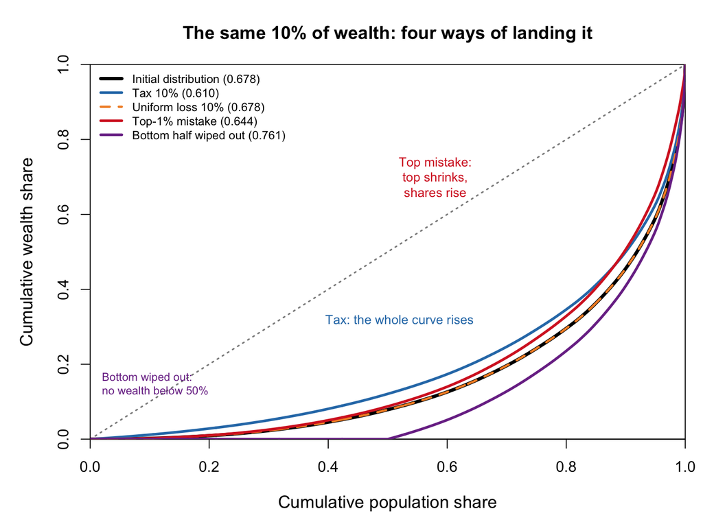

```r
## The same 10% of wealth: Lorenz curves for four ways of landing it (top-10% and
## top-1% mistakes point the same way; only the latter is drawn).
## Tax lifts the whole curve; uniform loss coincides with the original; a top-1% mistake
## trims the top and pushes shares up mechanically; a bottom wipeout flattens the lower left.
inv_lorenz <- function(w){
  w <- sort(w); n <- length(w)
  data.frame(p = c(0, (1:n)/n), L = c(0, cumsum(w)/sum(w)))
}
inv_wipe2 <- inv_w0; inv_wipe2[inv_bot50] <- 0
L0 <- inv_lorenz(inv_w0); Lt <- inv_lorenz(inv_tax)
Lu <- inv_lorenz(inv_unif); Lp <- inv_lorenz(inv_prop1); Lw <- inv_lorenz(inv_wipe2)
par(mar = c(4.6, 5.0, 3.6, 1.0), cex.lab = 1.15)
plot(NA, xlim = c(0, 1), ylim = c(0, 1), xaxs = "i", yaxs = "i",
     xlab = "Cumulative population share", ylab = "Cumulative wealth share",
     main = sprintf("The same %.0f%% of wealth: four ways of landing it", 100*inv_loss))
abline(0, 1, lty = 3, col = "gray55", lwd = 1.6)
lines(L0$p, L0$L, col = "black", lwd = 3.6)
lines(Lt$p, Lt$L, col = "#2C7BB6", lwd = 2.8)
lines(Lu$p, Lu$L, col = "#F28E2B", lwd = 2.4, lty = 2)
lines(Lp$p, Lp$L, col = "#D62728", lwd = 2.8)
lines(Lw$p, Lw$L, col = "#7B3294", lwd = 2.8)
legend("topleft", bty = "n", cex = 0.78,
       lwd = c(3.6, 2.8, 2.4, 2.8, 2.8), lty = c(1, 1, 2, 1, 1),
       col = c("black", "#2C7BB6", "#F28E2B", "#D62728", "#7B3294"),
       legend = c(sprintf("Initial distribution (%.3f)", inv_g0),
                  sprintf("Tax %.0f%% (%.3f)", 100*inv_loss, gini(inv_tax)),
                  sprintf("Uniform loss %.0f%% (%.3f)", 100*inv_loss, gini(inv_unif)),
                  sprintf("Top-1%% mistake (%.3f)", gini(inv_prop1)),
                  sprintf("Bottom half wiped out (%.3f)", gini(inv_wipe2))))
text(0.52, 0.32, "Tax: the whole curve rises", col = "#2C7BB6", cex = 0.85)
text(0.58, 0.70, "Top mistake:\ntop shrinks,\nshares rise", col = "#D62728", cex = 0.85)
text(0.02, 0.12, "Bottom wiped out:\nno wealth below 50%", col = "#7B3294", cex = 0.75, adj = c(0, 0))
```

The most striking thing in the figure is the purple line: after the bottom half is wiped out, the Lorenz curve hugs the horizontal axis for the first 50% of the population—this is not “more equal,” it is kicking half the population out of the wealth distribution. Its Gini is 0.761, higher than the initial value; the top-1% share rises to 0.199. This line is not a feasible “investment mistake” but an arithmetic warning: all the wealth of the bottom half is only 7.9% of the total, not enough to absorb a 10% shock. Taking money from the poor cannot produce a large sum; it only makes the poor poorer and the Gini higher.

One more boundary is easy to miss: the “uniform loss” in the table is **everyone** losing 10%. If only a subset is hit, rather than everyone, the proportional loss becomes multiplicative noise and the Gini can rise—the same kind of thing as the sigma knob in Chapter 5: multiplicative noise changes the shape of the distribution, not just its scale. Letting everyone lose is how this section isolates “pure proportional scaling”; real investment mistakes are of course not that tidy.

```r
## Half-life of a single fortune: a tax is deterministic compound decay; a mistake is a loss of half with annual probability p.
## Compare expected log returns, to avoid mixing "expected value" with "typical path".
inv_tau <- 0.01; inv_p <- 0.10; inv_ell <- 0.50
inv_hl_tax <- log(0.5)/log(1 - inv_tau)
inv_hl_mis <- log(0.5)/(inv_p*log(1 - inv_ell))
inv_p_eq <- log(1 - inv_tau)/log(1 - inv_ell)
reg("inv_tau", inv_tau, "analytic", "§6.4 invest_halflife", "Annual wealth tax rate")
reg("inv_p", inv_p, "analytic", "§6.4 invest_halflife", "Annual probability of losing half")
reg("inv_ell", inv_ell, "analytic", "§6.4 invest_halflife", "Fraction lost in one mistake")
reg("inv_hl_tax", inv_hl_tax, "analytic", "§6.4 invest_halflife", "Half-life of a single fortune under a 1% wealth tax (years)")
reg("inv_hl_mis", inv_hl_mis, "analytic", "§6.4 invest_halflife", "Half-life when half is lost with 10% annual probability (years)")
reg("inv_p_eq", inv_p_eq, "analytic", "§6.4 invest_halflife", "Annual probability that matches the 1% tax in expected log return")
```

### 6.4.3 Fast is not the same as equal

The part of the saying people remember is “fast.” That part is right. A wealth tax of 1% a year takes 69.0 years to halve a fortune; an investment that loses half with probability 10% a year has a half-life of 10.0 years. The first grinds slowly through compound decay; the second drops in jumps. To match the two in expected log return, the annual probability of losing half need only be 1.45%—10% is already 6.9 times that.

But fast and equal are two different things. The tax rebates what it collects per capita, so the bottom receives more than it pays; an investment mistake destroys the money, and the bottom receives nothing. So for the same 10%, the tax pushes the Gini to 0.610, while a top-1% mistake pushes it only to 0.644—even though the latter hits the top 1% harder. A mechanism that makes the rich poorer is not automatically a mechanism that makes society flatter; it may only replace one set of people at the top.

The last two columns of the table measure retention, and they do not measure the same people. In the top-1%-mistake row, top-1% retention is 0.333—67% of them drop out; but top-10% retention is still 1.000, because those who drop out are still inside the top ten, just in different seats. The top-10%-mistake row is the reverse: top-10% retention falls to 0.875, while top-1% retention is 1.000—those who drop out come mainly from the 90–99 percentile band, and the very top keeps its rank. The tax and uniform-loss rows both show 1.000; nobody moves. This is the axis of Chapter 7: the Gini says how large the gap is, retention says whether positions change hands, and “top 1%” and “top 10%” retention can tell different stories. Both things can happen at once, or separately. The saying describes a change of occupants, not a flattening.

### 6.4.4 This is a shock, not a rule

There is one more layer, already measured in §6.3.5: a shock changes the state, a rule changes the steady state. An investment mistake is a shock—it can knock down a person or a generation, but the market keeps running under the same rules, and the distribution grows back. A tax is a knob turned every round; a mistake is an event in one round. Making one mistake very large can of course push the Gini down for a while, but in the next round there is no mistake, the engine is still there, and the top grows back. For a mistake to become a lasting equalizing force it would have to become a rule—for example, “every heir must stake half the fortune on one concentrated investment”—and that is no longer an “investment mistake” but a confiscation.

So the right way to put “rich people’s investments” into this essay’s framework is not to add a downward arrow to the master figure but to give it a “who bears it” parameter:

- If the mistake falls uniformly on everyone, it is a proportional scaling and the Gini does not move; if it is random and falls on only some people, it is multiplicative noise and the Gini can rise.
- If the mistake is concentrated on the top 10% or the top 1%, it can trim the top, and retention in the band that is hit will fall, but the Gini need not fall below the tax case, because the bottom is not lifted.
- If the mistake falls on the bottom, it cannot even produce a macroeconomic loss of the same size; wiping out all the wealth of the bottom half only raises the Gini from 0.678 to 0.761, and the top-1% share rises to 0.199. That is not equalizing wealth; it is making the poor poorer.

Together, these three answer the saying: it describes a real channel of individual risk, not a reliable distributional mechanism. Someone who acquires assets by luck may give the money back in one concentrated investment; but the direction of the effect on the Gini depends on whether he is in the top 1%, and on who takes his place after he falls. The literature says that on average the rich invest better, and that inherited control and windfalls are exceptions; an exception can ruin a family, but it cannot flatten the whole distribution.

Compress the literature and the model into one table. The household measure is the net return; the firm measure is the operating margin on assets—the two measures must not be conflated, but their directions can be read side by side. The first eight rows are literature; the last five are this essay’s model. Here “rule” is a mechanism that operates continuously, “shock” is an event that happens once; “average” is the average effect across the whole population, “local” is an effect on a small group.

Direction of various factors for investment outcomes: net return, operating margin, and distribution

| Factor | Mechanism type | What it affects · direction | Evidence and magnitude | Implication for the distribution |
| --- | --- | --- | --- | --- |
| Wealth level (net worth) | Rule · average (advantage) | Household net return ↑ (still ↑ after tax) | Fagereng 10→90: +18 pp (after tax +10 pp); Bach: top ≈ equity premium | Widens the gap (§6.1.3 capital return) |
| Financial literacy | Rule · average (two-sided) | Portfolio efficiency ↑; underdiversification loss ↑ | Calvet 2007 | Net effect ambiguous: efficiency and risk-taking move together |
| Trading frequency | Rule · average (mistake) | Household net return ↓ (gross return similar) | Barber–Odean: most active 11.4% vs market 17.9% | Lowers net return; distribution effect depends on who trades more |
| Underdiversification | Rule · average (mistake) | Household net return ↓ | Calvet 2007 | Depends on who is underdiversified |
| Non-participation in risky assets | Rule · average (mistake) | Household net return ↓ (participants need not be efficient either) | Calvet 2007 | Depends on who does not participate |
| Inherited control | Shock · local | Firm operating margin ↓ | Pérez-González 2006; Bennedsen 2007: at least −4 pp | Trims the top; Gini direction ambiguous |
| Windfall / lottery | Shock · local | Bankruptcy: postponed, not avoided | Hankins 2011 | Trims the top; Gini direction ambiguous |
| Larger stakes (unexpected inheritance) | Shock · local | Investment mistakes ↓, but economically small | Andersen 2021 | Small effect |
| Investment mistake: top 1% bears | Shock · local | Own wealth ↓ 54.6% | This model | Gini 0.644; top-1% retention 0.333 |
| Investment mistake: top 10% bears | Shock · local | Own wealth ↓ 18.4% | This model | Gini 0.649; top-10% retention 0.875 |
| Uniform loss: everyone | Shock · universal | Own wealth ↓ 10% | This model; analytic identity | Gini unchanged (0.678) |
| Tax + per-capita rebate | Rule · universal | Net wealth: top ↓, bottom ↑ | This model | Gini 0.610 |
| Investment mistake: bottom half | Shock · local | Bottom wealth ↓ (wiped out) | This model | Gini rises to 0.761 |

Read the table for two things. First, the force that persistently widens the gap is the “rule · average (advantage)” row: more wealth means a higher average return; trading frequency, underdiversification, and non-participation also lower net returns, but whether they widen the gap depends on who is more likely to make those mistakes. Second, the “shock · local” column depends on who bears it: on the top it trims the top, on the bottom it pushes the Gini up. The saying reads only the second column and mistakes it for the first.

Finally, put this section back into Chapter 6. The master figure in §6.5 gives every mechanism an arrow, because it measures “starting from the 0.5 baseline, where does this mechanism push the Gini.” An investment mistake cannot supply a single arrow: for the same frequency and the same loss, change who bears it and the sign flips. So it does not enter the master figure; it enters the table of things the Gini cannot measure—what it really changes is whether positions change hands, not how wide the gap is. That is also what Chapter 7 takes up next.

## 6.5 What the Three Families Together Tell Us

Back to the master figure at the start of this chapter. Every arrow has now been computed once in some earlier section:

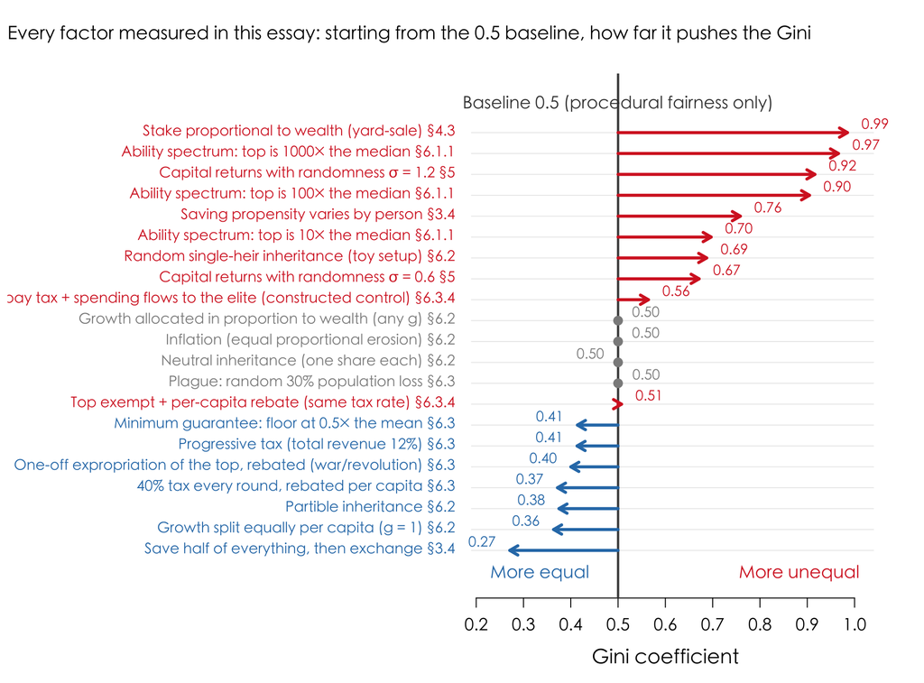

```r
f <- draw_fmap(FKEY_ALL, "Every factor measured in this essay: starting from the 0.5 baseline, how far it pushes the Gini")
```

```r
stopifnot(sum(f$neutral) == 4)     # the text says "four gray dots"; if the count does not match, it blows up
```

Three things are visible at a glance:

1. The upward forces are much stronger than the downward ones. The strongest rightward arrow pushes the Gini to 0.985—and that is a non-converging process; the longer it runs, the higher it goes. The strongest leftward arrow can push it down only to 0.27. Inequality has no ceiling but a hard floor.
2. The four gray dots in the middle are the most counterintuitive: growth distributed in proportion to wealth, neutral inheritance, inflation, and random 30% attrition—four things almost everyone assumes would change the gap, yet in the measurements they did not budge. The reasons differ; take them one by one below.
3. Ability differences are not a point but an interval: a 10-fold spectrum pushes to 0.70, a 100-fold spectrum to 0.90, and a 1000-fold spectrum to 0.97. So the question “how much does natural inequality matter?” has different answers in different industries.

But the figure omits three things, and rightly so. Some mechanisms should not be measured by the Gini at all—not because they are unimportant, but precisely because what matters about them lies elsewhere:

| Factor | Where it appears | Why the Gini cannot measure it | What it actually changes |
| --- | --- | --- | --- |
| Credit and liquidation rules | §6.1.2 | Wealth can be negative, and the Gini loses its meaning there | How many are still in: equal credit + forced liquidation, 96.6% out |
| The mobility dimension of inheritance | §6.2 | The Gini tracks only the cross-sectional gap, not who stands where | Intergenerational rank correlation: neutral 1.00 / partible 0.67 / random heir 0.18 |
| Investment mistakes of the rich | §6.4 | Direction depends on who bears it: a uniform loss leaves the Gini unchanged, a top-1% mistake trims the top, a bottom mistake pushes it up | Top-1% retention: tax 1.000 / top-1% mistake 0.333 |

These three rows are not an afterthought but a reminder: the horizontal axis above has only one dimension, and what it compresses out—who is still in, who faces whom, whether positions change hands—is often more important than what it keeps. Translating a Gini into a Distribution: A Conversion Table has already made the same point from the “shape of the distribution” side.

Compress the three mechanism families into one sentence:

> In this essay’s wealth-stock model, many mechanisms can push inequality up, and all of them act on the stock. Redistribution belongs to no family: its effect is determined jointly by the shape of actual net incidence along wealth rank, the size and frequency of transfers, and how these compare in strength with the exchange dynamics. Within the parameter range tested here, when the collection burden tilts toward the lower middle and spending tilts toward the top, the net effect of the arrangement undergoes a sign reversal. Every other “equalizing” effect remains a special case of some two-sided mechanism under the condition “the same for everyone.”

This sentence yields two direct corollaries.

First, fairness is not automatic. Not one leftward arrow in the master figure comes for free: most depend on “the rules are the same for everyone,” while taxation depends on another, equally fragile condition—the tax base actually reaches the top. And that condition does not maintain itself—it has to be actively maintained. That is why the “reverse dominance hierarchy” device at the end of Chapter 5 matters: it maintains exactly this condition.

Second, “procedural fairness” acquires a precise meaning here. It is not a moral slogan but the switch that pins an entire family of mechanisms at the neutral position on this master figure. Release it, and that family swings at once to the upward side—and swings harder than any single factor (0.758, 0.92).

# 7 One Number Is Not Enough: What Else to Look At

Every chapter so far has asked “where inequality comes from and where it goes.” This chapter asks a different question: to describe a society’s inequality clearly, is one number enough?

The answer has already turned up three times, and each time it was dealt with on the spot:

- §4.6: two societies can have exactly the same Gini, one “a single life laid out over time” and the other “a birth list”—the Gini cannot tell them apart.
- Translating a Gini into a Distribution: A Conversion Table: given a Gini, the shape of the distribution is still free—at the same 0.5, the Pareto’s probability at a hundred times the mean is about $10^{40}$ times the exponential’s—the Gini cannot pin down the shape.
- §6.2.2: the vertical axis of the Great Gatsby curve, $\beta=\rho\cdot\sigma_c/\sigma_p$, contains a ratio of dispersions—something from the horizontal axis has leaked into the vertical one.

This chapter picks up that thread and takes one more step: class mobility cannot distinguish “able to climb out” from “randomly reshuffled,” nor can it say what position is anchored to.

The structure is two general axes: the Gini and class mobility—as long as a mechanism can be re-run on the same exchange machine, both can be computed.

## 7.1 The Second Axis: Class Mobility

Every factor in Chapter 6 was reported with a single number: the Gini. But §§4.5–4.6 have already argued that the Gini is a cross-sectional quantity—it cannot say whether the same person will still be in that position next year. §6.2, while measuring inheritance, added a mobility indicator on the side, and found that the Gini and class mobility can move independently. So why not compute both for every factor in Chapter 6?

But the word “mobility” covers two different things, and they point in opposite directions of value. Without spelling that out, everything that follows is muddled:

- **Intergenerational class mobility**: whether the parents’ position predicts the children’s. §6.2 measured this for the three inheritance rules (reporting the rank correlation of father-son positions; higher means less mobile)—neutral inheritance 1.00, partible inheritance 0.67, random-heir inheritance 0.18.
- **Intra-generational class mobility**: whether the same person, within a lifetime, is still in the same position after some time has passed.

For one and the same word, “mobility,” the direction you want is opposite. Under the conditions set out in §4.6:

|  | What we want | Because |
| --- | --- | --- |
| Intergenerational mobility | High | If position can be predicted from parents, the predictive power comes from transmitted wealth, not from the person—the children of the poor should have a chance to rise, and those who hold high positi… |
| Intra-generational mobility | Not necessarily high | If a person really is more capable, there is no problem with them earning more durably—the problem is what position is tracking |

This asymmetry is the entire motivation for the second half of this chapter. On the intergenerational side, §6.2 has already done the measuring; this section measures the intra-generational side; and “what position is tracking”—which the mobility axis cannot answer at all—is left for the next section.

We need an indicator that applies within a lifetime and can be computed for every mechanism. Intergenerational mobility only makes sense where there are generations, and most of Chapter 6’s mechanisms (ability, saving, returns to capital, taxes, growth) do not involve generations at all. So switch to a more basic quantity:

> The **rank-rank correlation** $\rho$ $=$ the **rank correlation** between two wealth rankings $H$ rounds apart (below, $H=100$, the default of `run2()`). It is a reverse reading of class mobility: the higher $\rho$ is, the lower mobility is.

It asks “after all this time, are the same people still on top?” In the figure below each mechanism is one row, with the Gini stored in `cfg$g` and the rank correlation in `cfg$r` (the whole table is in `docs/data/two_axes.csv`); wherever the text later cites a reading from the figure, it comes from these two columns. $\rho=1$ means positions are completely frozen and mobility is zero; $\rho=0$ means there is no monotonic association between ranks and mobility is maximal (note that $\rho=0$ is not “no relationship at all”—it only rules out a monotonic rank association). Take $H=100$ rounds:

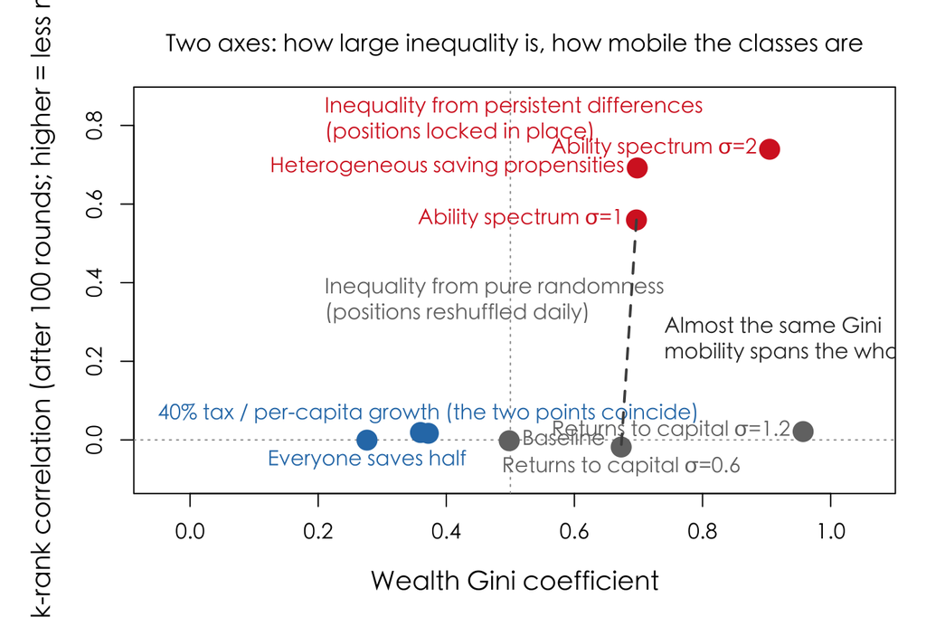

```r
## An extended version of run1: the same exchange machine, returning both the Gini and the rank-rank correlation
run2 <- function(N = 1500, rounds = 400, mode = "base", p = 0, seed = 1, H = 100){
  set.seed(seed); w <- rep(1, N); half <- N/2
  a <- if (mode == "ability") exp(rnorm(N, 0, p)) else rep(1, N); a <- a/mean(a)
  lam <- switch(mode, save_all = rep(p, N), save_het = runif(N), rep(0, N))
  w0 <- NULL
  for (r in 1:rounds){
    if (r == rounds - H + 1) w0 <- w                              # record the position exactly H rounds ago
    if (mode == "tax" && p > 0){ tx <- p*w; w <- w - tx + sum(tx)/N }
    if (mode == "growflat")     w <- w + p*mean(w)
    if (mode == "capital")      w <- w*exp(-p^2/2 + p*rnorm(N))
    idx <- sample.int(N); i <- idx[1:half]; j <- idx[(half+1):N]
    pooled <- (1-lam[i])*w[i] + (1-lam[j])*w[j]
    e <- if (mode == "ability") rbeta(half, a[i], a[j]) else runif(half)
    w[i] <- lam[i]*w[i] + e*pooled; w[j] <- lam[j]*w[j] + (1-e)*pooled
    if (mode == "capital") w <- w/mean(w)
  }
  c(gini = gini(w), rho = cor(rank(w0), rank(w)))
}
cfg <- data.frame(
  mode = c("base", "save_all", "tax", "growflat", "capital", "capital",
           "save_het", "ability", "ability"),
  p    = c(0, 0.5, 0.4, 1, 0.6, 1.2, 0, 1, 2),
  lab  = c("Baseline", "Everyone saves half", "40% tax / per-capita growth (the two points coincide)", "",
           "Returns to capital σ=0.6", "Returns to capital σ=1.2", "Heterogeneous saving propensities",
           "Ability spectrum σ=1", "Ability spectrum σ=2"), stringsAsFactors = FALSE)
MM <- t(mapply(function(m, p) run2(mode = m, p = p), cfg$mode, cfg$p))   # not M: §5 already uses it
cfg$g <- MM[, 1]; cfg$r <- MM[, 2]

ACC <- "#D62728"; BLU <- "#2C7BB6"; GRY <- "gray45"
cfg$col <- ifelse(cfg$r > 0.2, ACC, ifelse(cfg$g < 0.45, BLU, GRY))
par(mar = c(4.8, 5.2, 3.4, 1.2), cex.lab = 1.22, cex.main = 1.12, family = "cjk")
plot(NA, xlim = range(cfg$g) + c(-0.32, 0.10), ylim = range(c(cfg$r, 0)) + c(-0.08, 0.12),
     xlab = "Wealth Gini coefficient",
     ylab = "Rank-rank correlation (after 100 rounds; higher = less mobile)",
     main = "Two axes: how large inequality is, how mobile the classes are")
abline(h = 0, lty = 3, col = "gray60"); abline(v = 0.5, lty = 3, col = "gray60")
text(0.19, 0.80, "Inequality from persistent differences\n(positions locked in place)", col = ACC, cex = 1.0, pos = 4)
text(0.19, 0.34, "Inequality from pure randomness\n(positions reshuffled daily)", col = GRY, cex = 1.0, pos = 4)
points(cfg$g, cfg$r, pch = 21, bg = cfg$col, col = cfg$col, cex = 1.9, lwd = 2)
text(cfg$g, cfg$r, cfg$lab, pos = c(4,1,3,1,1,2,2,2,2), cex = 0.98, col = cfg$col)
i1 <- which(cfg$lab == "Ability spectrum σ=1"); i2 <- which(cfg$lab == "Returns to capital σ=0.6")
segments(cfg$g[i1], cfg$r[i1], cfg$g[i2], cfg$r[i2], lty = 2, lwd = 2, col = "gray30")
text(0.72, 0.24, "Almost the same Gini\nmobility spans the whole range", cex = 1.0, col = "gray20", pos = 4)
```

(This `run2()` is an extended version of `run1()` from §6.1.1, storing one extra mid-run snapshot. It reproduces the Ginis from the earlier sections for the baseline, saving, and ability settings (the two returns-to-capital settings differ from Chapter 5—there they carry a 0.01 drift, and $N$ and the number of rounds also differ, so the two are comparable but not identical): baseline 0.50, universal saving 0.28, ability spectrum σ=1 0.70, returns to capital σ=0.6 0.67—so the numbers on the two axes are comparable.)

The most important thing in this figure is the two points joined by that dashed line.

| Mechanism | Where the inequality comes from | Gini coefficient | Rank-rank correlation |
| --- | --- | --- | --- |
| Ability spectrum σ = 1 | Persistent ability differences between people | 0.70 | +0.56 |
| Returns to capital σ = 0.6 | A return rate that is the same for everyone, but noisy | 0.67 | -0.02 |

The Ginis are about the same (0.70 versus 0.67), but the rank-rank correlations are +0.56 versus -0.02—one is clearly high and the other is essentially zero. (The former is not “completely frozen” (that would take $\rho=1$), but it is already a society with quite sticky positions; the latter’s $\rho$ sits near zero.) These are the two worlds of §4.6, except that this time they are not constructed—they come out of two of this chapter’s own mechanisms. Governing both with the Gini would treat them as the same thing; but to be born into one or the other is a completely different life.

The whole figure gives a much cleaner regularity than looking at the Gini alone:

> Across the schemes tested here, locked-in positions appear only in the family with persistent individual differences, regardless of how strong the randomness is. (This is for the settings tested and this time horizon; and $\rho\approx0$ only says there is no monotonic rank association—it does not mean “no relationship at all.”)

Three groups of evidence:

- Every member of the red family—ability spectrum, heterogeneous saving propensities—has a rank correlation above 0.56 (the figure colors by $\rho>0.2$). What they share is that each person carries a label that does not change over time (ability, saving rate), and the label determines where that person lands in the long run. The higher the Gini, the more visible the label.
- The gray family—baseline and returns to capital—pushes the Gini all the way to 0.96, yet the rank correlation stays near zero and mobility is maxed out. The fluctuations are redrawn every round, so no one has a lasting advantage: today’s rich are just the people who have been lucky lately. Inequality from pure randomness really does not make positions persist (for the intergenerational side see §6.2; this section measures within a lifetime).

  But here a comfortable platitude has to be taken apart: $\rho\approx0$ has two completely different sources—position can be changed by the person (that is real mobility), or position is reshuffled by randomness and institutional rules (that is only fluctuation). $\rho$ itself cannot tell the two apart. And this model has no variable for agency at all, so it cannot identify self-driven mobility; every observed change of position comes from the randomness and institutional rules it imposes itself. So every “mobility” number in this essay measures “did the occupant of a position change,” not “can a person climb out.”
- The blue family—taxes, per-capita growth, universal saving—pushes the Gini down, and the rank correlation is likewise zero. They do not lock people in. This deserves saying on its own: these schemes lower inequality without sacrificing mobility—no point in the figure has both a low Gini and low mobility. (Caveat: the tax run here is the “levy the same proportional rate on everyone, rebate per capita” kind; the top-exemption schemes of §6.3.4 are not in this figure, and they do not even share the same sign.)

As an aside, look at the conclusion from §6.2: a 40% tax and per-capita shared growth ($g=1$) land almost on the same point on both axes (0.37 / +0.02 versus 0.36 / +0.02).

But be precise: they belong to the same family of operations; it is not that these two parameter values happen to be equivalent. After normalizing by the mean, per-capita growth $g$ gives $r'=\frac{r+g}{1+g}$, while a tax $\tau$ gives $r'=(1-\tau)r+\tau$; matching coefficients gives
$$\tau=\frac{g}{1+g}$$
So $g=1$ corresponds to $\tau=0.5$, not 0.4. The two points look coincident because the Gini curve is already flat in that range—a numerical coincidence, not an identity. What is identical is the family: any operation that adds the same constant to everyone is the same operation, and the only difference is where the money comes from.

The two axes are not necessarily separate—others have measured when they separate and when they do not. Bertotti and Modanese swept a two-parameter plane of “tax-rate gap × welfare eligibility” in a model that is likewise kinetic, and found the Gini contours and the mobility contours coinciding to within one part in a thousand (Bertotti and Modanese 2016); the same group later reported that across many settings the correlation between the two is consistently negative, in line with the Great Gatsby curve (Bertotti et al. 2017).

This does not conflict with the figure above; what conflicts is how it is read. The definitions have to be lined up first: their mobility is an **upward transition probability** (“the probability per unit time that a person moves up one income bracket, averaged across brackets with weights”), directional, between discrete income brackets; this essay’s is a rank-rank correlation, symmetric and continuous. The two numbers cannot be compared directly.

What is genuinely comparable is the range swept. They swept a family of tax and welfare parameters—within that family the two axes really are nearly collinear, and the second axis adds no new information. This essay sweeps mechanism types: saving, ability spectrum, returns to capital, taxes, growth. At that scale the collinearity breaks—ability spectrum σ=1 and returns to capital σ=0.6 have almost the same Gini, yet one rank-rank correlation is strongly positive and the other is essentially zero.

> So the right statement is not “the Gini and mobility are unrelated,” but: within a family of mechanisms they can be tightly bound together, and across mechanism families they come apart. Collinearity is a property of a restricted parameter family, not a general law. And real policy debate is precisely across mechanism families—taxes, education, inheritance, and capital markets do not lie in the same plane.

(As an aside, Bertotti and Modanese close their paper by likening economic mobility to gas temperature, and note that the Gini of the Boltzmann–Gibbs exponential distribution is independent of temperature and always equals $1/2$ (Bertotti and Modanese 2016)—exactly the baseline of Chapter 3. The “temperature” thread is the main subject of the companion essay, *Fairness and Efficiency: The Same Temperature*.)

One sentence joining the two axes: the Gini asks “how big is the gap,” intra-generational class mobility asks “is it the same people on top.”

Only some of the mechanisms that push inequality up also make positions highly persistent; and none of the mechanisms that push inequality down does so by fixing positions.

But this axis stops here—it cannot say what position is anchored to. In the red family in the figure, the rank correlation at the ability-spectrum σ=1 point is 0.56, and at the heterogeneous-saving point it is 0.69; both are high. Yet their persistent labels are, by construction, two different things—one is the fixed label called “ability” in the model, the other a saving habit unrelated to it.

This is not the weak claim that “two numbers happen to be close.” $\rho$ is the correlation coefficient between two wealth-rank vectors, and nothing in its definition points to “why position persists.” And saying “the formula has no such term” is not enough—there exist two worlds that give exactly the same $\rho$ while tracking different things: take $\rho = 1$; in world A the wealth rank always equals the ability rank, in world B the wealth rank always equals the saving-propensity rank while ability and wealth are independent. The readings are identical on both sides, yet position is anchored to completely different things. So $\rho$ alone cannot identify what position is tracking.

Separating them takes not a finer rank correlation but a joint statistic of wealth and ability—which this essay does not compute, and the next section explains why. (There is a harder layer too: even with that ruler built, position may in turn shape ability—someone who has been unlucky and long denied a chance to exercise their ability will see the ability itself degrade. And the cross-sectional associations this essay reports are not enough to determine whether ability determines position or position shapes ability.)

What $\rho$ hides does not stop there: it also flattens top and bottom. §4.6 said that positional mobility is zero-sum—if someone goes up, someone must come down. But going up and coming down are not necessarily equally easy. Split the single global $\rho$ by the decile you start in (the result is stored in `FC` and written to `docs/data/floor_ceiling.csv`) and look at the share of each cell that is still in the same decile after $H$ rounds (under complete random reshuffling it should equal 0.1 everywhere):

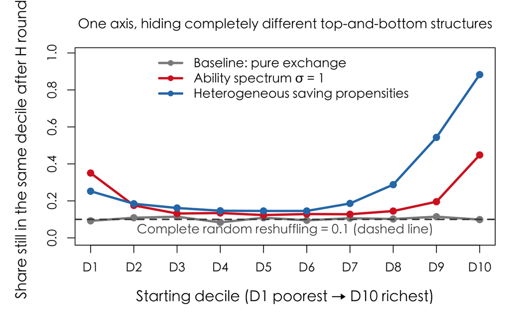

```r
## Split positional mobility by "which decile you started in": the share that stays in the same decile.
## Under complete random reshuffling every cell is 0.1; above 0.1 means "stuck".
snap2 <- function(mode = "base", p = 0, N = 1500, rounds = 400, H = 100, seed = 1){
  set.seed(seed); w <- rep(1, N); half <- N/2
  a <- if (mode == "ability") exp(rnorm(N, 0, p)) else rep(1, N); a <- a/mean(a)
  lam <- if (mode == "save_het") runif(N) else rep(0, N)
  w0 <- NULL
  for (r in 1:rounds){
    if (r == rounds - H + 1) w0 <- w
    idx <- sample.int(N); i <- idx[1:half]; j <- idx[(half+1):N]
    pooled <- (1-lam[i])*w[i] + (1-lam[j])*w[j]
    e <- if (mode == "ability") rbeta(half, a[i], a[j]) else runif(half)
    w[i] <- lam[i]*w[i] + e*pooled; w[j] <- lam[j]*w[j] + (1-e)*pooled
  }
  list(w0 = w0, w1 = w)
}
dec10 <- function(x) cut(rank(x, ties.method = "first"),
                         breaks = quantile(seq_along(x), 0:10/10),
                         include.lowest = TRUE, labels = FALSE)
stay <- function(mode, p, seeds = 1:12)
  rowMeans(sapply(seeds, function(sd){
    S <- snap2(mode, p, seed = sd); d0 <- dec10(S$w0); d1 <- dec10(S$w1)
    sapply(1:10, function(k) mean(d1[d0 == k] == k)) }))
FC <- cbind(`Baseline: pure exchange` = stay("base", 0),
            `Ability spectrum σ = 1`  = stay("ability", 1),
            `Heterogeneous saving propensities`  = stay("save_het", 0))

COLF <- c("gray55", "#D62728", "#2C7BB6")
par(mar = c(4.6, 5.0, 3.2, 1.0), cex.lab = 1.2, cex.main = 1.08, family = "cjk")
matplot(1:10, FC, type = "o", pch = 16, lty = 1, lwd = 3, cex = 1.3, col = COLF,
        ylim = c(0, max(FC)*1.12), xaxt = "n",
        xlab = "Starting decile (D1 poorest → D10 richest)",
        ylab = "Share still in the same decile after H rounds", main = "One axis, hiding completely different top-and-bottom structures")
axis(1, at = 1:10, labels = paste0("D", 1:10))
abline(h = 0.1, lty = 2, lwd = 2, col = "gray30")
text(5.5, 0.045, "Complete random reshuffling = 0.1 (dashed line)", col = "gray30", cex = 1.02)
legend("top", colnames(FC), col = COLF, lwd = 3, pch = 16, bty = "n", cex = 1.02)
```

```r
stopifnot(all(abs(FC[, 1] - 0.1) < 0.03))       # the baseline should sit at 0.1 everywhere
```

The three lines tell three different stories.

- The baseline (gray) sits at 0.1 everywhere. Pure exchange has no stickiness, not even at the bottom—the wall at 0 does not create a sticky floor. This is worth spelling out, because “the poor cannot climb out” is often treated as a natural consequence of randomness, and on this machine it does not hold.
- The ability spectrum (red) is a symmetric U. Both ends are sticky (D1 0.35, D10 0.45), the middle is loose. Top and bottom are about equally stuck—the label works the same way at both ends of the distribution.
- The heterogeneous-saving line (blue) is a lopsided U. The bottom is 0.25, the top 0.88—the top is almost frozen, the bottom only slightly sticky. In the same mechanism, top and bottom differ by more than a factor of three.

And the global $\rho$ of these two lines is close (ability spectrum 0.56, heterogeneous saving 0.69). That is: the same mobility reading can mean “equally stuck at top and bottom” or “the top locked shut while the bottom still changes hands.” These two societies are completely different for the people inside them, and that one number reports them as the same thing.

## 7.2 The Two Model Boundaries of This Essay

The previous section stopped at a gap. It is one of this essay’s two model boundaries, and both need saying before this chapter can close cleanly.

Boundary one: there is no ability variable shared by all mechanisms, and no joint quantity of wealth and ability has been computed. This is easy to misstate, so it needs saying precisely: the essay does have an individual endowment—the `a` in §6.1.1 and in the figure in the previous section. Two other things are missing: `a` lives only in the ability experiments, and is absent from the tax, inheritance, saving, and inflation mechanisms; and everything this essay reports, from beginning to end, is a wealth-side quantity (Gini, rank autocorrelation), with no joint wealth × ability statistic computed anywhere.

So the question “what is position tracking?” cannot be answered here—but it is worth seeing why. Answering it needs no production model: how much association there is between wealth rank and ability rank is a purely statistical question. The production model belongs to the step after that—reading “the allocation matches ability” as “higher efficiency” is what needs a machine that can compute output directly. These two are often conflated; they sit one layer apart.

Boundary two: there is no production, so the model has no such thing as “annual income”. §4.4 measured one thing: the model’s income Gini is a function of the accounting window—0.55 at 1 round, 0.06 at 100 rounds, 0.02 at 1000 rounds. The reason is plain: on the island “income” is only coins transferred from someone else, while in reality most income is wages that have been produced. Change the window and the number changes; there is no stable annual income to speak of.

This second boundary rules out more than it looks. Any quantity that can only be discussed once there is an annual income with a definite time scale is undefined in this model—the permanent/transitory decomposition of income in §4.6 is the clearest case. It is not hard to compute; there is nothing to compute it on.

One sentence to close: a pure exchange model can say how the stock is distributed, but not how the flow fluctuates. Everything this essay says about mobility is about wealth rank, not income.

# 8 Conclusion: Back to Rousseau

The pirate returns to the island years later and finds an exponential distribution, Gini $1/2$. No one has done anything wrong. All it takes is three things: the total number of coins is conserved, wealth has a lower bound, and every transaction is equally fair to both sides.

Rousseau’s ledger has only two columns, the natural and the artificial. This essay adds a third: luck. That column is not a constant you can subtract straight out of the artificial one. $1/2$ is the baseline of this particular exchange machine: the stake in each transaction does not scale with wealth, and the rule is the same for everyone. Change the exchange rule and the shape changes with it; yard-sale, where the stake is proportional to wealth, is equally conserving and equally fair, yet heads all the way to one person taking everything (§4.3). So when reading a real Gini, the question is: compared with the luck baseline under the same exchange rule, where is it higher and where lower, and which family of mechanisms pushed up the excess?

How bad it can get—Chapter 5 gives the location. Add fluctuation $\sigma$ to returns: variance first stops meaning anything at $\sigma\approx0.64$, and the mean stops meaning anything at $\sigma=1$: the typical person drifts to zero, the average does not move, held up by fewer and fewer people. The Gini passes smoothly through both. Whether inequality has changed character is a question about whether the tail still has a mean, not about the Gini reading.

What can be changed—the master figure in Chapter 6 gives the proportions. The mechanisms that push inequality up are many and strong: the strongest pushes the Gini to 0.99, the strongest of the downward ones brings it down to 0.27. Most of the downward ones rest on one condition: the rule is the same for everyone. Taxation carries two further conditions: the tax base reaches the top, and spending does not flow to the top; when both are reversed (§6.3.4), an arrangement that still goes by the name of redistribution pushes the Gini to 0.56. None of these conditions maintains itself. Rousseau’s encloser is exactly this in the model: the rule is different for him than for everyone else.

Finally, one number is not enough. The Gini says how large the gaps are, not whether the same people are on top. With two mechanisms that have similar Ginis, rank can be frozen in one and constantly reshuffled in the other (§7.1). And even measuring whether position is sticky cannot say what the stickiness is attached to—ability, saving habits, or birth. Answering that needs a joint statistic of wealth and ability, and a machine with production; that is what the companion essay, *Fairness and Efficiency: The Same Temperature*, takes up next.

The Academy of Dijon asked: what is the origin of inequality among men? Rousseau gave two sources. Run his thought experiment, and a third appears; this one need not be guessed—it can be computed.

*The data behind every figure and table in this essay is written automatically to `docs/data/` at each knit; the item-by-item table is in `docs/provenance-registry-en.md`.*

*The full derivations of maximum entropy, Lagrange multipliers, KL divergence, and the Boltzmann distribution used in this essay are in [From Entropy to Distributions: The Unified Logic of the Exponential, Power Law, Normal, and Boltzmann](https://nyuhuyang.github.io/notes/exp_normal_boltzmann_zh.html); each time one is used, the section link is given on the spot.*

# References

Andersen, Steffen, Abhiroop Mukherjee, and Kasper Meisner Nielsen. 2021. “Stakes and Mistakes.” Unpublished manuscript.

Angle, John. 1986. “The Surplus Theory of Social Stratification and the Size Distribution of Personal Wealth.” *Social Forces* 65 (2): 293–326. https://doi.org/10.2307/2578675.

Bach, Laurent, Laurent E. Calvet, and Paolo Sodini. 2020. “Rich Pickings? Risk, Return, and Skill in Household Wealth.” *American Economic Review* 110 (9): 2703–47. https://doi.org/10.1257/aer.20170666.

Barber, Brad M., and Terrance Odean. 2000. “Trading Is Hazardous to Your Wealth: The Common Stock Investment Performance of Individual Investors.” *Journal of Finance* 55 (2): 773–806. https://doi.org/10.1111/0022-1082.00226.

Becker, Gary S., and Nigel Tomes. 1979. “An Equilibrium Theory of the Distribution of Income and Intergenerational Mobility.” *Journal of Political Economy* 87 (6): 1153–89.

Bengtsson, Erik, Anna Missiaia, Mats Olsson, and Patrick Svensson. 2018. “Wealth Inequality in Sweden, 1750–1900.” *The Economic History Review* 71 (3): 772–94. https://doi.org/10.1111/ehr.12576.

Benhabib, Jess, and Alberto Bisin. 2018. “Skewed Wealth Distributions: Theory and Empirics.” *Journal of Economic Literature* 56 (4): 1261–91. https://doi.org/10.1257/jel.20161390.

Bennedsen, Morten, Kasper Meisner Nielsen, Francisco Pérez-González, and Daniel Wolfenzon. 2007. “Inside the Family Firm: The Role of Families in Succession Decisions and Performance.” *Quarterly Journal of Economics* 122 (2): 647–91. https://doi.org/10.1162/qjec.122.2.647.

Bertotti, Maria Letizia, Amit K. Chattopadhyay, and Giovanni Modanese. 2017. “Correlation Between Gini Index and Mobility in a Stochastic Kinetic Model of Economic Exchange.” *Results in Physics* 7: 2081–84. https://doi.org/10.1016/j.rinp.2017.05.031.

Bertotti, Maria Letizia, and Giovanni Modanese. 2016. “Economic Inequality and Mobility in Kinetic Models for Social Sciences.” *The European Physical Journal Special Topics* 225: 1945–58. https://doi.org/10.1140/epjst/e2015-50117-8.

Biggins, J. D. 1977. “Martingale Convergence in the Branching Random Walk.” *Journal of Applied Probability* 14 (1): 25–37. https://doi.org/10.1017/s0021900200104644.

Boehm, Christopher. 1999. *Hierarchy in the Forest: The Evolution of Egalitarian Behavior*. Harvard University Press.

Boghosian, Bruce M. 2019. “The Inescapable Casino.” *Scientific American* 321 (5): 70–77.

Boghosian, Bruce M., Adrian Devitt-Lee, and Hongyan Wang. 2016. “The Growth of Oligarchy in a Yard-Sale Model of Asset Exchange: A Logistic Equation for Wealth Condensation.” *Proceedings of the 1st International Conference on Complex Information Systems (COMPLEXIS 2016)*, 187–93. https://doi.org/10.5220/0005956501870193.

Boltzmann, Ludwig. 1877. “Ueber Die Beziehung Zwischen Dem Zweiten Hauptsatze Der Mechanischen Wärmetheorie Und Der Wahrscheinlichkeitsrechnung Respektive Den Sätzen Über Das Wärmegleichgewicht.” *Sitzungsberichte Der Kaiserlichen Akademie Der Wissenschaften. Mathematisch-Naturwissenschaftliche Classe* 76: 373–435. https://doi.org/10.3390/e17041971.

Bouchaud, Jean-Philippe, and Marc Mézard. 2000. “Wealth Condensation in a Simple Model of Economy.” *Physica A: Statistical Mechanics and Its Applications* 282 (3-4): 536–45. https://doi.org/10.1016/S0378-4371(00)00205-3.

Boudin, Laurent, and Lara Trussardi. 2024. “Concentration Effects in a Kinetic Model with Wealth and Knowledge Exchanges.” *La Matematica* 3: 166–95. https://doi.org/10.1007/s44007-023-00081-y.

Bricker, Jesse, Lisa J. Dettling, Alice Henriques, et al. 2017. “Changes in U.S. Family Finances from 2013 to 2016: Evidence from the Survey of Consumer Finances.” *Federal Reserve Bulletin* 103 (3). https://www.federalreserve.gov/publications/files/scf17.pdf.

Buraczewski, Dariusz. 2009. “On Tails of Fixed Points of the Smoothing Transform in the Boundary Case.” *Stochastic Processes and Their Applications* 119 (11): 3955–61. https://doi.org/10.1016/j.spa.2009.09.005.

Calvet, Laurent E., John Y. Campbell, and Paolo Sodini. 2007. “Down or Out: Assessing the Welfare Costs of Household Investment Mistakes.” *Journal of Political Economy* 115 (5): 707–47. https://doi.org/10.1086/524204.

Chakrabarti, Bikas K., Anirban Chakraborti, Satya R. Chakravarty, and Arnab Chatterjee. 2013. *Econophysics of Income and Wealth Distributions*. Cambridge University Press. https://doi.org/10.1017/CBO9781139004169.

Chakraborti, Anirban. 2002. “Distributions of Money in Model Markets of Economy.” *International Journal of Modern Physics C* 13 (10): 1315–21. https://doi.org/10.1142/S0129183102003905.

Chakraborti, Anirban, and Bikas K. Chakrabarti. 2000. “Statistical Mechanics of Money: How Saving Propensity Affects Its Distribution.” *The European Physical Journal B* 17 (1): 167–70. https://doi.org/10.1007/s100510070173.

Champernowne, D. G. 1953. “A Model of Income Distribution.” *The Economic Journal* 63 (250): 318–51. https://doi.org/10.2307/2227127.

Chatterjee, Arnab, and Bikas K. Chakrabarti. 2007. “Kinetic Exchange Models for Income and Wealth Distributions.” *The European Physical Journal B* 60 (2): 135–49. https://doi.org/10.1140/epjb/e2007-00343-8.

Chatterjee, Arnab, Bikas K. Chakrabarti, and S. S. Manna. 2004. “Pareto Law in a Kinetic Model of Market with Random Saving Propensity.” *Physica A: Statistical Mechanics and Its Applications* 335 (1-2): 155–63. https://doi.org/10.1016/j.physa.2003.11.014.

Chetty, Raj, David Grusky, Maximilian Hell, Nathaniel Hendren, Robert Manduca, and Jimmy Narang. 2017. “The Fading American Dream: Trends in Absolute Income Mobility Since 1940.” *Science* 356 (6336): 398–406. https://doi.org/10.1126/science.aal4617.

Chetty, Raj, Nathaniel Hendren, Patrick Kline, and Emmanuel Saez. 2014. “Where Is the Land of Opportunity? The Geography of Intergenerational Mobility in the United States.” *The Quarterly Journal of Economics* 129 (4): 1553–623. https://doi.org/10.1093/qje/qju022.

Cooray, Kahadawala, and Malwane M. A. Ananda. 2005. “Modeling Actuarial Data with a Composite Lognormal-Pareto Model.” *Scandinavian Actuarial Journal* 2005 (5): 321–34. https://doi.org/10.1080/03461230510009763.

Corak, Miles. 2013. “Income Inequality, Equality of Opportunity, and Intergenerational Mobility.” *Journal of Economic Perspectives* 27 (3): 79–102. https://doi.org/10.1257/jep.27.3.79.

Cunha, Flavio, and James J. Heckman. 2007. “The Technology of Skill Formation.” *American Economic Review* 97 (2): 31–47. https://doi.org/10.1257/aer.97.2.31.

Cunha, Flavio, James J. Heckman, and Susanne M. Schennach. 2010. “Estimating the Technology of Cognitive and Noncognitive Skill Formation.” *Econometrica* 78 (3): 883–931. https://doi.org/10.3982/ECTA6551.

Deng, Kent. 2021. *Ultra-Low Tax Regime in Imperial China, 1368–1911*. Economic History Working Paper No. 324. London School of Economics; Political Science.

Diamond, Jared. 1997. *Guns, Germs, and Steel: The Fates of Human Societies*. W. W. Norton.

Drăgulescu, Adrian, and Victor M. Yakovenko. 2000. “Statistical Mechanics of Money.” *The European Physical Journal B* 17 (4): 723–29. https://doi.org/10.1007/s100510070114.

Drăgulescu, Adrian, and Victor M. Yakovenko. 2001a. “Evidence for the Exponential Distribution of Income in the USA.” *The European Physical Journal B* 20: 585–89. https://doi.org/10.1007/PL00011112.

Drăgulescu, Adrian, and Victor M. Yakovenko. 2001b. “Exponential and Power-Law Probability Distributions of Wealth and Income in the United Kingdom and the United States.” *Physica A: Statistical Mechanics and Its Applications* 299 (1–2): 213–21. https://doi.org/10.1016/S0378-4371(01)00298-9.

Durrett, Richard, and Thomas M. Liggett. 1983. “Fixed Points of the Smoothing Transformation.” *Zeitschrift für Wahrscheinlichkeitstheorie Und Verwandte Gebiete* 64 (3): 275–301. https://doi.org/10.1007/bf00532962.

Eisinger, Jesse, Jeff Ernsthausen, and Paul Kiel. 2021. *The Secret IRS Files: Trove of Never-Before-Seen Records Reveal How the Wealthiest Avoid Income Tax*. ProPublica.

Fagereng, Andreas, Luigi Guiso, Davide Malacrino, and Luigi Pistaferri. 2020. “Heterogeneity and Persistence in Returns to Wealth.” *Econometrica* 88 (1): 115–70. https://doi.org/10.3982/ECTA14835.

Farrell, Diana, Fiona Greig, and Chenxi Yu. 2019. *Weathering Volatility 2.0: A Monthly Stress Test to Guide Savings*. JPMorgan Chase Institute.

Gabaix, Xavier. 2009. “Power Laws in Economics and Finance.” *Annual Review of Economics* 1: 255–94. https://doi.org/10.1146/annurev.economics.050708.142940.

Gallegati, Mauro, Steve Keen, Thomas Lux, and Paul Ormerod. 2006. “Worrying Trends in Econophysics.” *Physica A: Statistical Mechanics and Its Applications* 370 (1): 1–6. https://doi.org/10.1016/j.physa.2006.04.029.

Galton, Francis. 1886. “Regression Towards Mediocrity in Hereditary Stature.” *The Journal of the Anthropological Institute of Great Britain and Ireland* 15: 246–63. https://doi.org/10.2307/2841583.

Gottschalk, Peter, and Robert Moffitt. 2009. “The Rising Instability of u.s. Earnings.” *Journal of Economic Perspectives* 23 (4): 3–24. https://doi.org/10.1257/jep.23.4.3.

Greenberg, Max, and H. Oliver Gao. 2024. “Twenty-Five Years of Random Asset Exchange Modeling.” *The European Physical Journal B* 97: 69. https://doi.org/10.1140/epjb/s10051-024-00695-3.

Hankins, Scott, Mark Hoekstra, and Paige Marta Skiba. 2011. “The Ticket to Easy Street? The Financial Consequences of Winning the Lottery.” *Review of Economics and Statistics* 93 (3): 961–69. https://doi.org/10.1162/REST_a_00114.

Hotelling, Harold. 1933. “Review of *The Triumph of Mediocrity in Business* by Horace Secrist.” *Journal of the American Statistical Association* 28 (184): 463–65. https://doi.org/10.2307/2278144.

Iksanov, Aleksander M. 2004. “Elementary Fixed Points of the BRW Smoothing Transforms with Infinite Number of Summands.” *Stochastic Processes and Their Applications* 114 (1): 27–50. https://doi.org/10.1016/j.spa.2004.06.002.

Kahane, Jean-Pierre, and Jacques Peyrière. 1976. “Sur Certaines Martingales de Benoit Mandelbrot.” *Advances in Mathematics* 22 (2): 131–45. https://doi.org/10.1016/0001-8708(76)90151-1.

Kuhn, Ursina. 2020. “Augmented Wealth in Switzerland: The Influence of Pension Wealth on Wealth Inequality.” *Swiss Journal of Economics and Statistics* 156 (1): 19. https://doi.org/10.1186/s41937-020-00063-9.

Liu, Quansheng. 1998. “Fixed Points of a Generalized Smoothing Transformation and Applications to the Branching Random Walk.” *Advances in Applied Probability* 30 (1): 85–112. https://doi.org/10.1239/aap/1035227993.

Liuh, Jihyuan. 2025. *How Fixed-Amount Transactions and Liquidity Constraints Amplify Wealth Inequality: A Kinetic Model Deviating from the Maximum Entropy Benchmark*. https://arxiv.org/abs/2511.08202v1.

Ludwig, Danial, and Victor M. Yakovenko. 2022. “Physics-Inspired Analysis of the Two-Class Income Distribution in the USA in 1983–2018.” *Philosophical Transactions of the Royal Society A* 380 (2224): 20210162. https://doi.org/10.1098/rsta.2021.0162.

Pareschi, Lorenzo, and Giuseppe Toscani. 2014. “Wealth Distribution and Collective Knowledge: A Boltzmann Approach.” *Philosophical Transactions of the Royal Society A* 372 (2028): 20130396. https://doi.org/10.1098/rsta.2013.0396.

Pearson, Karl. 1895. “Contributions to the Mathematical Theory of Evolution.—II. Skew Variation in Homogeneous Material.” *Philosophical Transactions of the Royal Society of London (A)* 186: 343–414. https://doi.org/10.1098/rsta.1895.0010.

Pérez-González, Francisco. 2006. “Inherited Control and Firm Performance.” *American Economic Review* 96 (5): 1559–88. https://doi.org/10.1257/aer.96.5.1559.

Piketty, Thomas. 2014. *Capital in the Twenty-First Century*. Harvard University Press.

Pluchino, Alessandro, Alessio Emanuele Biondo, and Andrea Rapisarda. 2018. “Talent Vs Luck: The Role of Randomness in Success and Failure.” *Advances in Complex Systems* 21 (3–4): 1850014. https://doi.org/10.1142/S0219525918500145.

Roemer, John E., and Alain Trannoy. 2015. “Equality of Opportunity.” Chap. 4 in *Handbook of Income Distribution*, vol. 2A. Elsevier. https://doi.org/10.1016/B978-0-444-59428-0.00005-9.

Saez, Emmanuel, and Gabriel Zucman. 2016. “Wealth Inequality in the United States Since 1913: Evidence from Capitalized Income Tax Data.” *The Quarterly Journal of Economics* 131 (2): 519–78. https://doi.org/10.1093/qje/qjw004.

Scheidel, Walter. 2017. *The Great Leveler: Violence and the History of Inequality from the Stone Age to the Twenty-First Century*. Princeton University Press.

Scollnik, David P. M. 2007. “On Composite Lognormal-Pareto Models.” *Scandinavian Actuarial Journal* 2007 (1): 20–33. https://doi.org/10.1080/03461230601110447.

Secrist, Horace. 1933. *The Triumph of Mediocrity in Business*. Bureau of Business Research, Northwestern University.

Silva, A. Christian, and Victor M. Yakovenko. 2005. “Temporal Evolution of the ‘Thermal’ and ‘Superthermal’ Income Classes in the USA During 1983–2001.” *Europhysics Letters* 69 (2): 304–10. https://doi.org/10.1209/epl/i2004-10330-3.

Solon, Gary. 2004. “A Model of Intergenerational Mobility Variation over Time and Place.” In *Generational Income Mobility in North America and Europe*, edited by Miles Corak. Cambridge University Press.

Tao, Yong, Xiangjun Wu, Tao Zhou, et al. 2019. “Exponential Structure of Income Inequality: Evidence from 67 Countries.” *Journal of Economic Interaction and Coordination* 14 (2): 345–76. https://doi.org/10.1007/s11403-017-0211-6.

Turchin, Peter. 2016. *Ages of Discord: A Structural-Demographic Analysis of American History*. Beresta Books.

UBS. 2023. *Global Wealth Report 2023*. UBS Group AG.

Wilson, Robert A. 2002. “Personal Exemptions and Individual Income Tax Rates, 1913–2002.” *Statistics of Income Bulletin*. https://www.irs.gov/pub/irs-soi/02inpetr.pdf.

Yakovenko, Victor M. 2023. “Statistical Physics Perspective on Economic Inequality.” In *Handbook of Complexity Economics*. Routledge. https://arxiv.org/abs/2307.02470.

Yakovenko, Victor M., and J. Barkley Rosser. 2009. “Colloquium: Statistical Mechanics of Money, Wealth, and Income.” *Reviews of Modern Physics* 81 (4): 1703–25. https://doi.org/10.1103/RevModPhys.81.1703.